# Collar County Analysis

Tiasia Saunders

2025-07-09

```r
## bringing in traffic_24 data
traffic_24 <- fread("data/traffic_24.txt", sep="~") |>
  clean_names()

traffic_CPD_24 <- read_excel("data/traffic_CPD_24.xlsx") |>
  clean_names()
```

```r
traffic_24$sex <- dplyr::recode(
  as.character(traffic_24[["driver_sex"]]),
  "1" = "Male",
  "2" = "Female",
  "3" = "Non-Binary",
  "9" = "Unknown"
)

traffic_24$race <- dplyr::recode(
  as.character(traffic_24[["driver_race"]]),
  "1" = "White",
  "2" = "Black",
  "3" = "American Indian",
  "4" = "Hispanic",
  "5" = "Asian",
  "6" = "NHPI"
)

traffic_24$vehicle_search_conducted <- dplyr::recode(
  as.character(traffic_24[["vehicle_search_conducted"]]),
  "1" = "Yes",
  "2" = "No"
)
```

#### Collar County Analysis

- Goal is to get the racial breakdown of stops that the law enforcement agencies in the five collar counties (DuPage, Kane, Lake, McHenry, Will) made in 2024. Additionally, I will add in the counties population to get the per capita rates of stops and also look at the search rates breakdown by race for each of the law enforcement agencies in the counties
- This analysis assumes that each law enforcement agency’s traffic stops primarily reflect the population of its primary jurisdiction. Although officers may conduct traffic stops outside their jurisdiction under limited circumstances and traffic stops involve both residents and non-residents, jurisdiction-level population estimates are used as the most appropriate available benchmark.

```r
## gettingt a look at all the agencies within the traffic_24 data
traffic_24 %>%
  count(agency_name) %>%
  datatable()
```

|  | agency_name | n |
| --- | --- | --- |
| 1 | ADAMS COUNTY SHERIFF | 402 |
| 2 | ADDISON POLICE | 8800 |
| 3 | ALBERS POLICE | 4 |
| 4 | ALBION POLICE | 106 |
| 5 | ALEDO POLICE | 250 |
| 6 | ALEXANDER COUNTY SHERIFF | 806 |
| 7 | ALEXIS POLICE | 11 |
| 8 | ALGONQUIN POLICE | 5302 |
| 9 | ALSIP POLICE | 10149 |
| 10 | ALTAMONT POLICE | 294 |

[output cut: 776 more lines]

##### Lake County

```r
## these are the law enforcement agencies in lake county
lake_agencies <- toupper(c(
  "Antioch Police",
  "Bannockburn Police",
  "Barrington Police",
  "Buffalo Grove Police",
  "Cary Police",
  "College of Lake County Police",
  "Deerfield Police",
  "Fox Lake Police",
  "Grayslake Police",
  "Gurnee Police",
  "Hawthorn Woods Police",
  "Highland Park Police",
  "Highwood Police",
  "Kildeer Police",
  "Lake Bluff Police",
  "Lake County Sheriff",
  "Lake County Forest Preserve Police",
  "Lake Forest Police",
  "Lake Villa Police",
  "Lake Zurich Police",
  "Libertyville Police",
  "Lincolnshire Police",
  "Lindenhurst Police",
  "Mundelein Police",
  "North Chicago Police",
  "Park City Police",
  "Riverwoods Police",
  "Round Lake Police",
  "Round Lake Beach Police",
  "Round Lake Heights Police",
  "Round Lake Park Police",
  "Tower Lakes Police",
  "Vernon Hills Police",
  "Wauconda Police",
  "Waukegan Police",
  "Wheeling Police",
  "Winthrop Harbor Police",
  "Zion Police"
))
```

```r
lake_law <- traffic_24 %>%
  mutate(agency_name = str_squish(agency_name)) %>%
  filter(agency_name %in% lake_agencies)
```

```r
lake_law %>%
  count(agency_name, sort = TRUE)
```

```
##                            agency_name     n
##                                 <char> <int>
##  1:                    WHEELING POLICE 16608
##  2:               BUFFALO GROVE POLICE  8596
##  3:                   MUNDELEIN POLICE  7460
##  4:                      GURNEE POLICE  7000
##  5:                LIBERTYVILLE POLICE  6699
##  6:                        ZION POLICE  5899
##  7:                    WAUKEGAN POLICE  5397
##  8:                LINCOLNSHIRE POLICE  4993
##  9:                   DEERFIELD POLICE  4342
## 10:             ROUND LAKE PARK POLICE  3890
## 11:            ROUND LAKE BEACH POLICE  3517
## 12:                  BARRINGTON POLICE  3295
## 13:                 LAKE ZURICH POLICE  3291
```

[output cut: 25 more lines]

```r
## bringing in 2024 population data for lake county

lake_pop <- data.frame(
  race = c("White", "Black", "Hispanic", "Asian", "American Indian", "NHPI"),
  population_pct = c(54.7, 7.9, 26, 10,2.8,0.1)
)
```

```r
## getting the traffic stop percentage by each race, bringing in lake county population percentage
lake_stops <- lake_law %>%
  count(race, sort = TRUE) |>
  mutate(stop_pct = n / sum(n) * 100)

lake_stops <- lake_stops |>
  left_join(lake_pop, by ="race")

lake_stops
```

```
##               race     n   stop_pct population_pct
##             <char> <int>      <num>          <num>
## 1:           White 65772 55.1043491           54.7
## 2:        Hispanic 30694 25.7156980           26.0
## 3:           Black 14368 12.0376344            7.9
## 4:           Asian  7780  6.5181511           10.0
## 5: American Indian   479  0.4013103            2.8
## 6:            NHPI   266  0.2228571            0.1
```

```r
## reformatting it
lake_plot <- lake_stops %>%
  select(race, stop_pct, population_pct) %>%
  pivot_longer(
    cols = c(stop_pct, population_pct),
    names_to = "type",
    values_to = "percent"
  )
```

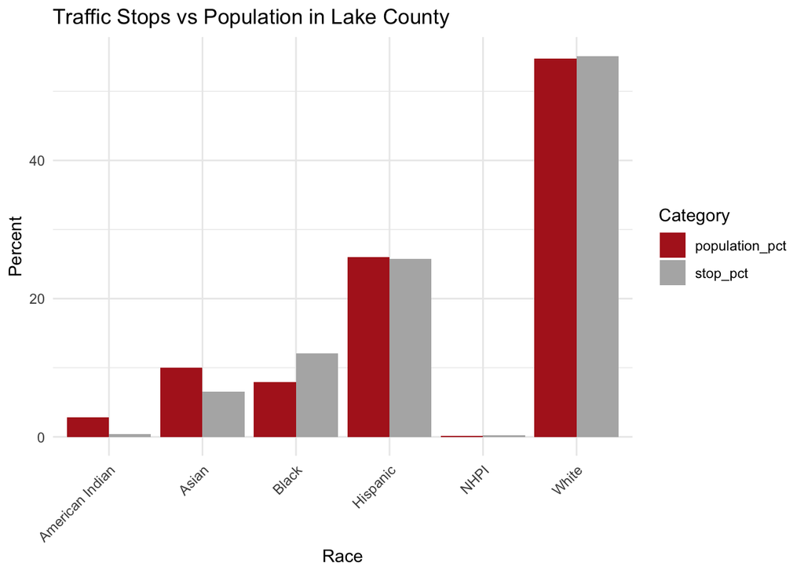

```r
## graphing it
ggplot(lake_plot, aes(x = race, y = percent, fill = type)) +
  geom_col(position = "dodge") +
  scale_fill_manual(values = c(
    "stop_pct" = "grey70",
    "population_pct" = "#B22222"
  )) +
  labs(
    title = "Traffic Stops vs Population in Lake County",
    x = "Race",
    y = "Percent",
    fill = "Category"
  ) +
  theme_minimal() +
  theme(axis.text.x = element_text(angle = 45, hjust = 1))
```

```r
### creating a new data table that has the total number of stops by race and then getting the number of searches that was conducted, creating a rate by taking searches divided by total stops and multiplying by 100 to get a percentage
lake_search_rates <- lake_law |>
  group_by(race) |>
  summarise(
    total_stops = n(),
    searches = sum(vehicle_search_conducted == "Yes", na.rm = TRUE),
    search_rate = searches/ total_stops * 100
  )


lake_search_rates
```

```
## # A tibble: 6 × 4
##   race            total_stops searches search_rate
##   <chr>                 <int>    <int>       <dbl>
## 1 American Indian         479        2       0.418
## 2 Asian                  7780       43       0.553
## 3 Black                 14368      747       5.20
## 4 Hispanic              30694      915       2.98
## 5 NHPI                    266        3       1.13
## 6 White                 65772      911       1.39
```

- Black drivers experience the highest search rate (about 5.2%), which is roughly 3–4 times higher than White drivers (about 1.4%). Hispanic drivers also experience elevated search rates relative to White drivers, while Asian and American Indian drivers have the lowest search rates.
- Comparing search rates to population percentages, Black and Hispanic drivers are overrepresented in searches relative to their share of the population, while White, Asian, and American Indian drivers are underrepresented.

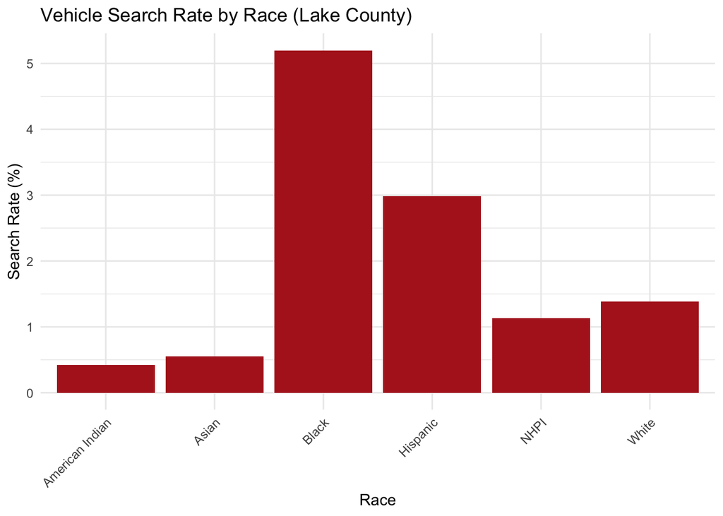

```r
ggplot(lake_search_rates, aes(x = race, y = search_rate)) +
  geom_col(fill = "#B22222") +
  labs(
    title = "Vehicle Search Rate by Race (Lake County)",
    x = "Race",
    y = "Search Rate (%)"
  ) +
  theme_minimal() +
  theme(axis.text.x = element_text(angle = 45, hjust = 1))
```

###### Top 3 Lake County Law Enforcement Agencies

- WHEELING POLICE 16608
- BUFFALO GROVE POLICE 8596
- MUNDELEIN POLICE 7460

###### Wheeling Police Department

```r
wheeling_pop <- data.frame(
  race = c("White", "Black", "Hispanic", "Asian", "American Indian", "NHPI"),
  population_pct = c(49.1, 4, 28.1, 15.9, 1.2, 0)
)
```

```r
wheeling_lake <- lake_law |>
  filter(agency_name == "WHEELING POLICE") |>
  count(race) |>
  mutate(stop_pct = n/sum(n) * 100)

wheeling_lake <- wheeling_lake |>
  left_join(wheeling_pop, by ="race")

wheeling_lake
```

```
##               race     n   stop_pct population_pct
##             <char> <int>      <num>          <num>
## 1: American Indian    76  0.4576108            1.2
## 2:           Asian  1644  9.8988439           15.9
## 3:           Black  1042  6.2740848            4.0
## 4:        Hispanic  2924 17.6059730           28.1
## 5:            NHPI    78  0.4696532            0.0
## 6:           White 10844 65.2938343           49.1
```

```r
## graphing it
wheeling_lake_plot <- wheeling_lake %>%
  select(race, stop_pct, population_pct) %>%
  pivot_longer(
    cols = c(stop_pct, population_pct),
    names_to = "type",
    values_to = "percent"
  )
```

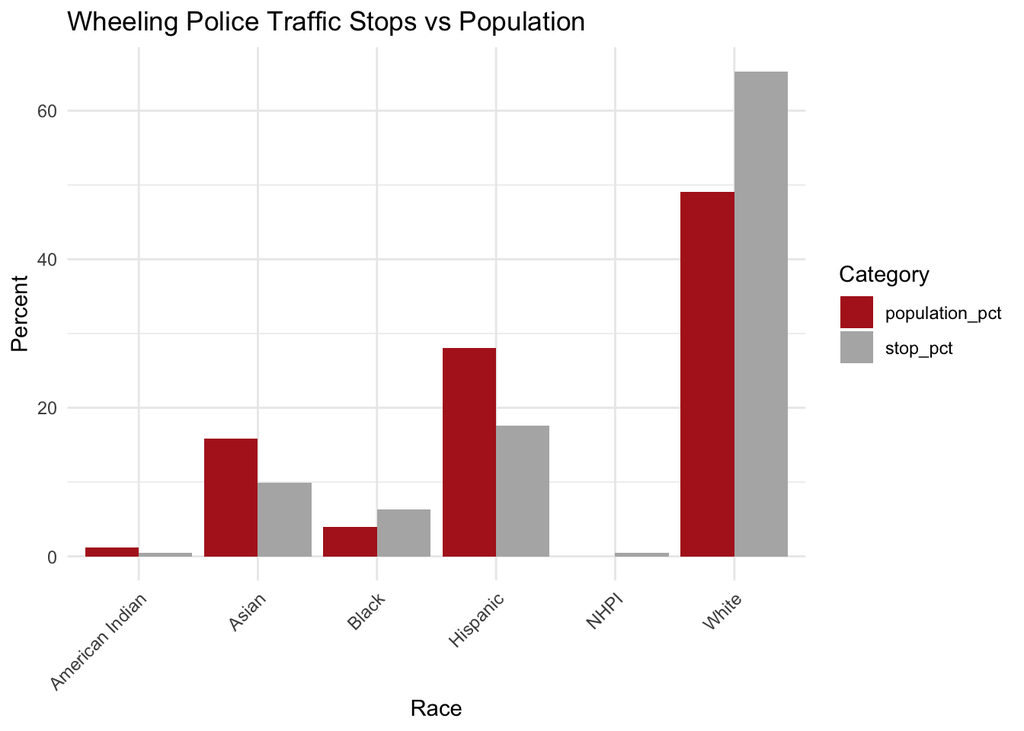

```r
## graphing it
ggplot(wheeling_lake_plot, aes(x = race, y = percent, fill = type)) +
  geom_col(position = "dodge") +
  scale_fill_manual(values = c(
    "stop_pct" = "grey70",
    "population_pct" = "#B22222"
  )) +
  labs(
    title = "Wheeling Police Traffic Stops vs Population",
    x = "Race",
    y = "Percent",
    fill = "Category"
  ) +
  theme_minimal() +
  theme(axis.text.x = element_text(angle = 45, hjust = 1))
```

- White drivers accounted for the largest share of traffic stops (65.3%), followed by Hispanic (17.6%), Asian (9.9%), and Black (6.3%) drivers; compared with the population, White and Black drivers were overrepresented in traffic stops, while Hispanic, Asian, and American Indian drivers were underrepresented.

```r
### creating a new data table that has the total number of stops by race and then getting the number of searches that was conducted, creating a rate by taking searches divided by total stops and multiplying by 100 to get a percentage
wheeling_search_rates <- lake_law |>
  filter(agency_name == "WHEELING POLICE") |>
  group_by(race) |>
  summarise(
    total_stops = n(),
    searches = sum(vehicle_search_conducted == "Yes", na.rm = TRUE),
    search_rate = searches/ total_stops * 100
  )


wheeling_search_rates
```

```
## # A tibble: 6 × 4
##   race            total_stops searches search_rate
##   <chr>                 <int>    <int>       <dbl>
## 1 American Indian          76        0       0
## 2 Asian                  1644        0       0
## 3 Black                  1042        5       0.480
## 4 Hispanic               2924       21       0.718
## 5 NHPI                     78        0       0
## 6 White                 10844       41       0.378
```

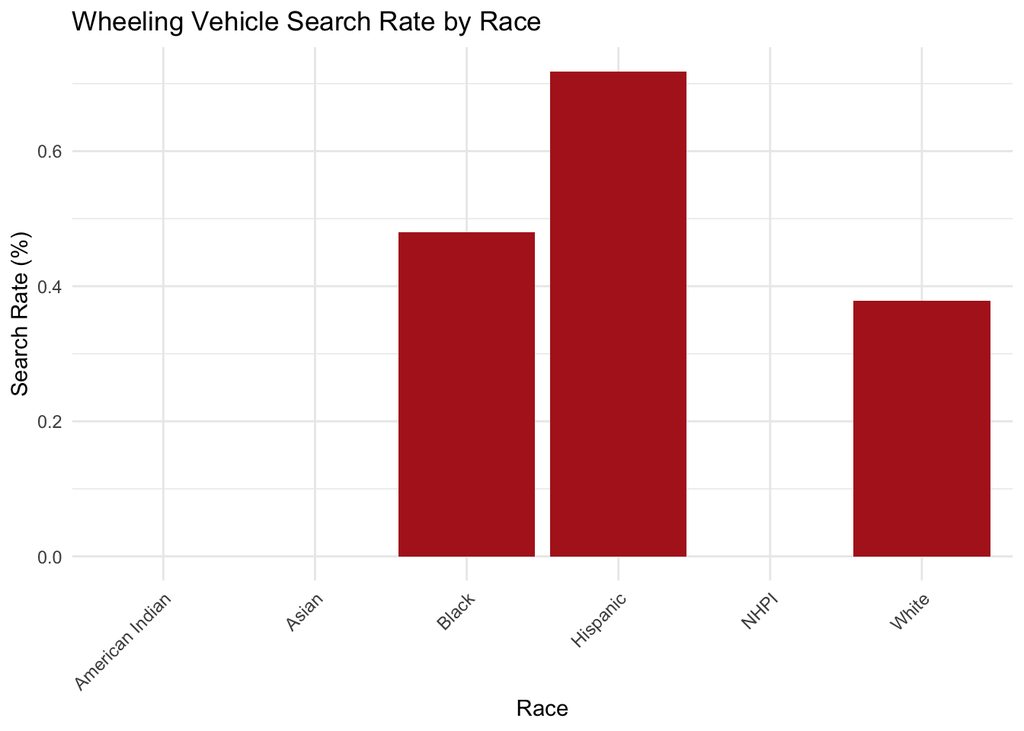

```r
ggplot(wheeling_search_rates, aes(x = race, y = search_rate)) +
  geom_col(fill = "#B22222") +
  labs(
    title = "Wheeling Vehicle Search Rate by Race",
    x = "Race",
    y = "Search Rate (%)"
  ) +
  theme_minimal() +
  theme(axis.text.x = element_text(angle = 45, hjust = 1))
```

###### Buffalo Grove Police

```r
buffalo_pop <- data.frame(
  race = c("White", "Black", "Hispanic", "Asian", "American Indian", "NHPI"),
  population_pct = c(58.2, 3.4, 5.8, 29.8, 0.5, 0.1)
)
```

```r
buffalo_lake <- lake_law |>
  filter(agency_name == "BUFFALO GROVE POLICE") |>
  count(race) |>
  mutate(stop_pct = n/sum(n) * 100)

buffalo_lake <- buffalo_lake |>
  left_join(buffalo_pop, by ="race")

buffalo_lake
```

```
##               race     n   stop_pct population_pct
##             <char> <int>      <num>          <num>
## 1: American Indian    17  0.1977664            0.5
## 2:           Asian  1199 13.9483481           29.8
## 3:           Black   606  7.0497906            3.4
## 4:        Hispanic  2064 24.0111680            5.8
## 5:            NHPI    18  0.2093997            0.1
## 6:           White  4692 54.5835272           58.2
```

- Black and Hispanic drivers are overrepresented in traffic stops relative to their share of the population, while White, Asian, and American Indian drivers are underrepresented.

```r
## graphing it
buffalo_lake_plot <- buffalo_lake %>%
  select(race, stop_pct, population_pct) %>%
  pivot_longer(
    cols = c(stop_pct, population_pct),
    names_to = "type",
    values_to = "percent"
  )
```

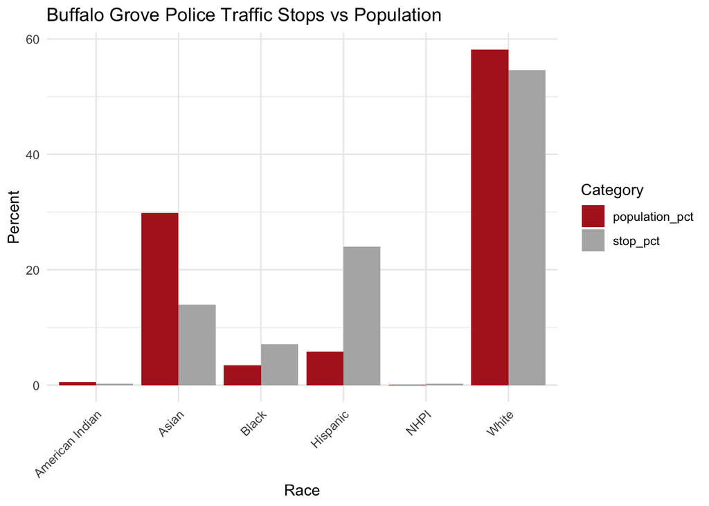

```r
## graphing it
ggplot(buffalo_lake_plot, aes(x = race, y = percent, fill = type)) +
  geom_col(position = "dodge") +
  scale_fill_manual(values = c(
    "stop_pct" = "grey70",
    "population_pct" = "#B22222"
  )) +
  labs(
    title = "Buffalo Grove Police Traffic Stops vs Population",
    x = "Race",
    y = "Percent",
    fill = "Category"
  ) +
  theme_minimal() +
  theme(axis.text.x = element_text(angle = 45, hjust = 1))
```

```r
### creating a new data table that has the total number of stops by race and then getting the number of searches that was conducted, creating a rate by taking searches divided by total stops and multiplying by 100 to get a percentage
buffalo_search_rates <- lake_law |>
  filter(agency_name == "BUFFALO GROVE POLICE") |>
  group_by(race) |>
  summarise(
    total_stops = n(),
    searches = sum(vehicle_search_conducted == "Yes", na.rm = TRUE),
    search_rate = searches/ total_stops * 100
  )


buffalo_search_rates
```

```
## # A tibble: 6 × 4
##   race            total_stops searches search_rate
##   <chr>                 <int>    <int>       <dbl>
## 1 American Indian          17        0       0
## 2 Asian                  1199        2       0.167
## 3 Black                   606        9       1.49
## 4 Hispanic               2064       24       1.16
## 5 NHPI                     18        0       0
## 6 White                  4692       12       0.256
```

- Black drivers have the highest search rate (1.5) followed by Hispanic drivers (1.2).

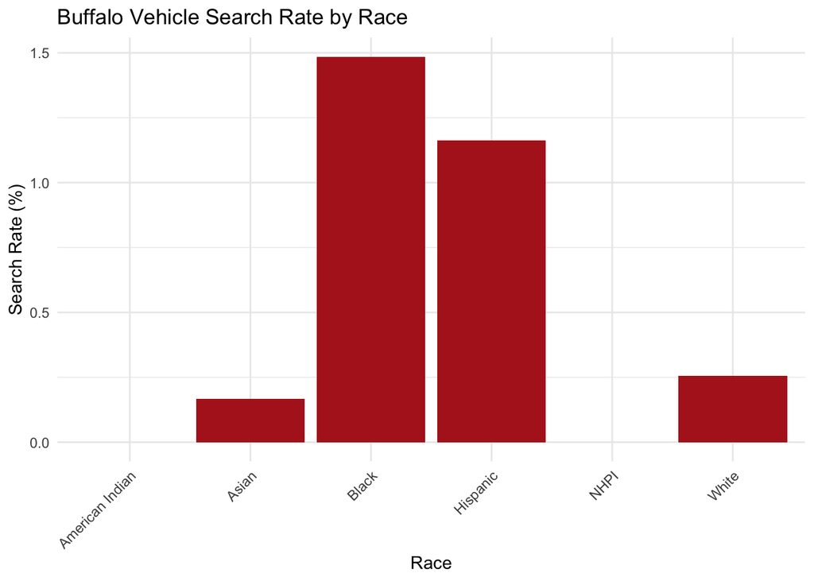

```r
ggplot(buffalo_search_rates, aes(x = race, y = search_rate)) +
  geom_col(fill = "#B22222") +
  labs(
    title = "Buffalo Vehicle Search Rate by Race",
    x = "Race",
    y = "Search Rate (%)"
  ) +
  theme_minimal() +
  theme(axis.text.x = element_text(angle = 45, hjust = 1))
```

###### Mundelein Police

```r
mundelein_pop <- data.frame(
  race = c("White", "Black", "Hispanic", "Asian", "American Indian", "NHPI"),
  population_pct = c(48.5, 3.1, 34.6, 10.1, 2.0, 0.2)
)
```

```r
mundelein_lake <- lake_law |>
  filter(agency_name == "MUNDELEIN POLICE") |>
  count(race) |>
  mutate(stop_pct = n/sum(n) * 100)

mundelein_lake <- mundelein_lake |>
  left_join(mundelein_pop, by ="race")

mundelein_lake
```

```
##               race     n    stop_pct population_pct
##             <char> <int>       <num>          <num>
## 1: American Indian    11  0.14745308            2.0
## 2:           Asian   449  6.01876676           10.1
## 3:           Black   627  8.40482574            3.1
## 4:        Hispanic  2869 38.45844504           34.6
## 5:            NHPI     3  0.04021448            0.2
## 6:           White  3501 46.93029491           48.5
```

- Black and Hispanic drivers are overrepresented in traffic stops relative to their share of the population, while White, Asian, and American Indian drivers are underrepresented.

```r
## graphing it
mundelein_lake_plot <- mundelein_lake %>%
  select(race, stop_pct, population_pct) %>%
  pivot_longer(
    cols = c(stop_pct, population_pct),
    names_to = "type",
    values_to = "percent"
  )
```

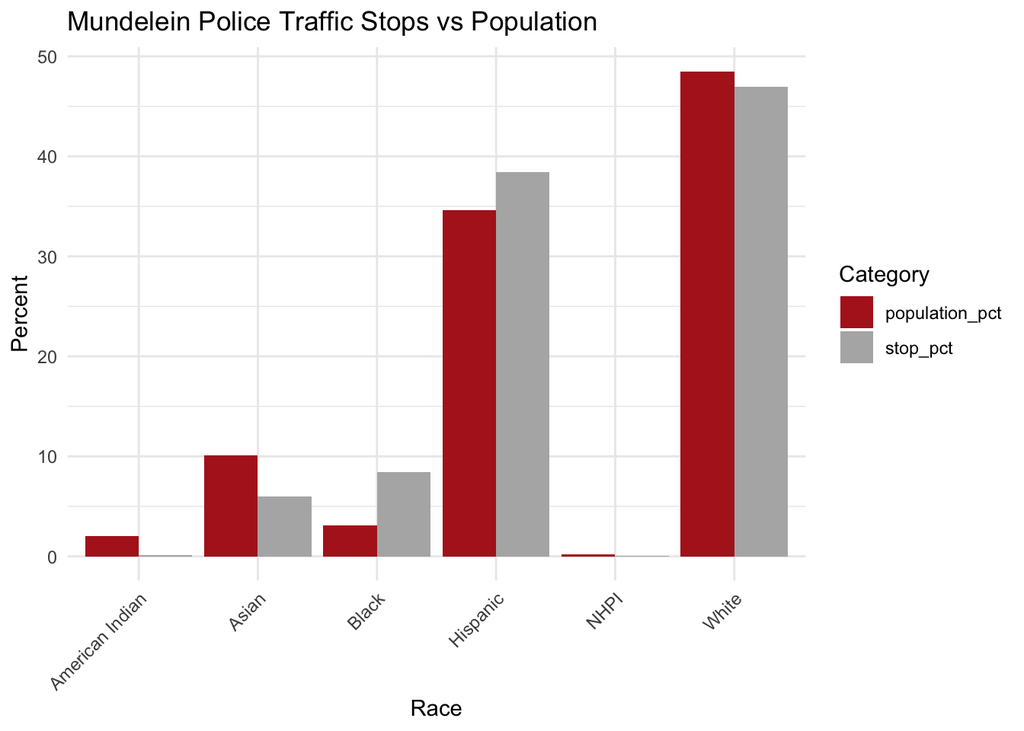

```r
## graphing it
ggplot(mundelein_lake_plot, aes(x = race, y = percent, fill = type)) +
  geom_col(position = "dodge") +
  scale_fill_manual(values = c(
    "stop_pct" = "grey70",
    "population_pct" = "#B22222"
  )) +
  labs(
    title = "Mundelein Police Traffic Stops vs Population",
    x = "Race",
    y = "Percent",
    fill = "Category"
  ) +
  theme_minimal() +
  theme(axis.text.x = element_text(angle = 45, hjust = 1))
```

```r
### creating a new data table that has the total number of stops by race and then getting the number of searches that was conducted, creating a rate by taking searches divided by total stops and multiplying by 100 to get a percentage
mundelein_search_rates <- lake_law |>
  filter(agency_name == "MUNDELEIN POLICE") |>
  group_by(race) |>
  summarise(
    total_stops = n(),
    searches = sum(vehicle_search_conducted == "Yes", na.rm = TRUE),
    search_rate = searches/ total_stops * 100
  )


mundelein_search_rates
```

```
## # A tibble: 6 × 4
##   race            total_stops searches search_rate
##   <chr>                 <int>    <int>       <dbl>
## 1 American Indian          11        0       0
## 2 Asian                   449        4       0.891
## 3 Black                   627       58       9.25
## 4 Hispanic               2869      186       6.48
## 5 NHPI                      3        0       0
## 6 White                  3501       76       2.17
```

- Black drivers have the highest search rate (9.3), followed by Hispanic drivers (6.5), and then white drivers (2.2). Despite this, white drivers (3501) have the most amount of stops, followed by Hispanic (2869), and then Black (627).

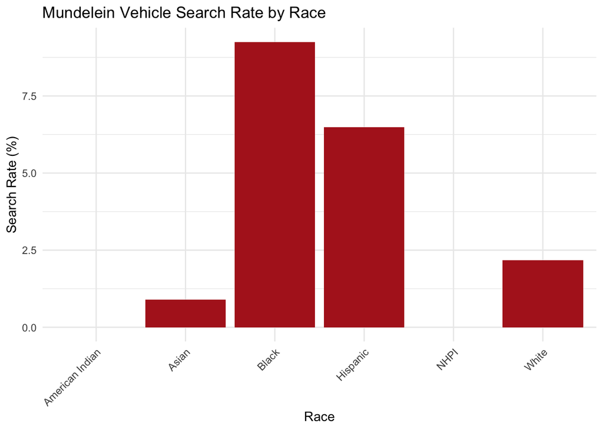

```r
ggplot(mundelein_search_rates, aes(x = race, y = search_rate)) +
  geom_col(fill = "#B22222") +
  labs(
    title = "Mundelein Vehicle Search Rate by Race",
    x = "Race",
    y = "Search Rate (%)"
  ) +
  theme_minimal() +
  theme(axis.text.x = element_text(angle = 45, hjust = 1))
```

###### Gurnee Police

```r
gurnee_pop <- data.frame(
  race = c("White", "Black", "Hispanic", "Asian", "American Indian", "NHPI"),
  population_pct = c(58.2, 7.8, 17, 13.4, 1.1, 0)
)
```

```r
gurnee_lake <- lake_law |>
  filter(agency_name == "GURNEE POLICE") |>
  count(race) |>
  mutate(stop_pct = n/sum(n) * 100)

gurnee_lake <- gurnee_lake |>
  left_join(gurnee_pop, by ="race")

gurnee_lake
```

```
##               race     n   stop_pct population_pct
##             <char> <int>      <num>          <num>
## 1: American Indian    21  0.3000000            1.1
## 2:           Asian   324  4.6285714           13.4
## 3:           Black  1755 25.0714286            7.8
## 4:        Hispanic  2721 38.8714286           17.0
## 5:            NHPI    10  0.1428571            0.0
## 6:           White  2169 30.9857143           58.2
```

```r
gurnee_search_rates <- lake_law |>
  filter(agency_name == "GURNEE POLICE") |>
  group_by(race) |>
  summarise(
    total_stops = n(),
    searches = sum(vehicle_search_conducted == "Yes", na.rm = TRUE),
    search_rate = searches/ total_stops * 100
  )


gurnee_search_rates
```

```
## # A tibble: 6 × 4
##   race            total_stops searches search_rate
##   <chr>                 <int>    <int>       <dbl>
## 1 American Indian          21        0        0
## 2 Asian                   324        4        1.23
## 3 Black                  1755       86        4.90
## 4 Hispanic               2721      111        4.08
## 5 NHPI                     10        0        0
## 6 White                  2169       48        2.21
```

###### Libertyville Police

```r
libertyville_pop <- data.frame(
  race = c("White", "Black", "Hispanic", "Asian", "American Indian", "NHPI"),
  population_pct = c(80.7, 1.1, 8.7, 4.7, 0.5, 0.3)
)
```

```r
libertyville_lake <- lake_law |>
  filter(agency_name == "LIBERTYVILLE POLICE") |>
  count(race) |>
  mutate(stop_pct = n/sum(n) * 100)

libertyville_lake <- libertyville_lake |>
  left_join(libertyville_pop, by ="race")

libertyville_lake
```

```
##               race     n   stop_pct population_pct
##             <char> <int>      <num>          <num>
## 1: American Indian     7  0.1044932            0.5
## 2:           Asian   533  7.9564114            4.7
## 3:           Black   692 10.3299000            1.1
## 4:        Hispanic  1822 27.1980893            8.7
## 5:            NHPI     3  0.0447828            0.3
## 6:           White  3642 54.3663233           80.7
```

```r
libertyville_search_rates <- lake_law |>
  filter(agency_name == "LIBERTYVILLE POLICE") |>
  group_by(race) |>
  summarise(
    total_stops = n(),
    searches = sum(vehicle_search_conducted == "Yes", na.rm = TRUE),
    search_rate = searches/ total_stops * 100
  )


libertyville_search_rates
```

```
## # A tibble: 6 × 4
##   race            total_stops searches search_rate
##   <chr>                 <int>    <int>       <dbl>
## 1 American Indian           7        0           0
## 2 Asian                   533        0           0
## 3 Black                   692        0           0
## 4 Hispanic               1822        0           0
## 5 NHPI                      3        0           0
## 6 White                  3642        0           0
```

###### Zion Police

```r
zion_pop <- data.frame(
  race = c("White", "Black", "Hispanic", "Asian", "American Indian", "NHPI"),
  population_pct = c(24.5, 25.1, 43.7, 3, 2.2, 0)
)
```

```r
zion_lake <- lake_law |>
  filter(agency_name == "ZION POLICE") |>
  count(race) |>
  mutate(stop_pct = n/sum(n) * 100)

zion_lake <- gurnee_lake |>
  left_join(zion_pop, by ="race")

zion_lake
```

```
##               race     n   stop_pct population_pct.x population_pct.y
##             <char> <int>      <num>            <num>            <num>
## 1: American Indian    21  0.3000000              1.1              2.2
## 2:           Asian   324  4.6285714             13.4              3.0
## 3:           Black  1755 25.0714286              7.8             25.1
## 4:        Hispanic  2721 38.8714286             17.0             43.7
## 5:            NHPI    10  0.1428571              0.0              0.0
## 6:           White  2169 30.9857143             58.2             24.5
```

```r
zion_search_rates <- lake_law |>
  filter(agency_name == "ZION POLICE") |>
  group_by(race) |>
  summarise(
    total_stops = n(),
    searches = sum(vehicle_search_conducted == "Yes", na.rm = TRUE),
    search_rate = searches/ total_stops * 100
  )


zion_search_rates
```

```
## # A tibble: 6 × 4
##   race            total_stops searches search_rate
##   <chr>                 <int>    <int>       <dbl>
## 1 American Indian          27        0        0
## 2 Asian                    54        1        1.85
## 3 Black                  2112      183        8.66
## 4 Hispanic               2486       93        3.74
## 5 NHPI                      4        0        0
## 6 White                  1216       34        2.80
```

###### Waukegan Police

```r
waukegan_pop <- data.frame(
  race = c("White", "Black", "Hispanic", "Asian", "American Indian", "NHPI"),
  population_pct = c(16.7, 17.3, 57.9, 5.5, 2.1, 0.1)
)
```

```r
waukegan_lake <- lake_law |>
  filter(agency_name == "WAUKEGAN POLICE") |>
  count(race) |>
  mutate(stop_pct = n/sum(n) * 100)

waukegan_lake <- waukegan_lake |>
  left_join(waukegan_pop, by ="race")

waukegan_lake
```

```
##               race     n   stop_pct population_pct
##             <char> <int>      <num>          <num>
## 1: American Indian    25  0.4632203            2.1
## 2:           Asian    85  1.5749490            5.5
## 3:           Black  1479 27.4041134           17.3
## 4:        Hispanic  3166 58.6622198           57.9
## 5:            NHPI    29  0.5373356            0.1
## 6:           White   613 11.3581619           16.7
```

```r
waukegan_search_rates <- lake_law |>
  filter(agency_name == "WAUKEGAN POLICE") |>
  group_by(race) |>
  summarise(
    total_stops = n(),
    searches = sum(vehicle_search_conducted == "Yes", na.rm = TRUE),
    search_rate = searches/ total_stops * 100
  )


waukegan_search_rates
```

```
## # A tibble: 6 × 4
##   race            total_stops searches search_rate
##   <chr>                 <int>    <int>       <dbl>
## 1 American Indian          25        0       0
## 2 Asian                    85        0       0
## 3 Black                  1479        6       0.406
## 4 Hispanic               3166       15       0.474
## 5 NHPI                     29        0       0
## 6 White                   613        0       0
```

###### Lincolnshire Police

```r
lincolnshire_pop <- data.frame(
  race = c("White", "Black", "Hispanic", "Asian", "American Indian", "NHPI"),
  population_pct = c(69.3, 1.4, 1.6, 24, 0, 0)
)
```

```r
lincolnshire_lake <- lake_law |>
  filter(agency_name == "LINCOLNSHIRE POLICE") |>
  count(race) |>
  mutate(stop_pct = n/sum(n) * 100)

gurnee_lake <- gurnee_lake |>
  left_join(lincolnshire_pop, by ="race")

lincolnshire_lake
```

```
##               race     n   stop_pct
##             <char> <int>      <num>
## 1: American Indian    10  0.2002804
## 2:           Asian   776 15.5417585
## 3:           Black   457  9.1528139
## 4:        Hispanic  1029 20.6088524
## 5:            NHPI    21  0.4205888
## 6:           White  2700 54.0757060
```

```r
lincolnshire_search_rates <- lake_law |>
  filter(agency_name == "LINCOLNSHIRE POLICE") |>
  group_by(race) |>
  summarise(
    total_stops = n(),
    searches = sum(vehicle_search_conducted == "Yes", na.rm = TRUE),
    search_rate = searches/ total_stops * 100
  )


lincolnshire_search_rates
```

```
## # A tibble: 6 × 4
##   race            total_stops searches search_rate
##   <chr>                 <int>    <int>       <dbl>
## 1 American Indian          10        0       0
## 2 Asian                   776        4       0.515
## 3 Black                   457       12       2.63
## 4 Hispanic               1029       26       2.53
## 5 NHPI                     21        0       0
## 6 White                  2700       18       0.667
```

###### Deerfield Police

```r
deerfield_pop <- data.frame(
  race = c("White", "Black", "Hispanic", "Asian", "American Indian", "NHPI"),
  population_pct = c(86.1, 0.2, 5.4, 5.6, 0, 0)
)
```

```r
deerfield_lake <- lake_law |>
  filter(agency_name == "DEERFIELD POLICE") |>
  count(race) |>
  mutate(stop_pct = n/sum(n) * 100)

deerfield_lake <- deerfield_lake |>
  left_join(deerfield_pop, by ="race")

deerfield_lake
```

```
##               race     n    stop_pct population_pct
##             <char> <int>       <num>          <num>
## 1: American Indian     4  0.09212345            0.0
## 2:           Asian   343  7.89958544            5.6
## 3:           Black   285  6.56379549            0.2
## 4:        Hispanic   622 14.32519576            5.4
## 5:            NHPI     5  0.11515431            0.0
## 6:           White  3083 71.00414556           86.1
```

```r
deerfield_search_rates <- lake_law |>
  filter(agency_name == "DEERFIELD POLICE") |>
  group_by(race) |>
  summarise(
    total_stops = n(),
    searches = sum(vehicle_search_conducted == "Yes", na.rm = TRUE),
    search_rate = searches/ total_stops * 100
  )


deerfield_search_rates
```

```
## # A tibble: 6 × 4
##   race            total_stops searches search_rate
##   <chr>                 <int>    <int>       <dbl>
## 1 American Indian           4        0       0
## 2 Asian                   343        0       0
## 3 Black                   285        1       0.351
## 4 Hispanic                622        2       0.322
## 5 NHPI                      5        0       0
## 6 White                  3083       13       0.422
```

###### Round Lake Park Police

```r
roundlakepark_pop <- data.frame(
  race = c("White", "Black", "Hispanic", "Asian", "American Indian", "NHPI"),
  population_pct = c(43.9, 0.8, 49.5, 0.8, 2.9, 0)
)
```

```r
roundlakepark_lake <- lake_law |>
  filter(agency_name == "ROUND LAKE PARK POLICE") |>
  count(race) |>
  mutate(stop_pct = n/sum(n) * 100)

roundlakepark_lake <- roundlakepark_lake |>
  left_join(gurnee_pop, by ="race")

roundlakepark_lake
```

```
##               race     n   stop_pct population_pct
##             <char> <int>      <num>          <num>
## 1: American Indian    19  0.4884319            1.1
## 2:           Asian    63  1.6195373           13.4
## 3:           Black   534 13.7275064            7.8
## 4:        Hispanic  1647 42.3393316           17.0
## 5:            NHPI     9  0.2313625            0.0
## 6:           White  1618 41.5938303           58.2
```

```r
roundlakepark_search_rates <- lake_law |>
  filter(agency_name == "ROUND LAKE PARK POLICE") |>
  group_by(race) |>
  summarise(
    total_stops = n(),
    searches = sum(vehicle_search_conducted == "Yes", na.rm = TRUE),
    search_rate = searches/ total_stops * 100
  )

roundlakepark_search_rates
```

```
## # A tibble: 6 × 4
##   race            total_stops searches search_rate
##   <chr>                 <int>    <int>       <dbl>
## 1 American Indian          19        1        5.26
## 2 Asian                    63        4        6.35
## 3 Black                   534       58       10.9
## 4 Hispanic               1647      132        8.01
## 5 NHPI                      9        1       11.1
## 6 White                  1618      146        9.02
```

###### Round Lake Beach Police

```r
roundlakebeach_pop <- data.frame(
  race = c("White", "Black", "Hispanic", "Asian", "American Indian", "NHPI"),
  population_pct = c(34.5, 4.2, 56.1, 2.2, 0.9, 0.1)
)
```

```r
roundlakebeach_lake <- lake_law |>
  filter(agency_name == "ROUND LAKE BEACH POLICE") |>
  count(race) |>
  mutate(stop_pct = n/sum(n) * 100)

roundlakebeach_lake <- roundlakebeach_lake |>
  left_join(gurnee_pop, by ="race")

roundlakebeach_lake
```

```
##               race     n   stop_pct population_pct
##             <char> <int>      <num>          <num>
## 1: American Indian    11  0.3127666            1.1
## 2:           Asian    82  2.3315326           13.4
## 3:           Black   352 10.0085300            7.8
## 4:        Hispanic   345  9.8094967           17.0
## 5:            NHPI     4  0.1137333            0.0
## 6:           White  2723 77.4239409           58.2
```

```r
roundlakebeach_search_rates <- lake_law |>
  filter(agency_name == "ROUND LAKE BEACH POLICE") |>
  group_by(race) |>
  summarise(
    total_stops = n(),
    searches = sum(vehicle_search_conducted == "Yes", na.rm = TRUE),
    search_rate = searches/ total_stops * 100
  )


roundlakebeach_search_rates
```

```
## # A tibble: 6 × 4
##   race            total_stops searches search_rate
##   <chr>                 <int>    <int>       <dbl>
## 1 American Indian          11        1        9.09
## 2 Asian                    82        1        1.22
## 3 Black                   352       19        5.40
## 4 Hispanic                345       10        2.90
## 5 NHPI                      4        0        0
## 6 White                  2723       63        2.31
```

###### Barrington Police

```r
barrington_pop <- data.frame(
  race = c("White", "Black", "Hispanic", "Asian", "American Indian", "NHPI"),
  population_pct = c(81.8, 1.3, 4.1, 7.9, 0, 0)
)
```

```r
barrington_lake <- lake_law |>
  filter(agency_name == "BARRINGTON POLICE") |>
  count(race) |>
  mutate(stop_pct = n/sum(n) * 100)

barrington_lake <- barrington_lake |>
  left_join(gurnee_pop, by ="race")

barrington_lake
```

```
##               race     n   stop_pct population_pct
##             <char> <int>      <num>          <num>
## 1: American Indian    18  0.5462822            1.1
## 2:           Asian   139  4.2185129           13.4
## 3:           Black   158  4.7951442            7.8
## 4:        Hispanic   456 13.8391502           17.0
## 5:            NHPI    11  0.3338392            0.0
## 6:           White  2513 76.2670713           58.2
```

```r
barrington_search_rates <- lake_law |>
  filter(agency_name == "BARRINGTON POLICE") |>
  group_by(race) |>
  summarise(
    total_stops = n(),
    searches = sum(vehicle_search_conducted == "Yes", na.rm = TRUE),
    search_rate = searches/ total_stops * 100
  )


barrington_search_rates
```

```
## # A tibble: 6 × 4
##   race            total_stops searches search_rate
##   <chr>                 <int>    <int>       <dbl>
## 1 American Indian          18        0       0
## 2 Asian                   139        0       0
## 3 Black                   158        1       0.633
## 4 Hispanic                456        1       0.219
## 5 NHPI                     11        0       0
## 6 White                  2513        4       0.159
```

###### Lake Zurich Police

```r
lakezurich_pop <- data.frame(
  race = c("White", "Black", "Hispanic", "Asian", "American Indian", "NHPI"),
  population_pct = c(80.6, 1.0, 6.7, 8.4, 0, 0.1)
)
```

```r
lakezurich_lake <- lake_law |>
  filter(agency_name == "LAKE ZURICH POLICE") |>
  count(race) |>
  mutate(stop_pct = n/sum(n) * 100)

lakezurich_lake <- lakezurich_lake |>
  left_join(lakezurich_pop, by ="race")

lakezurich_lake
```

```
##               race     n   stop_pct population_pct
##             <char> <int>      <num>          <num>
## 1: American Indian    27  0.8204193            0.0
## 2:           Asian   210  6.3810392            8.4
## 3:           Black   161  4.8921301            1.0
## 4:        Hispanic   257  7.8091765            6.7
## 5:            NHPI     4  0.1215436            0.1
## 6:           White  2632 79.9756913           80.6
```

```r
lakezurich_search_rates <- lake_law |>
  filter(agency_name == "LAKE ZURICH POLICE") |>
  group_by(race) |>
  summarise(
    total_stops = n(),
    searches = sum(vehicle_search_conducted == "Yes", na.rm = TRUE),
    search_rate = searches/ total_stops * 100
  )


lakezurich_search_rates
```

```
## # A tibble: 6 × 4
##   race            total_stops searches search_rate
##   <chr>                 <int>    <int>       <dbl>
## 1 American Indian          27        0       0
## 2 Asian                   210        2       0.952
## 3 Black                   161       11       6.83
## 4 Hispanic                257        9       3.50
## 5 NHPI                      4        0       0
## 6 White                  2632       38       1.44
```

###### Fox Lake Police

```r
foxlake_pop <- data.frame(
  race = c("White", "Black", "Hispanic", "Asian", "American Indian", "NHPI"),
  population_pct = c(74.7, 3.8, 18, 1.9, 0.4, 0.1)
)
```

```r
foxlake_lake <- lake_law |>
  filter(agency_name == "FOX LAKE POLICE") |>
  count(race) |>
  mutate(stop_pct = n/sum(n) * 100)

foxlake_lake <- foxlake_lake |>
  left_join(foxlake_pop, by ="race")

foxlake_lake
```

```
##        race     n  stop_pct population_pct
##      <char> <int>     <num>          <num>
## 1:    Asian    72  2.233251            1.9
## 2:    Black   243  7.537221            3.8
## 3: Hispanic   628 19.478908           18.0
## 4:    White  2281 70.750620           74.7
```

```r
foxlake_search_rates <- lake_law |>
  filter(agency_name == "FOX LAKE POLICE") |>
  group_by(race) |>
  summarise(
    total_stops = n(),
    searches = sum(vehicle_search_conducted == "Yes", na.rm = TRUE),
    search_rate = searches/ total_stops * 100
  )

foxlake_search_rates
```

```
## # A tibble: 4 × 4
##   race     total_stops searches search_rate
##   <chr>          <int>    <int>       <dbl>
## 1 Asian             72        2        2.78
## 2 Black            243       25       10.3
## 3 Hispanic         628       29        4.62
## 4 White           2281       85        3.73
```

###### Cary Police

```r
cary_pop <- data.frame(
  race = c("White", "Black", "Hispanic", "Asian", "American Indian", "NHPI"),
  population_pct = c(79.2, 1.1, 12.9, 1.7, 0.2, 0.1)
)
```

```r
cary_lake <- lake_law |>
  filter(agency_name == "CARY POLICE") |>
  count(race) |>
  mutate(stop_pct = n/sum(n) * 100)

cary_lake <- cary_lake |>
  left_join(cary_pop, by ="race")

cary_lake
```

```
##               race     n    stop_pct population_pct
##             <char> <int>       <num>          <num>
## 1: American Indian     1  0.03202049            0.2
## 2:           Asian   138  4.41882805            1.7
## 3:           Black   109  3.49023375            1.1
## 4:        Hispanic   505 16.17034902           12.9
## 5:           White  2370 75.88856868           79.2
```

```r
cary_search_rates <- lake_law |>
  filter(agency_name == "CARY POLICE") |>
  group_by(race) |>
  summarise(
    total_stops = n(),
    searches = sum(vehicle_search_conducted == "Yes", na.rm = TRUE),
    search_rate = searches/ total_stops * 100
  )


cary_search_rates
```

```
## # A tibble: 5 × 4
##   race            total_stops searches search_rate
##   <chr>                 <int>    <int>       <dbl>
## 1 American Indian           1        0       0
## 2 Asian                   138        0       0
## 3 Black                   109        1       0.917
## 4 Hispanic                505        6       1.19
## 5 White                  2370       11       0.464
```

###### Lake Forest Police

```r
lakeforest_pop <- data.frame(
  race = c("White", "Black", "Hispanic", "Asian", "American Indian", "NHPI"),
  population_pct = c(80.2, 1.0, 6.1, 6.5, 0.3, 0)
)
```

```r
lakeforest_lake <- lake_law |>
  filter(agency_name == "LAKE FOREST POLICE") |>
  count(race) |>
  mutate(stop_pct = n/sum(n) * 100)

lakeforest_lake <- lakeforest_lake |>
  left_join(lakeforest_pop, by ="race")

lakeforest_lake
```

```
##        race     n  stop_pct population_pct
##      <char> <int>     <num>          <num>
## 1:    Asian   231  8.369565            6.5
## 2:    Black   333 12.065217            1.0
## 3: Hispanic   628 22.753623            6.1
## 4:    White  1568 56.811594           80.2
```

```r
lakeforest_search_rates <- lake_law |>
  filter(agency_name == "LAKE FOREST POLICE") |>
  group_by(race) |>
  summarise(
    total_stops = n(),
    searches = sum(vehicle_search_conducted == "Yes", na.rm = TRUE),
    search_rate = searches/ total_stops * 100
  )


lakeforest_search_rates
```

```
## # A tibble: 4 × 4
##   race     total_stops searches search_rate
##   <chr>          <int>    <int>       <dbl>
## 1 Asian            231        6       2.60
## 2 Black            333       42      12.6
## 3 Hispanic         628       36       5.73
## 4 White           1568       13       0.829
```

###### Highland Park

```r
highland_pop <- data.frame(
  race = c("White", "Black", "Hispanic", "Asian", "American Indian", "NHPI"),
  population_pct = c(80.8, 2.0, 11, 2.8, 0.6, 0)
)
```

```r
highland_lake <- lake_law |>
  filter(agency_name == "HIGHLAND PARK POLICE") |>
  count(race) |>
  mutate(stop_pct = n/sum(n) * 100)

highland_lake <- highland_lake |>
  left_join(highland_pop, by ="race")

highland_lake
```

```
##               race     n   stop_pct population_pct
##             <char> <int>      <num>          <num>
## 1: American Indian     5  0.1886792            0.6
## 2:           Asian   172  6.4905660            2.8
## 3:           Black   415 15.6603774            2.0
## 4:        Hispanic   599 22.6037736           11.0
## 5:            NHPI     7  0.2641509            0.0
## 6:           White  1452 54.7924528           80.8
```

```r
highland_search_rates <- lake_law |>
  filter(agency_name == "HIGHLAND PARK POLICE") |>
  group_by(race) |>
  summarise(
    total_stops = n(),
    searches = sum(vehicle_search_conducted == "Yes", na.rm = TRUE),
    search_rate = searches/ total_stops * 100
  )


highland_search_rates
```

```
## # A tibble: 6 × 4
##   race            total_stops searches search_rate
##   <chr>                 <int>    <int>       <dbl>
## 1 American Indian           5        0       0
## 2 Asian                   172        1       0.581
## 3 Black                   415       30       7.23
## 4 Hispanic                599       38       6.34
## 5 NHPI                      7        1      14.3
## 6 White                  1452       13       0.895
```

###### Hawthorn Woods Police

```r
hawthorn_pop <- data.frame(
  race = c("White", "Black", "Hispanic", "Asian", "American Indian", "NHPI"),
  population_pct = c(76.5, 1.3, 2.3, 16, 0, 0)
)
```

```r
hawthorn_lake <- lake_law |>
  filter(agency_name == "HAWTHORN WOODS POLICE") |>
  count(race) |>
  mutate(stop_pct = n/sum(n) * 100)

hawthorn_lake <- hawthorn_lake |>
  left_join(gurnee_pop, by ="race")

hawthorn_lake
```

```
##               race     n    stop_pct population_pct
##             <char> <int>       <num>          <num>
## 1: American Indian    57  2.32843137            1.1
## 2:           Asian   148  6.04575163           13.4
## 3:           Black   161  6.57679739            7.8
## 4:        Hispanic   255 10.41666667           17.0
## 5:            NHPI     1  0.04084967            0.0
## 6:           White  1826 74.59150327           58.2
```

```r
hawthorn_search_rates <- lake_law |>
  filter(agency_name == "HAWTHORN WOODS POLICE") |>
  group_by(race) |>
  summarise(
    total_stops = n(),
    searches = sum(vehicle_search_conducted == "Yes", na.rm = TRUE),
    search_rate = searches/ total_stops * 100
  )


hawthorn_search_rates
```

```
## # A tibble: 6 × 4
##   race            total_stops searches search_rate
##   <chr>                 <int>    <int>       <dbl>
## 1 American Indian          57        0        0
## 2 Asian                   148        2        1.35
## 3 Black                   161       14        8.70
## 4 Hispanic                255        9        3.53
## 5 NHPI                      1        0        0
## 6 White                  1826       38        2.08
```

###### Antioch Police

```r
antioch_pop <- data.frame(
  race = c("White", "Black", "Hispanic", "Asian", "American Indian", "NHPI"),
  population_pct = c(76.6, 4.9, 10.5, 3.9, 0.5, 10.5)
)
```

```r
antioch_lake <- lake_law |>
  filter(agency_name == "ANTIOCH POLICE") |>
  count(race) |>
  mutate(stop_pct = n/sum(n) * 100)

antioch_lake <- antioch_lake |>
  left_join(antioch_pop, by ="race")

antioch_lake
```

```
##               race     n   stop_pct population_pct
##             <char> <int>      <num>          <num>
## 1: American Indian     5  0.2089427            0.5
## 2:           Asian    39  1.6297534            3.9
## 3:           Black   183  7.6473046            4.9
## 4:        Hispanic   391 16.3393230           10.5
## 5:            NHPI    11  0.4596740           10.5
## 6:           White  1764 73.7150021           76.6
```

```r
antioch_search_rates <- lake_law |>
  filter(agency_name == "ANTIOCH POLICE") |>
  group_by(race) |>
  summarise(
    total_stops = n(),
    searches = sum(vehicle_search_conducted == "Yes", na.rm = TRUE),
    search_rate = searches/ total_stops * 100
  )


antioch_search_rates
```

```
## # A tibble: 6 × 4
##   race            total_stops searches search_rate
##   <chr>                 <int>    <int>       <dbl>
## 1 American Indian           5        0      0
## 2 Asian                    39        0      0
## 3 Black                   183        0      0
## 4 Hispanic                391        0      0
## 5 NHPI                     11        0      0
## 6 White                  1764        1      0.0567
```

###### Lindenhurst Police

```r
lindenhurst_pop <- data.frame(
  race = c("White", "Black", "Hispanic", "Asian", "American Indian", "NHPI"),
  population_pct = c(72.5, 4.0, 11.2, 9, 0.6, 0)
)
```

```r
lindenhurst_lake <- lake_law |>
  filter(agency_name == "LINDENHURST POLICE") |>
  count(race) |>
  mutate(stop_pct = n/sum(n) * 100)

lindenhurst_lake <- lindenhurst_lake |>
  left_join(lindenhurst_pop, by ="race")

lindenhurst_lake
```

```
##               race     n   stop_pct population_pct
##             <char> <int>      <num>          <num>
## 1: American Indian    28  1.2785388            0.6
## 2:           Asian   111  5.0684932            9.0
## 3:           Black   260 11.8721461            4.0
## 4:        Hispanic   514 23.4703196           11.2
## 5:            NHPI     4  0.1826484            0.0
## 6:           White  1273 58.1278539           72.5
```

```r
lindenhurst_search_rates <- lake_law |>
  filter(agency_name == "LINDENHURST POLICE") |>
  group_by(race) |>
  summarise(
    total_stops = n(),
    searches = sum(vehicle_search_conducted == "Yes", na.rm = TRUE),
    search_rate = searches/ total_stops * 100
  )


lindenhurst_search_rates
```

```
## # A tibble: 6 × 4
##   race            total_stops searches search_rate
##   <chr>                 <int>    <int>       <dbl>
## 1 American Indian          28        0       0
## 2 Asian                   111        1       0.901
## 3 Black                   260       12       4.62
## 4 Hispanic                514       15       2.92
## 5 NHPI                      4        0       0
## 6 White                  1273       17       1.34
```

###### Round Lake Police

```r
roundlake_pop <- data.frame(
  race = c("White", "Black", "Hispanic", "Asian", "American Indian", "NHPI"),
  population_pct = c(44.5, 4.1, 35.8, 12.3, 1.2, 0.1)
)
```

```r
roundlake_lake <- lake_law |>
  filter(agency_name == "ROUND LAKE POLICE") |>
  count(race) |>
  mutate(stop_pct = n/sum(n) * 100)

roundlake_lake <- roundlake_lake |>
  left_join(roundlake_pop, by ="race")

roundlake_lake
```

```
##               race     n   stop_pct population_pct
##             <char> <int>      <num>          <num>
## 1: American Indian     9  0.4300048            1.2
## 2:           Asian    71  3.3922599           12.3
## 3:           Black   237 11.3234591            4.1
## 4:        Hispanic   302 14.4290492           35.8
## 5:            NHPI     3  0.1433349            0.1
## 6:           White  1471 70.2818920           44.5
```

```r
roundlake_search_rates <- lake_law |>
  filter(agency_name == "ROUND LAKE POLICE") |>
  group_by(race) |>
  summarise(
    total_stops = n(),
    searches = sum(vehicle_search_conducted == "Yes", na.rm = TRUE),
    search_rate = searches/ total_stops * 100
  )

roundlake_search_rates
```

```
## # A tibble: 6 × 4
##   race            total_stops searches search_rate
##   <chr>                 <int>    <int>       <dbl>
## 1 American Indian           9        0        0
## 2 Asian                    71        0        0
## 3 Black                   237       16        6.75
## 4 Hispanic                302       21        6.95
## 5 NHPI                      3        0        0
## 6 White                  1471       54        3.67
```

###### Park City Police

```r
parkcity_pop <- data.frame(
  race = c("White", "Black", "Hispanic", "Asian", "American Indian", "NHPI"),
  population_pct = c(10.8, 6.9, 75.1, 6.3, 0.7, 0)
)
```

```r
parkcity_lake <- lake_law |>
  filter(agency_name == "PARK CITY POLICE") |>
  count(race) |>
  mutate(stop_pct = n/sum(n) * 100)

parkcity_lake <- parkcity_lake |>
  left_join(gurnee_pop, by ="race")

parkcity_lake
```

```
##               race     n   stop_pct population_pct
##             <char> <int>      <num>          <num>
## 1: American Indian    12  0.5905512            1.1
## 2:           Asian    47  2.3129921           13.4
## 3:           Black   435 21.4074803            7.8
## 4:        Hispanic   728 35.8267717           17.0
## 5:            NHPI     2  0.0984252            0.0
## 6:           White   808 39.7637795           58.2
```

```r
parkcity_search_rates <- lake_law |>
  filter(agency_name == "PARK CITY POLICE") |>
  group_by(race) |>
  summarise(
    total_stops = n(),
    searches = sum(vehicle_search_conducted == "Yes", na.rm = TRUE),
    search_rate = searches/ total_stops * 100
  )


parkcity_search_rates
```

```
## # A tibble: 6 × 4
##   race            total_stops searches search_rate
##   <chr>                 <int>    <int>       <dbl>
## 1 American Indian          12        0        0
## 2 Asian                    47        0        0
## 3 Black                   435       30        6.90
## 4 Hispanic                728       21        2.88
## 5 NHPI                      2        0        0
## 6 White                   808        9        1.11
```

###### Riverwoods Police

```r
riverwoods_pop <- data.frame(
  race = c("White", "Black", "Hispanic", "Asian", "American Indian", "NHPI"),
  population_pct = c(84.1, 1.15, 0.07, 9.57, 0, 0)
)
```

```r
riverwoods_lake <- lake_law |>
  filter(agency_name == "RIVERWOODS POLICE") |>
  count(race) |>
  mutate(stop_pct = n/sum(n) * 100)

riverwoods_lake <- riverwoods_lake |>
  left_join(riverwoods_pop, by ="race")

riverwoods_lake
```

```
##               race     n   stop_pct population_pct
##             <char> <int>      <num>          <num>
## 1: American Indian     3  0.1606856           0.00
## 2:           Asian   226 12.1049813           9.57
## 3:           Black   190 10.1767542           1.15
## 4:        Hispanic   332 17.7825388           0.07
## 5:           White  1116 59.7750402          84.10
```

```r
riverwoods_search_rates <- lake_law |>
  filter(agency_name == "RIVERWOODS POLICE") |>
  group_by(race) |>
  summarise(
    total_stops = n(),
    searches = sum(vehicle_search_conducted == "Yes", na.rm = TRUE),
    search_rate = searches/ total_stops * 100
  )


riverwoods_search_rates
```

```
## # A tibble: 5 × 4
##   race            total_stops searches search_rate
##   <chr>                 <int>    <int>       <dbl>
## 1 American Indian           3        0        0
## 2 Asian                   226        3        1.33
## 3 Black                   190        8        4.21
## 4 Hispanic                332       13        3.92
## 5 White                  1116       20        1.79
```

###### Bannockburn Police

```r
bannockburn_pop <- data.frame(
  race = c("White", "Black", "Hispanic", "Asian", "American Indian", "NHPI"),
  population_pct = c(73.8, 4.88, 2.44, 6.71, 0.35, 2.61)
)
```

```r
bannockburn_lake <- lake_law |>
  filter(agency_name == "BANNOCKBURN POLICE") |>
  count(race) |>
  mutate(stop_pct = n/sum(n) * 100)

bannockburn_lake <- bannockburn_lake |>
  left_join(bannockburn_pop, by ="race")

bannockburn_lake
```

```
##               race     n   stop_pct population_pct
##             <char> <int>      <num>          <num>
## 1: American Indian     2  0.1162791           0.35
## 2:           Asian    87  5.0581395           6.71
## 3:           Black   152  8.8372093           4.88
## 4:        Hispanic   370 21.5116279           2.44
## 5:            NHPI    16  0.9302326           2.61
## 6:           White  1093 63.5465116          73.80
```

```r
bannockburn_search_rates <- lake_law |>
  filter(agency_name == "BANNOCKBURN POLICE") |>
  group_by(race) |>
  summarise(
    total_stops = n(),
    searches = sum(vehicle_search_conducted == "Yes", na.rm = TRUE),
    search_rate = searches/ total_stops * 100
  )


bannockburn_search_rates
```

```
## # A tibble: 6 × 4
##   race            total_stops searches search_rate
##   <chr>                 <int>    <int>       <dbl>
## 1 American Indian           2        0       0
## 2 Asian                    87        0       0
## 3 Black                   152        2       1.32
## 4 Hispanic                370        2       0.541
## 5 NHPI                     16        0       0
## 6 White                  1093        4       0.366
```

###### Vernon Hills Police

```r
vernonhills_pop <- data.frame(
  race = c("White", "Black", "Hispanic", "Asian", "American Indian", "NHPI"),
  population_pct = c(57.9, 1.9, 11.5, 24.7, 0.1, 0)
)
```

```r
vernonhills_lake <- lake_law |>
  filter(agency_name == "VERNON HILLS POLICE") |>
  count(race) |>
  mutate(stop_pct = n/sum(n) * 100)

vernonhills_lake <- vernonhills_lake |>
  left_join(vernonhills_pop, by ="race")

vernonhills_lake
```

```
##               race     n   stop_pct population_pct
##             <char> <int>      <num>          <num>
## 1: American Indian    19  1.1124122            0.1
## 2:           Asian   106  6.2060890           24.7
## 3:           Black   176 10.3044496            1.9
## 4:        Hispanic    13  0.7611241           11.5
## 5:            NHPI     2  0.1170960            0.0
## 6:           White  1392 81.4988290           57.9
```

```r
vernonhills_search_rates <- lake_law |>
  filter(agency_name == "VERNON HILLS POLICE") |>
  group_by(race) |>
  summarise(
    total_stops = n(),
    searches = sum(vehicle_search_conducted == "Yes", na.rm = TRUE),
    search_rate = searches/ total_stops * 100
  )

vernonhills_search_rates
```

```
## # A tibble: 6 × 4
##   race            total_stops searches search_rate
##   <chr>                 <int>    <int>       <dbl>
## 1 American Indian          19        0        0
## 2 Asian                   106        2        1.89
## 3 Black                   176       19       10.8
## 4 Hispanic                 13        0        0
## 5 NHPI                      2        1       50
## 6 White                  1392       73        5.24
```

###### Lake County Sheriff

```r
lakecounty_pop <- data.frame(
  race = c("White", "Black", "Hispanic", "Asian", "American Indian", "NHPI"),
  population_pct = c(54.7, 7.9, 26, 10, 2.8, 0.1)
)
```

```r
lakecounty_lake <- lake_law |>
  filter(agency_name == "LAKE COUNTY SHERIFF") |>
  count(race) |>
  mutate(stop_pct = n/sum(n) * 100)

lakecounty_lake <- lakecounty_lake |>
  left_join(lakecounty_pop, by ="race")

lakecounty_lake
```

```
##               race     n   stop_pct population_pct
##             <char> <int>      <num>          <num>
## 1: American Indian    13  0.7715134            2.8
## 2:           Asian    92  5.4599407           10.0
## 3:           Black   254 15.0741840            7.9
## 4:        Hispanic   529 31.3946588           26.0
## 5:            NHPI    13  0.7715134            0.1
## 6:           White   784 46.5281899           54.7
```

```r
lakecounty_search_rates <- lake_law |>
  filter(agency_name == "LAKE COUNTY SHERIFF") |>
  group_by(race) |>
  summarise(
    total_stops = n(),
    searches = sum(vehicle_search_conducted == "Yes", na.rm = TRUE),
    search_rate = searches/ total_stops * 100
  )

lakecounty_search_rates
```

```
## # A tibble: 6 × 4
##   race            total_stops searches search_rate
##   <chr>                 <int>    <int>       <dbl>
## 1 American Indian          13        0       0
## 2 Asian                    92        1       1.09
## 3 Black                   254        6       2.36
## 4 Hispanic                529        1       0.189
## 5 NHPI                     13        0       0
## 6 White                   784        2       0.255
```

Wauconda Police

```r
wauconda_pop <- data.frame(
  race = c("White", "Black", "Hispanic", "Asian", "American Indian", "NHPI"),
  population_pct = c(74.1, 0.4, 18.6, 5.1, 1.1, 0)
)
```

```r
wauconda_lake <- lake_law |>
  filter(agency_name == "WAUCONDA POLICE") |>
  count(race) |>
  mutate(stop_pct = n/sum(n) * 100)

wauconda_lake <- wauconda_lake |>
  left_join(wauconda_pop, by ="race")

wauconda_lake
```

```
##               race     n   stop_pct population_pct
##             <char> <int>      <num>          <num>
## 1: American Indian    22  1.3087448            1.1
## 2:           Asian    39  2.3200476            5.1
## 3:           Black    80  4.7590720            0.4
## 4:        Hispanic   456 27.1267103           18.6
## 5:            NHPI     4  0.2379536            0.0
## 6:           White  1080 64.2474717           74.1
```

```r
wauconda_search_rates <- lake_law |>
  filter(agency_name == "WAUCONDA POLICE") |>
  group_by(race) |>
  summarise(
    total_stops = n(),
    searches = sum(vehicle_search_conducted == "Yes", na.rm = TRUE),
    search_rate = searches/ total_stops * 100
  )

wauconda_search_rates
```

```
## # A tibble: 6 × 4
##   race            total_stops searches search_rate
##   <chr>                 <int>    <int>       <dbl>
## 1 American Indian          22        0       0
## 2 Asian                    39        0       0
## 3 Black                    80        1       1.25
## 4 Hispanic                456        7       1.54
## 5 NHPI                      4        0       0
## 6 White                  1080        9       0.833
```

###### Lake Villa Police

```r
lakevilla_pop <- data.frame(
  race = c("White", "Black", "Hispanic", "Asian", "American Indian", "NHPI"),
  population_pct = c(68.9, 3.9, 15.3, 8, 0.6, 0.1)
)
```

```r
lakevilla_lake <- lake_law |>
  filter(agency_name == "LAKE VILLA POLICE") |>
  count(race) |>
  mutate(stop_pct = n/sum(n) * 100)

lakevilla_lake <- lakevilla_lake |>
  left_join(lakevilla_pop, by ="race")

lakevilla_lake
```

```
##               race     n    stop_pct population_pct
##             <char> <int>       <num>          <num>
## 1: American Indian    10  0.68119891            0.6
## 2:           Asian    23  1.56675749            8.0
## 3:           Black   125  8.51498638            3.9
## 4:        Hispanic   360 24.52316076           15.3
## 5:            NHPI     1  0.06811989            0.1
## 6:           White   949 64.64577657           68.9
```

```r
lakevilla_search_rates <- lake_law |>
  filter(agency_name == "LAKE VILLA POLICE") |>
  group_by(race) |>
  summarise(
    total_stops = n(),
    searches = sum(vehicle_search_conducted == "Yes", na.rm = TRUE),
    search_rate = searches/ total_stops * 100
  )

lakevilla_search_rates
```

```
## # A tibble: 6 × 4
##   race            total_stops searches search_rate
##   <chr>                 <int>    <int>       <dbl>
## 1 American Indian          10        0       0
## 2 Asian                    23        0       0
## 3 Black                   125        3       2.4
## 4 Hispanic                360        1       0.278
## 5 NHPI                      1        0       0
## 6 White                   949        4       0.421
```

###### Lake Bluff Police

```r
lakebluff_pop <- data.frame(
  race = c("White", "Black", "Hispanic", "Asian", "American Indian", "NHPI"),
  population_pct = c(83.7, 0, 6.2, 6.5, 0.4, 0)
)
```

```r
lakebluff_lake <- lake_law |>
  filter(agency_name == "LAKE BLUFF POLICE") |>
  count(race) |>
  mutate(stop_pct = n/sum(n) * 100)

lakebluff_lake <- lakebluff_lake |>
  left_join(lakebluff_pop, by ="race")

lakebluff_lake
```

```
##        race     n  stop_pct population_pct
##      <char> <int>     <num>          <num>
## 1:    Asian    63  4.906542            6.5
## 2:    Black   187 14.563863            0.0
## 3: Hispanic   386 30.062305            6.2
## 4:    White   648 50.467290           83.7
```

```r
lakebluff_search_rates <- lake_law |>
  filter(agency_name == "LAKE BLUFF POLICE") |>
  group_by(race) |>
  summarise(
    total_stops = n(),
    searches = sum(vehicle_search_conducted == "Yes", na.rm = TRUE),
    search_rate = searches/ total_stops * 100
  )

lakebluff_search_rates
```

```
## # A tibble: 4 × 4
##   race     total_stops searches search_rate
##   <chr>          <int>    <int>       <dbl>
## 1 Asian             63        0       0
## 2 Black            187        2       1.07
## 3 Hispanic         386        8       2.07
## 4 White            648        3       0.463
```

###### Grayslake Police

```r
grayslake_pop <- data.frame(
  race = c("White", "Black", "Hispanic", "Asian", "American Indian", "NHPI"),
  population_pct = c(71.1, 8.6, 10.2, 5.2, 0.2, 0)
)
```

```r
grayslake_lake <- lake_law |>
  filter(agency_name == "GRAYSLAKE POLICE") |>
  count(race) |>
  mutate(stop_pct = n/sum(n) * 100)

grayslake_lake <- grayslake_lake |>
  left_join(grayslake_pop, by ="race")

grayslake_lake
```

```
##               race     n   stop_pct population_pct
##             <char> <int>      <num>          <num>
## 1: American Indian     7  0.5595524            0.2
## 2:           Asian    63  5.0359712            5.2
## 3:           Black   185 14.7881695            8.6
## 4:        Hispanic   503 40.2078337           10.2
## 5:           White   493 39.4084732           71.1
```

```r
grayslake_search_rates <- lake_law |>
  filter(agency_name == "GRAYSLAKE POLICE") |>
  group_by(race) |>
  summarise(
    total_stops = n(),
    searches = sum(vehicle_search_conducted == "Yes", na.rm = TRUE),
    search_rate = searches/ total_stops * 100
  )

grayslake_search_rates
```

```
## # A tibble: 5 × 4
##   race            total_stops searches search_rate
##   <chr>                 <int>    <int>       <dbl>
## 1 American Indian           7        0        0
## 2 Asian                    63        3        4.76
## 3 Black                   185       20       10.8
## 4 Hispanic                503       32        6.36
## 5 White                   493       23        4.67
```

###### Kildeer Police

```r
kildeer_pop <- data.frame(
  race = c("White", "Black", "Hispanic", "Asian", "American Indian", "NHPI"),
  population_pct = c(71.4, 0, 5.6, 19.9, 0, 0)
)
```

```r
kildeer_lake <- lake_law |>
  filter(agency_name == "KILDEER POLICE") |>
  count(race) |>
  mutate(stop_pct = n/sum(n) * 100)

kildeer_lake <- kildeer_lake |>
  left_join(kildeer_pop, by ="race")

kildeer_lake
```

```
##               race     n  stop_pct population_pct
##             <char> <int>     <num>          <num>
## 1: American Indian    13  1.117799            0.0
## 2:           Asian   119 10.232158           19.9
## 3:           Black    66  5.674979            0.0
## 4:        Hispanic   206 17.712812            5.6
## 5:           White   759 65.262253           71.4
```

```r
kildeer_search_rates <- lake_law |>
  filter(agency_name == "KILDEER POLICE") |>
  group_by(race) |>
  summarise(
    total_stops = n(),
    searches = sum(vehicle_search_conducted == "Yes", na.rm = TRUE),
    search_rate = searches/ total_stops * 100
  )

kildeer_search_rates
```

```
## # A tibble: 5 × 4
##   race            total_stops searches search_rate
##   <chr>                 <int>    <int>       <dbl>
## 1 American Indian          13        0       0
## 2 Asian                   119        0       0
## 3 Black                    66        0       0
## 4 Hispanic                206        0       0
## 5 White                   759        6       0.791
```

##### DuPage County

```r
dupage_agencies <- toupper(c(
  "Addison Police",
  "Aurora Police",
  "Bensenville Police",
  "Bloomingdale Police",
  "Boilingbrook Police",
  "Burr Ridge Police",
  "Bartlett Police",
  "Carol Stream Police",
  "Clarendon Hills Police",
  "College of DuPage Police",
  "Darien Police",
  "Downers Grove Police Department",
  "DuPage County Sheriff",
  "Elmhurst Police",
  "Elk Grove Police",
  "DuPage County Forest Preserve Police",
  "Glen Ellyn Police",
  "Glendale Heights Police",
  "Hanover Park Police",
  "Hinsdale Police",
  "Itasca Police",
  "Lisle Police",
  "Lombard Police",
  "Naperville Police",
  "Oak Brook Police",
  "Roselle Police",
  "Villa Park Police",
  "Warrenville Police",
  "West Chicago Police",
  "Wheaton Police",
  "Winfield Police",
  "Wood Dale Police",
  "Woodridge Police",
  "Willowbrook Police",
  "Westmont Police",
  "Wayne Police",
  "Naperville Police",
  "Oak Brook Terrace Police",
  "Schaumburg Police",
  "St.Charles Police",
  "Wayne Police"

 ))
```

```r
dupage_law <- traffic_24 %>%
  mutate(agency_name = str_squish(agency_name)) %>%
  filter(agency_name %in% dupage_agencies)
```

```r
dupage_law %>%
  count(agency_name, sort = TRUE)
```

```
##                              agency_name     n
##                                   <char> <int>
##  1:                    SCHAUMBURG POLICE 23916
##  2:                        AURORA POLICE 17657
##  3:                    NAPERVILLE POLICE 14817
##  4:                       LOMBARD POLICE 14005
##  5:                  HANOVER PARK POLICE 12783
##  6:                      ELMHURST POLICE 10934
##  7:                  WEST CHICAGO POLICE 10621
##  8:                  BLOOMINGDALE POLICE 10150
##  9:                    GLEN ELLYN POLICE 10082
## 10:                  CAROL STREAM POLICE  9605
## 11:                       ADDISON POLICE  8800
## 12:                      BARTLETT POLICE  7898
## 13:                   WARRENVILLE POLICE  7238
```

[output cut: 23 more lines]

```r
## bringing in 2024 population data for lake county

dupage_pop <- data.frame(
  race = c("White", "Black", "Hispanic", "Asian", "American Indian", "NHPI"),
  population_pct = c(60.7, 5.6, 17, 14.6,1.4,0.1)
)
```

```r
## getting the traffic stop percentage by each race, bringing in lake county population percentage
dupage_stops <- dupage_law %>%
  count(race, sort = TRUE) |>
  mutate(stop_pct = n / sum(n) * 100)

dupage_stops <- dupage_stops |>
  left_join(dupage_pop, by ="race")

dupage_stops
```

```
##               race      n   stop_pct population_pct
##             <char>  <int>      <num>          <num>
## 1:           White 106850 46.4908846           60.7
## 2:        Hispanic  67774 29.4887526           17.0
## 3:           Black  33305 14.4911456            5.6
## 4:           Asian  20439  8.8930949           14.6
## 5: American Indian    914  0.3976852            1.4
## 6:            NHPI    548  0.2384371            0.1
```

```r
## reformatting it
dupage_plot <- dupage_stops %>%
  select(race, stop_pct, population_pct) %>%
  pivot_longer(
    cols = c(stop_pct, population_pct),
    names_to = "type",
    values_to = "percent"
  )
```

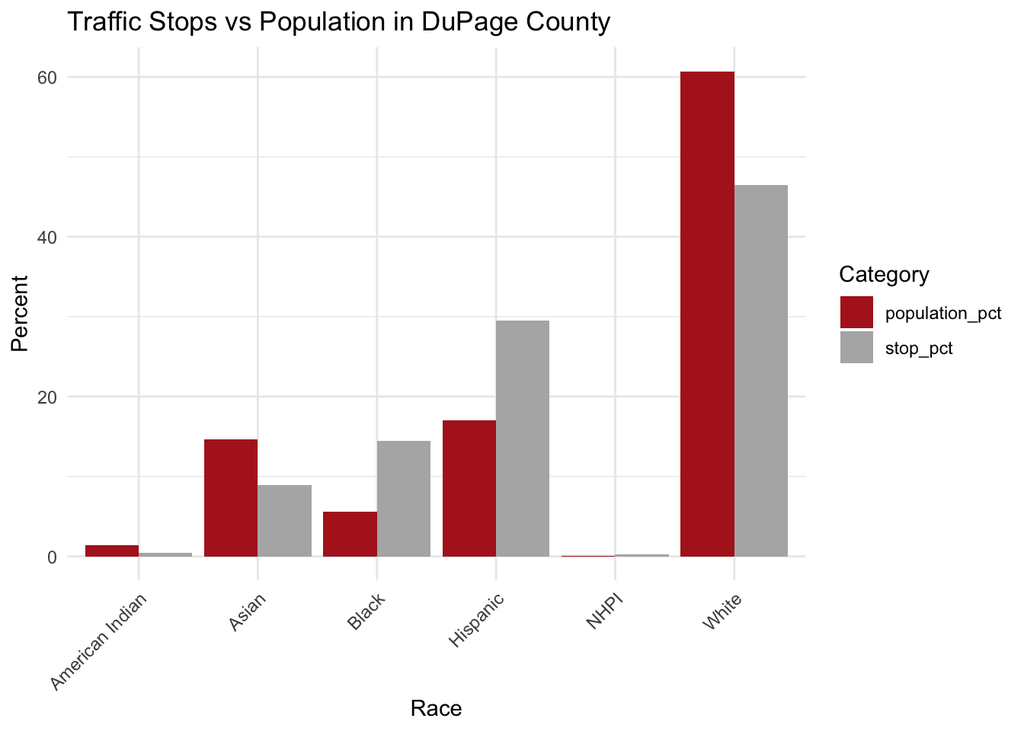

```r
## graphing it
ggplot(dupage_plot, aes(x = race, y = percent, fill = type)) +
  geom_col(position = "dodge") +
  scale_fill_manual(values = c(
    "stop_pct" = "grey70",
    "population_pct" = "#B22222"
  )) +
  labs(
    title = "Traffic Stops vs Population in DuPage County",
    x = "Race",
    y = "Percent",
    fill = "Category"
  ) +
  theme_minimal() +
  theme(axis.text.x = element_text(angle = 45, hjust = 1))
```

```r
### creating a new data table that has the total number of stops by race and then getting the number of searches that was conducted, creating a rate by taking searches divided by total stops and multiplying by 100 to get a percentage
dupage_search_rates <- dupage_law |>
  group_by(race) |>
  summarise(
    total_stops = n(),
    searches = sum(vehicle_search_conducted == "Yes", na.rm = TRUE),
    search_rate = searches/ total_stops * 100
  )


dupage_search_rates
```

```
## # A tibble: 6 × 4
##   race            total_stops searches search_rate
##   <chr>                 <int>    <int>       <dbl>
## 1 American Indian         914       10       1.09
## 2 Asian                 20439      116       0.568
## 3 Black                 33305     1740       5.22
## 4 Hispanic              67774     2254       3.33
## 5 NHPI                    548       13       2.37
## 6 White                106850     1114       1.04
```

- Black drivers have the highest search rates (5.2), followed by Hispanic drivers (3.3) and then NHPI drivers (2.4).

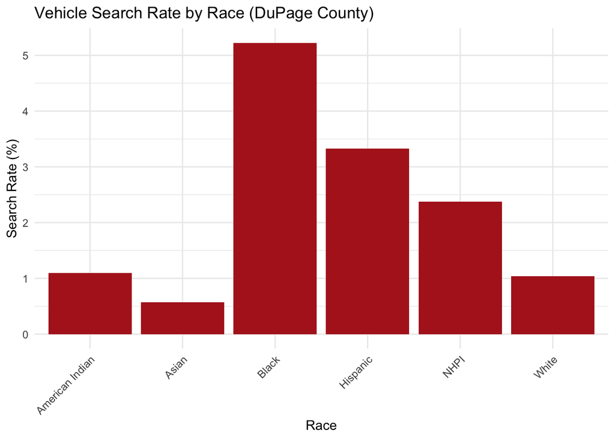

```r
ggplot(dupage_search_rates, aes(x = race, y = search_rate)) +
  geom_col(fill = "#B22222") +
  labs(
    title = "Vehicle Search Rate by Race (DuPage County)",
    x = "Race",
    y = "Search Rate (%)"
  ) +
  theme_minimal() +
  theme(axis.text.x = element_text(angle = 45, hjust = 1))
```

###### Top 3 DuPage County Law Enforcement Agencies

- SCHAUMBURG POLICE 23916
- AURORA POLICE 17657
- NAPERVILLE POLICE 14817

###### Schaumburg Police Department

```r
schaumburg_pop <- data.frame(
  race = c("White", "Black", "Hispanic", "Asian", "American Indian", "NHPI"),
  population_pct = c(53.7, 5.8, 12.7, 23.9, 0.5, 0)
)
```

```r
schaumburg_dupage <- dupage_law |>
  filter(agency_name == "SCHAUMBURG POLICE") |>
  count(race) |>
  mutate(stop_pct = n/sum(n) * 100)

schaumburg_dupage <- schaumburg_dupage|>
  left_join(schaumburg_pop, by ="race")

schaumburg_dupage
```

```
##               race     n   stop_pct population_pct
##             <char> <int>      <num>          <num>
## 1: American Indian   156  0.6522830            0.5
## 2:           Asian  4069 17.0137147           23.9
## 3:           Black  2524 10.5536043            5.8
## 4:        Hispanic  6336 26.4927245           12.7
## 5:            NHPI   108  0.4515805            0.0
## 6:           White 10723 44.8360930           53.7
```

```r
## graphing it
schaumburg_dupage_plot <- schaumburg_dupage %>%
  select(race, stop_pct, population_pct) %>%
  pivot_longer(
    cols = c(stop_pct, population_pct),
    names_to = "type",
    values_to = "percent"
  )
```

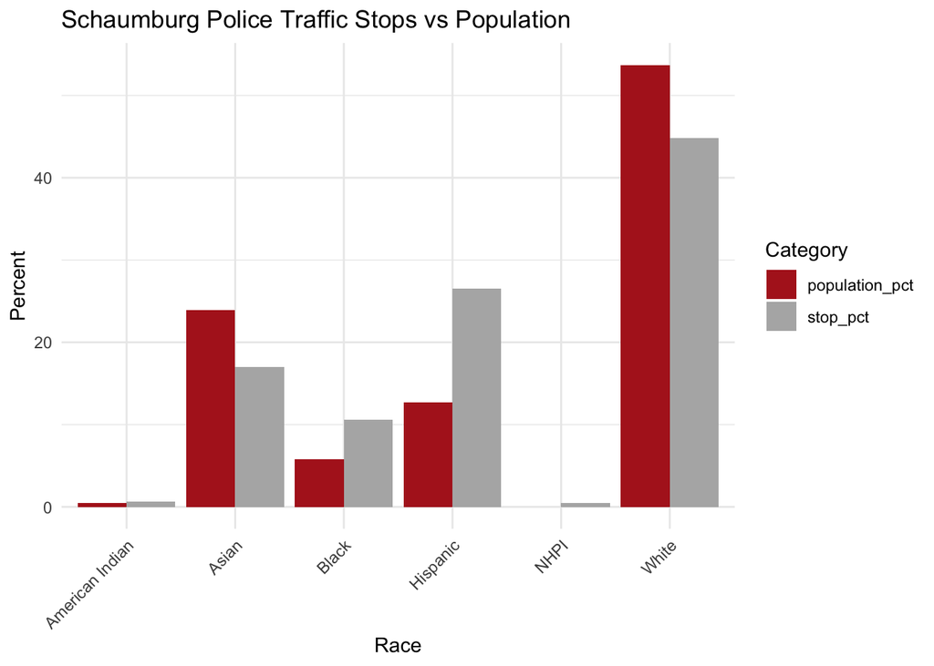

```r
## graphing it
ggplot(schaumburg_dupage_plot, aes(x = race, y = percent, fill = type)) +
  geom_col(position = "dodge") +
  scale_fill_manual(values = c(
    "stop_pct" = "grey70",
    "population_pct" = "#B22222"
  )) +
  labs(
    title = "Schaumburg Police Traffic Stops vs Population",
    x = "Race",
    y = "Percent",
    fill = "Category"
  ) +
  theme_minimal() +
  theme(axis.text.x = element_text(angle = 45, hjust = 1))
```

```r
### creating a new data table that has the total number of stops by race and then getting the number of searches that was conducted, creating a rate by taking searches divided by total stops and multiplying by 100 to get a percentage
schaumburg_search_rates <- dupage_law |>
  filter(agency_name == "SCHAUMBURG POLICE") |>
  group_by(race) |>
  summarise(
    total_stops = n(),
    searches = sum(vehicle_search_conducted == "Yes", na.rm = TRUE),
    search_rate = searches/ total_stops * 100
  )

schaumburg_search_rates
```

```
## # A tibble: 6 × 4
##   race            total_stops searches search_rate
##   <chr>                 <int>    <int>       <dbl>
## 1 American Indian         156        1       0.641
## 2 Asian                  4069        7       0.172
## 3 Black                  2524       42       1.66
## 4 Hispanic               6336       61       0.963
## 5 NHPI                    108        1       0.926
## 6 White                 10723       31       0.289
```

- Black drivers have the highest search rates (1.7), followed by Hispanic drivers (0.96), and then NHPI (0.93).

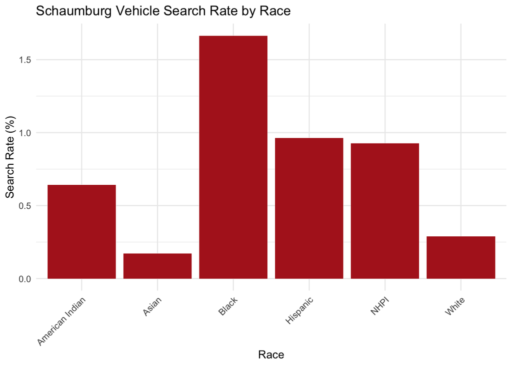

```r
ggplot(schaumburg_search_rates, aes(x = race, y = search_rate)) +
  geom_col(fill = "#B22222") +
  labs(
    title = "Schaumburg Vehicle Search Rate by Race",
    x = "Race",
    y = "Search Rate (%)"
  ) +
  theme_minimal() +
  theme(axis.text.x = element_text(angle = 45, hjust = 1))
```

###### Aurora Police Department

```r
aurora_pop <- data.frame(
  race = c("White", "Black", "Hispanic", "Asian", "American Indian", "NHPI"),
  population_pct = c(32.2, 11, 41.6, 12.4, 1.5, 0.1)
)
```

```r
aurora_dupage <- dupage_law |>
  filter(agency_name == "AURORA POLICE") |>
  count(race) |>
  mutate(stop_pct = n/sum(n) * 100)

aurora_dupage <- aurora_dupage |>
  left_join(aurora_pop, by ="race")

aurora_dupage
```

```
##               race     n   stop_pct population_pct
##             <char> <int>      <num>          <num>
## 1: American Indian   143  0.8098771            1.5
## 2:           Asian   622  3.5226822           12.4
## 3:           Black  3713 21.0284873           11.0
## 4:        Hispanic  8892 50.3596307           41.6
## 5:            NHPI    27  0.1529139            0.1
## 6:           White  4260 24.1264088           32.2
```

- Black, Hispanic, and NHPI drivers are overrepresented in traffic stops relative to their share of the population, while White, Asian, and American Indian drivers are underrepresented.

```r
## graphing it
aurora_dupage_plot <- aurora_dupage %>%
  select(race, stop_pct, population_pct) %>%
  pivot_longer(
    cols = c(stop_pct, population_pct),
    names_to = "type",
    values_to = "percent"
  )
```

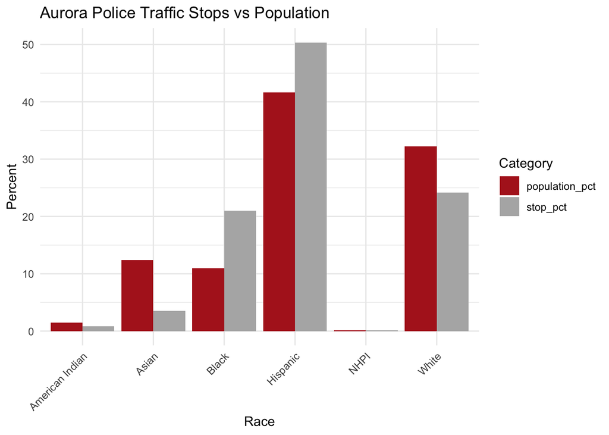

```r
## graphing it
ggplot(aurora_dupage_plot, aes(x = race, y = percent, fill = type)) +
  geom_col(position = "dodge") +
  scale_fill_manual(values = c(
    "stop_pct" = "grey70",
    "population_pct" = "#B22222"
  )) +
  labs(
    title = "Aurora Police Traffic Stops vs Population",
    x = "Race",
    y = "Percent",
    fill = "Category"
  ) +
  theme_minimal() +
  theme(axis.text.x = element_text(angle = 45, hjust = 1))
```

```r
### creating a new data table that has the total number of stops by race and then getting the number of searches that was conducted, creating a rate by taking searches divided by total stops and multiplying by 100 to get a percentage
aurora_search_rates <- dupage_law |>
  filter(agency_name == "AURORA POLICE") |>
  group_by(race) |>
  summarise(
    total_stops = n(),
    searches = sum(vehicle_search_conducted == "Yes", na.rm = TRUE),
    search_rate = searches/ total_stops * 100
  )

aurora_search_rates
```

```
## # A tibble: 6 × 4
##   race            total_stops searches search_rate
##   <chr>                 <int>    <int>       <dbl>
## 1 American Indian         143        1       0.699
## 2 Asian                   622        7       1.13
## 3 Black                  3713      392      10.6
## 4 Hispanic               8892      560       6.30
## 5 NHPI                     27        0       0
## 6 White                  4260      183       4.30
```

- Black drivers have the highest search rates (10.6), followed by Hispanic drivers (6.3) and then white drivers (4.3).

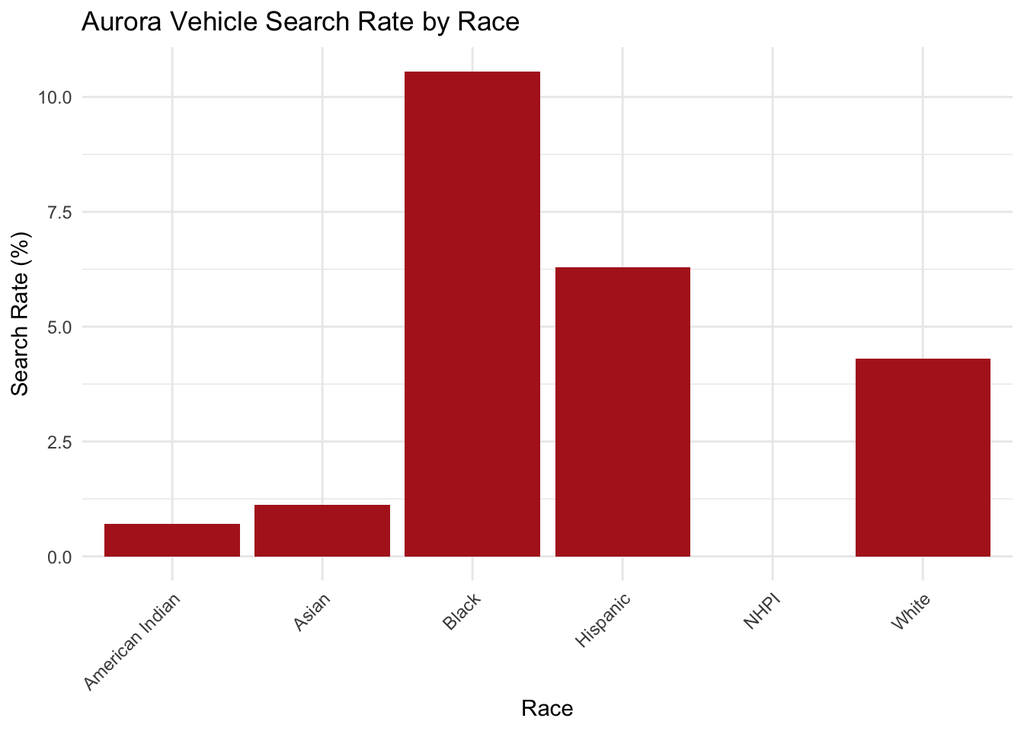

```r
ggplot(aurora_search_rates, aes(x = race, y = search_rate)) +
  geom_col(fill = "#B22222") +
  labs(
    title = "Aurora Vehicle Search Rate by Race",
    x = "Race",
    y = "Search Rate (%)"
  ) +
  theme_minimal() +
  theme(axis.text.x = element_text(angle = 45, hjust = 1))
```

###### Naperville Police Department

```r
naperville_pop <- data.frame(
  race = c("White", "Black", "Hispanic", "Asian", "American Indian", "NHPI"),
  population_pct = c(61, 4.3, 7.6, 22.5, 0.2, 0)
)
```

```r
naperville_dupage <- dupage_law |>
  filter(agency_name == "NAPERVILLE POLICE") |>
  count(race) |>
  mutate(stop_pct = n/sum(n) * 100)

naperville_dupage <- naperville_dupage |>
  left_join(naperville_pop, by ="race")

naperville_dupage
```

```
##               race     n    stop_pct population_pct
##             <char> <int>       <num>          <num>
## 1: American Indian    46  0.31045421            0.2
## 2:           Asian  1975 13.32928393           22.5
## 3:           Black  2970 20.04454343            4.3
## 4:        Hispanic  2217 14.96254302            7.6
## 5:            NHPI     6  0.04049403            0.0
## 6:           White  7603 51.31268138           61.0
```

```r
## graphing it
naperville_dupage_plot <- naperville_dupage %>%
  select(race, stop_pct, population_pct) %>%
  pivot_longer(
    cols = c(stop_pct, population_pct),
    names_to = "type",
    values_to = "percent"
  )
```

[figure not shown]

```r
## graphing it
ggplot(naperville_dupage_plot, aes(x = race, y = percent, fill = type)) +
  geom_col(position = "dodge") +
  scale_fill_manual(values = c(
    "stop_pct" = "grey70",
    "population_pct" = "#B22222"
  )) +
  labs(
    title = "Aurora Police Traffic Stops vs Population",
    x = "Race",
    y = "Percent",
    fill = "Category"
  ) +
  theme_minimal() +
  theme(axis.text.x = element_text(angle = 45, hjust = 1))
```

```r
### creating a new data table that has the total number of stops by race and then getting the number of searches that was conducted, creating a rate by taking searches divided by total stops and multiplying by 100 to get a percentage
naperville_search_rates <- dupage_law |>
  filter(agency_name == "NAPERVILLE POLICE") |>
  group_by(race) |>
  summarise(
    total_stops = n(),
    searches = sum(vehicle_search_conducted == "Yes", na.rm = TRUE),
    search_rate = searches/ total_stops * 100
  )

naperville_search_rates
```

```
## # A tibble: 6 × 4
##   race            total_stops searches search_rate
##   <chr>                 <int>    <int>       <dbl>
## 1 American Indian          46        1       2.17
## 2 Asian                  1975       11       0.557
## 3 Black                  2970      318      10.7
## 4 Hispanic               2217       92       4.15
## 5 NHPI                      6        2      33.3
## 6 White                  7603      100       1.32
```

- NHPI due to the small numbers have the highest search rates (33.3), followed by Black drivers have the highest search rates (10.7), followed by Hispanic drivers (4.1),

[figure not shown]

```r
ggplot(naperville_search_rates, aes(x = race, y = search_rate)) +
  geom_col(fill = "#B22222") +
  labs(
    title = "Aurora Vehicle Search Rate by Race",
    x = "Race",
    y = "Search Rate (%)"
  ) +
  theme_minimal() +
  theme(axis.text.x = element_text(angle = 45, hjust = 1))
```

###### Lombard Police

```r
lombard_pop <- data.frame(
  race = c("White", "Black", "Hispanic", "Asian", "American Indian", "NHPI"),
  population_pct = c(66, 5.2, 14.4, 10.7, 0.3, 0.1)
)
```

```r
lombard_dupage <- dupage_law |>
  filter(agency_name == "LOMBARD POLICE") |>
  count(race) |>
  mutate(stop_pct = n/sum(n) * 100)

lombard_dupage <- lombard_dupage |>
  left_join(lombard_pop, by ="race")

lombard_dupage
```

```
##               race     n    stop_pct population_pct
##             <char> <int>       <num>          <num>
## 1: American Indian    16  0.11424491            0.3
## 2:           Asian  1636 11.68154231           10.7
## 3:           Black  2254 16.09425205            5.2
## 4:        Hispanic  2709 19.34309175           14.4
## 5:            NHPI    11  0.07854338            0.1
## 6:           White  7379 52.68832560           66.0
```

```r
lombard_search_rates <- dupage_law |>
  filter(agency_name == "LOMBARD POLICE") |>
  group_by(race) |>
  summarise(
    total_stops = n(),
    searches = sum(vehicle_search_conducted == "Yes", na.rm = TRUE),
    search_rate = searches/ total_stops * 100
  )

lombard_search_rates
```

```
## # A tibble: 6 × 4
##   race            total_stops searches search_rate
##   <chr>                 <int>    <int>       <dbl>
## 1 American Indian          16        0      0
## 2 Asian                  1636        2      0.122
## 3 Black                  2254       11      0.488
## 4 Hispanic               2709       12      0.443
## 5 NHPI                     11        1      9.09
## 6 White                  7379        4      0.0542
```

###### Hanover Park Police

```r
hanoverpark_pop <- data.frame(
  race = c("White", "Black", "Hispanic", "Asian", "American Indian", "NHPI"),
  population_pct = c(30.2, 7.3, 40.5, 18.7, 1.1, 0.1)
)
```

```r
hanoverpark_dupage <- dupage_law |>
  filter(agency_name == "HANOVER PARK POLICE") |>
  count(race) |>
  mutate(stop_pct = n/sum(n) * 100)

hanoverpark_dupage <- hanoverpark_dupage |>
  left_join(hanoverpark_pop, by ="race")

hanoverpark_dupage
```

```
##               race     n    stop_pct population_pct
##             <char> <int>       <num>          <num>
## 1: American Indian    11  0.08605179            1.1
## 2:           Asian  1393 10.89728546           18.7
## 3:           Black  1457 11.39795040            7.3
## 4:        Hispanic  5742 44.91903309           40.5
## 5:            NHPI    43  0.33638426            0.1
## 6:           White  4137 32.36329500           30.2
```

```r
hanoverpark_search_rates <- dupage_law |>
  filter(agency_name == "HANOVER PARK POLICE") |>
  group_by(race) |>
  summarise(
    total_stops = n(),
    searches = sum(vehicle_search_conducted == "Yes", na.rm = TRUE),
    search_rate = searches/ total_stops * 100
  )

hanoverpark_search_rates
```

```
## # A tibble: 6 × 4
##   race            total_stops searches search_rate
##   <chr>                 <int>    <int>       <dbl>
## 1 American Indian          11        0        0
## 2 Asian                  1393       17        1.22
## 3 Black                  1457       84        5.77
## 4 Hispanic               5742      383        6.67
## 5 NHPI                     43        5       11.6
## 6 White                  4137      128        3.09
```

###### Elmhurst Police

```r
elmhurst_pop <- data.frame(
  race = c("White", "Black", "Hispanic", "Asian", "American Indian", "NHPI"),
  population_pct = c(76, 1.9, 10.4, 7.8, 0.3, 0)
)
```

```r
elmhurst_dupage <- dupage_law |>
  filter(agency_name == "ELMHURST POLICE") |>
  count(race) |>
  mutate(stop_pct = n/sum(n) * 100)

elmhurst_dupage <- elmhurst_dupage |>
  left_join(elmhurst_pop, by ="race")

elmhurst_dupage
```

```
##               race     n   stop_pct population_pct
##             <char> <int>      <num>          <num>
## 1: American Indian    47  0.4298518            0.3
## 2:           Asian   461  4.2162063            7.8
## 3:           Black  1785 16.3252241            1.9
## 4:        Hispanic  2955 27.0257911           10.4
## 5:            NHPI    57  0.5213097            0.0
## 6:           White  5629 51.4816170           76.0
```

```r
elmhurst_search_rates <- dupage_law |>
  filter(agency_name == "ELMHURST POLICE") |>
  group_by(race) |>
  summarise(
    total_stops = n(),
    searches = sum(vehicle_search_conducted == "Yes", na.rm = TRUE),
    search_rate = searches/ total_stops * 100
  )

elmhurst_search_rates
```

```
## # A tibble: 6 × 4
##   race            total_stops searches search_rate
##   <chr>                 <int>    <int>       <dbl>
## 1 American Indian          47        0       0
## 2 Asian                   461        1       0.217
## 3 Black                  1785       27       1.51
## 4 Hispanic               2955       48       1.62
## 5 NHPI                     57        1       1.75
## 6 White                  5629       28       0.497
```

###### West Chicago Police

```r
westchicago_pop <- data.frame(
  race = c("White", "Black", "Hispanic", "Asian", "American Indian", "NHPI"),
  population_pct = c(35.3, 3.2, 47.8, 10.4, 1.1, 0)
)
```

```r
westchicago_dupage <- dupage_law |>
  filter(agency_name == "WEST CHICAGO POLICE") |>
  count(race) |>
  mutate(stop_pct = n/sum(n) * 100)

westchicago_dupage <- westchicago_dupage |>
  left_join(westchicago_pop, by ="race")

westchicago_dupage
```

```
##               race     n   stop_pct population_pct
##             <char> <int>      <num>          <num>
## 1: American Indian    16  0.1506449            1.1
## 2:           Asian   564  5.3102344           10.4
## 3:           Black  1010  9.5094624            3.2
## 4:        Hispanic  5100 48.0180774           47.8
## 5:            NHPI    48  0.4519348            0.0
## 6:           White  3883 36.5596460           35.3
```

```r
westchicago_search_rates <- dupage_law |>
  filter(agency_name == "WEST CHICAGO POLICE") |>
  group_by(race) |>
  summarise(
    total_stops = n(),
    searches = sum(vehicle_search_conducted == "Yes", na.rm = TRUE),
    search_rate = searches/ total_stops * 100
  )

westchicago_search_rates
```

```
## # A tibble: 6 × 4
##   race            total_stops searches search_rate
##   <chr>                 <int>    <int>       <dbl>
## 1 American Indian          16        0       0
## 2 Asian                   564        4       0.709
## 3 Black                  1010       48       4.75
## 4 Hispanic               5100      247       4.84
## 5 NHPI                     48        0       0
## 6 White                  3883       83       2.14
```

###### Bloomingdale Police

```r
bloomingdale_pop <- data.frame(
  race = c("White", "Black", "Hispanic", "Asian", "American Indian", "NHPI"),
  population_pct = c(68.6, 3.1, 12.8, 14.5, 0.2, 0)
)
```

```r
bloomingdale_dupage <- dupage_law |>
  filter(agency_name == "BLOOMINGDALE POLICE") |>
  count(race) |>
  mutate(stop_pct = n/sum(n) * 100)

bloomingdale_dupage <- bloomingdale_dupage |>
  left_join(bloomingdale_pop, by ="race")

bloomingdale_dupage
```

```
##               race     n   stop_pct population_pct
##             <char> <int>      <num>          <num>
## 1: American Indian    12  0.1182266            0.2
## 2:           Asian   949  9.3497537           14.5
## 3:           Black  1736 17.1034483            3.1
## 4:        Hispanic  3677 36.2266010           12.8
## 5:            NHPI    13  0.1280788            0.0
## 6:           White  3763 37.0738916           68.6
```

```r
bloomingdale_search_rates <- dupage_law |>
  filter(agency_name == "BLOOMINGDALE POLICE") |>
  group_by(race) |>
  summarise(
    total_stops = n(),
    searches = sum(vehicle_search_conducted == "Yes", na.rm = TRUE),
    search_rate = searches/ total_stops * 100
  )

bloomingdale_search_rates
```

```
## # A tibble: 6 × 4
##   race            total_stops searches search_rate
##   <chr>                 <int>    <int>       <dbl>
## 1 American Indian          12        1        8.33
## 2 Asian                   949       21        2.21
## 3 Black                  1736      204       11.8
## 4 Hispanic               3677      235        6.39
## 5 NHPI                     13        1        7.69
## 6 White                  3763      130        3.45
```

###### Glen Ellyn Police

```r
glenellyn_pop <- data.frame(
  race = c("White", "Black", "Hispanic", "Asian", "American Indian", "NHPI"),
  population_pct = c(75.1, 3, 6.9, 10.8, 0, 0.1)
)
```

```r
glenellyn_dupage <- dupage_law |>
  filter(agency_name == "GLEN ELLYN POLICE") |>
  count(race) |>
  mutate(stop_pct = n/sum(n) * 100)

glenellyn_dupage <- glenellyn_dupage |>
  left_join(glenellyn_pop, by ="race")

glenellyn_dupage
```

```
##               race     n   stop_pct population_pct
##             <char> <int>      <num>          <num>
## 1: American Indian    23  0.2281293            0.0
## 2:           Asian   504  4.9990081           10.8
## 3:           Black  1384 13.7274350            3.0
## 4:        Hispanic  1920 19.0438405            6.9
## 5:            NHPI    14  0.1388613            0.1
## 6:           White  6237 61.8627256           75.1
```

```r
glenellyn_search_rates <- dupage_law |>
  filter(agency_name == "GLEN ELLYN POLICE") |>
  group_by(race) |>
  summarise(
    total_stops = n(),
    searches = sum(vehicle_search_conducted == "Yes", na.rm = TRUE),
    search_rate = searches/ total_stops * 100
  )

glenellyn_search_rates
```

```
## # A tibble: 6 × 4
##   race            total_stops searches search_rate
##   <chr>                 <int>    <int>       <dbl>
## 1 American Indian          23        0       0
## 2 Asian                   504        3       0.595
## 3 Black                  1384       39       2.82
## 4 Hispanic               1920       22       1.15
## 5 NHPI                     14        0       0
## 6 White                  6237       33       0.529
```

###### Carol Stream Police

```r
carolstream_pop <- data.frame(
  race = c("White", "Black", "Hispanic", "Asian", "American Indian", "NHPI"),
  population_pct = c(50.1, 6.3, 18.5, 19.4, 0.7, 0.2)
)
```

```r
carolstream_dupage <- dupage_law |>
  filter(agency_name == "CAROL STREAM POLICE") |>
  count(race) |>
  mutate(stop_pct = n/sum(n) * 100)

carolstream_dupage <- carolstream_dupage |>
  left_join(carolstream_pop, by ="race")

carolstream_dupage
```

```
##               race     n    stop_pct population_pct
##             <char> <int>       <num>          <num>
## 1: American Indian    54  0.56220718            0.7
## 2:           Asian  1188 12.36855804           19.4
## 3:           Black  1082 11.26496616            6.3
## 4:        Hispanic  2780 28.94325872           18.5
## 5:            NHPI     3  0.03123373            0.2
## 6:           White  4498 46.82977616           50.1
```

```r
carolstream_search_rates <- dupage_law |>
  filter(agency_name == "CAROL STREAM POLICE") |>
  group_by(race) |>
  summarise(
    total_stops = n(),
    searches = sum(vehicle_search_conducted == "Yes", na.rm = TRUE),
    search_rate = searches/ total_stops * 100
  )

carolstream_search_rates
```

```
## # A tibble: 6 × 4
##   race            total_stops searches search_rate
##   <chr>                 <int>    <int>       <dbl>
## 1 American Indian          54        1       1.85
## 2 Asian                  1188        5       0.421
## 3 Black                  1082       33       3.05
## 4 Hispanic               2780       35       1.26
## 5 NHPI                      3        0       0
## 6 White                  4498       31       0.689
```

###### Addison Police

```r
addison_pop <- data.frame(
  race = c("White", "Black", "Hispanic", "Asian", "American Indian", "NHPI"),
  population_pct = c(40.8, 3.4, 46, 8.6, 1.5, 0)
)
```

```r
addison_dupage <- dupage_law |>
  filter(agency_name == "ADDISON POLICE") |>
  count(race) |>
  mutate(stop_pct = n/sum(n) * 100)

addison_dupage <- addison_dupage |>
  left_join(addison_pop, by ="race")

addison_dupage
```

```
##               race     n   stop_pct population_pct
##             <char> <int>      <num>          <num>
## 1: American Indian    99  1.1250000            1.5
## 2:           Asian   477  5.4204545            8.6
## 3:           Black   713  8.1022727            3.4
## 4:        Hispanic  4157 47.2386364           46.0
## 5:            NHPI    27  0.3068182            0.0
## 6:           White  3327 37.8068182           40.8
```

```r
addison_search_rates <- dupage_law |>
  filter(agency_name == "ADDISON POLICE") |>
  group_by(race) |>
  summarise(
    total_stops = n(),
    searches = sum(vehicle_search_conducted == "Yes", na.rm = TRUE),
    search_rate = searches/ total_stops * 100
  )

addison_search_rates
```

```
## # A tibble: 6 × 4
##   race            total_stops searches search_rate
##   <chr>                 <int>    <int>       <dbl>
## 1 American Indian          99        1       1.01
## 2 Asian                   477        2       0.419
## 3 Black                   713       18       2.52
## 4 Hispanic               4157       61       1.47
## 5 NHPI                     27        1       3.70
## 6 White                  3327       23       0.691
```

##### Bartlett Police

```r
bartlett_pop <- data.frame(
  race = c("White", "Black", "Hispanic", "Asian", "American Indian", "NHPI"),
  population_pct = c(59, 4.4, 15, 19.7, 1.4, 0.1)
)
```

```r
bartlett_dupage <- dupage_law |>
  filter(agency_name == "BARTLETT POLICE") |>
  count(race) |>
  mutate(stop_pct = n/sum(n) * 100)

bartlett_dupage  <- bartlett_dupage  |>
  left_join(bartlett_pop, by ="race")

bartlett_dupage
```

```
##               race     n    stop_pct population_pct
##             <char> <int>       <num>          <num>
## 1: American Indian    32  0.40516586            1.4
## 2:           Asian   971 12.29425171           19.7
## 3:           Black   638  8.07799443            4.4
## 4:        Hispanic  2358 29.85565966           15.0
## 5:            NHPI     1  0.01266143            0.1
## 6:           White  3898 49.35426690           59.0
```

```r
bartlett_search_rates <- dupage_law |>
  filter(agency_name == "BARTLETT POLICE") |>
  group_by(race) |>
  summarise(
    total_stops = n(),
    searches = sum(vehicle_search_conducted == "Yes", na.rm = TRUE),
    search_rate = searches/ total_stops * 100
  )

bartlett_search_rates
```

```
## # A tibble: 6 × 4
##   race            total_stops searches search_rate
##   <chr>                 <int>    <int>       <dbl>
## 1 American Indian          32        2       6.25
## 2 Asian                   971        2       0.206
## 3 Black                   638        9       1.41
## 4 Hispanic               2358       22       0.933
## 5 NHPI                      1        0       0
## 6 White                  3898        7       0.180
```

###### Warrenville Police

```r
warrenville_pop <- data.frame(
  race = c("White", "Black", "Hispanic", "Asian", "American Indian", "NHPI"),
  population_pct = c(61.4, 5.2, 25.6, 6.7, 1.4, 0.1)
)
```

```r
warrenville_dupage <- dupage_law |>
  filter(agency_name == "WARRENVILLE POLICE") |>
  count(race) |>
  mutate(stop_pct = n/sum(n) * 100)

warrenville_dupage <- warrenville_dupage |>
  left_join(warrenville_pop, by ="race")

warrenville_dupage
```

```
##               race     n    stop_pct population_pct
##             <char> <int>       <num>          <num>
## 1: American Indian     2  0.02763194            1.4
## 2:           Asian   455  6.28626692            6.7
## 3:           Black  1046 14.45150594            5.2
## 4:        Hispanic  1879 25.96021000           25.6
## 5:            NHPI     4  0.05526389            0.1
## 6:           White  3852 53.21912130           61.4
```

```r
warrenville_search_rates <- dupage_law |>
  filter(agency_name == "WARRENVILLE POLICE") |>
  group_by(race) |>
  summarise(
    total_stops = n(),
    searches = sum(vehicle_search_conducted == "Yes", na.rm = TRUE),
    search_rate = searches/ total_stops * 100
  )

warrenville_search_rates
```

```
## # A tibble: 6 × 4
##   race            total_stops searches search_rate
##   <chr>                 <int>    <int>       <dbl>
## 1 American Indian           2        0       0
## 2 Asian                   455        3       0.659
## 3 Black                  1046       59       5.64
## 4 Hispanic               1879       62       3.30
## 5 NHPI                      4        0       0
## 6 White                  3852       44       1.14
```

###### Wheaton Police

```r
wheaton_pop <- data.frame(
  race = c("White", "Black", "Hispanic", "Asian", "American Indian", "NHPI"),
  population_pct = c(76.3, 4.2, 8.9, 5.8, 0, 0)
)
```

```r
wheaton_dupage <- dupage_law |>
  filter(agency_name == "WHEATON POLICE") |>
  count(race) |>
  mutate(stop_pct = n/sum(n) * 100)

wheaton_dupage <- wheaton_dupage |>
  left_join(wheaton_pop, by ="race")

wheaton_dupage
```

```
##               race     n   stop_pct population_pct
##             <char> <int>      <num>          <num>
## 1: American Indian    15  0.2168570            0.0
## 2:           Asian   482  6.9683389            5.8
## 3:           Black   990 14.3125632            4.2
## 4:        Hispanic  1332 19.2569033            8.9
## 5:            NHPI    25  0.3614284            0.0
## 6:           White  4073 58.8839092           76.3
```

```r
wheaton_search_rates <- dupage_law |>
  filter(agency_name == "WHEATON POLICE") |>
  group_by(race) |>
  summarise(
    total_stops = n(),
    searches = sum(vehicle_search_conducted == "Yes", na.rm = TRUE),
    search_rate = searches/ total_stops * 100
  )

wheaton_search_rates
```

```
## # A tibble: 6 × 4
##   race            total_stops searches search_rate
##   <chr>                 <int>    <int>       <dbl>
## 1 American Indian          15        0       0
## 2 Asian                   482        4       0.830
## 3 Black                   990       14       1.41
## 4 Hispanic               1332       13       0.976
## 5 NHPI                     25        0       0
## 6 White                  4073       12       0.295
```

###### Glendale Heights Police

```r
glendale_pop <- data.frame(
  race = c("White", "Black", "Hispanic", "Asian", "American Indian", "NHPI"),
  population_pct = c(27.8, 10.1, 33.2, 25.6, 2.1, 0)
)
```

```r
glendale_dupage <- dupage_law |>
  filter(agency_name == "GLENDALE HEIGHTS POLICE") |>
  count(race) |>
  mutate(stop_pct = n/sum(n) * 100)

glendale_dupage  <- glendale_dupage  |>
  left_join(glendale_pop, by ="race")

glendale_dupage
```

```
##               race     n   stop_pct population_pct
##             <char> <int>      <num>          <num>
## 1: American Indian    14  0.2115762            2.1
## 2:           Asian   745 11.2588786           25.6
## 3:           Black   788 11.9087200           10.1
## 4:        Hispanic  2341 35.3785703           33.2
## 5:            NHPI    28  0.4231525            0.0
## 6:           White  2701 40.8191023           27.8
```

```r
glendale_search_rates <- dupage_law  |>
  filter(agency_name == "GLENDALE HEIGHTS POLICE") |>
  group_by(race) |>
  summarise(
    total_stops = n(),
    searches = sum(vehicle_search_conducted == "Yes", na.rm = TRUE),
    search_rate = searches/ total_stops * 100
  )

glendale_search_rates
```

```
## # A tibble: 6 × 4
##   race            total_stops searches search_rate
##   <chr>                 <int>    <int>       <dbl>
## 1 American Indian          14        2      14.3
## 2 Asian                   745        4       0.537
## 3 Black                   788       14       1.78
## 4 Hispanic               2341       59       2.52
## 5 NHPI                     28        0       0
## 6 White                  2701       42       1.55
```

###### Westmont Police

```r
westmont_pop <- data.frame(
  race = c("White", "Black", "Hispanic", "Asian", "American Indian", "NHPI"),
  population_pct = c(61.7, 5.9, 14.2, 14.9, 1.1, 0)
)
```

```r
westmont_dupage <- dupage_law |>
  filter(agency_name == "WESTMONT POLICE") |>
  count(race) |>
  mutate(stop_pct = n/sum(n) * 100)

westmont_dupage <- westmont_dupage |>
  left_join(westmont_pop, by ="race")

westmont_dupage
```

```
##               race     n   stop_pct population_pct
##             <char> <int>      <num>          <num>
## 1: American Indian    15  0.2980330            1.1
## 2:           Asian   284  5.6427578           14.9
## 3:           Black   781 15.5175839            5.9
## 4:        Hispanic   792 15.7361415           14.2
## 5:            NHPI     3  0.0596066            0.0
## 6:           White  3158 62.7458772           61.7
```

```r
westmont_search_rates <- dupage_law |>
  filter(agency_name == "WESTMONT POLICE") |>
  group_by(race) |>
  summarise(
    total_stops = n(),
    searches = sum(vehicle_search_conducted == "Yes", na.rm = TRUE),
    search_rate = searches/ total_stops * 100
  )

westmont_search_rates
```

```
## # A tibble: 6 × 4
##   race            total_stops searches search_rate
##   <chr>                 <int>    <int>       <dbl>
## 1 American Indian          15        0       0
## 2 Asian                   284        0       0
## 3 Black                   781        6       0.768
## 4 Hispanic                792        9       1.14
## 5 NHPI                      3        0       0
## 6 White                  3158       13       0.412
```

###### Lisle Police

```r
lisle_pop <- data.frame(
  race = c("White", "Black", "Hispanic", "Asian", "American Indian", "NHPI"),
  population_pct = c(65.1, 4.7, 8.9, 17.4, 0, 0)
)
```

```r
lisle_dupage <- dupage_law |>
  filter(agency_name == "LISLE POLICE") |>
  count(race) |>
  mutate(stop_pct = n/sum(n) * 100)

lisle_dupage  <- lisle_dupage  |>
  left_join(lisle_pop, by ="race")

lisle_dupage
```

```
##        race     n   stop_pct population_pct
##      <char> <int>      <num>          <num>
## 1:    Asian   531 10.6306306           17.4
## 2:    Black   822 16.4564565            4.7
## 3: Hispanic   845 16.9169169            8.9
## 4:     NHPI     7  0.1401401            0.0
## 5:    White  2790 55.8558559           65.1
```

```r
lisle_search_rates <- dupage_law |>
  filter(agency_name == "LISLE POLICE") |>
  group_by(race) |>
  summarise(
    total_stops = n(),
    searches = sum(vehicle_search_conducted == "Yes", na.rm = TRUE),
    search_rate = searches/ total_stops * 100
  )

lisle_search_rates
```

```
## # A tibble: 5 × 4
##   race     total_stops searches search_rate
##   <chr>          <int>    <int>       <dbl>
## 1 Asian            531        0       0
## 2 Black            822       10       1.22
## 3 Hispanic         845        5       0.592
## 4 NHPI               7        0       0
## 5 White           2790        5       0.179
```

###### Wood Dale Police

```r
wooddale_pop <- data.frame(
  race = c("White", "Black", "Hispanic", "Asian", "American Indian", "NHPI"),
  population_pct = c(59.1, 3, 31.8, 5.1, 1.2, 0)
)
```

```r
wooddale_dupage <- dupage_law |>
  filter(agency_name == "WOOD DALE POLICE") |>
  count(race) |>
  mutate(stop_pct = n/sum(n) * 100)

wooddale_dupage <- wooddale_dupage |>
  left_join(wooddale_pop, by ="race")

wooddale_dupage
```

```
##               race     n   stop_pct population_pct
##             <char> <int>      <num>          <num>
## 1: American Indian    13  0.2602603            1.2
## 2:           Asian   390  7.8078078            5.1
## 3:           Black   348  6.9669670            3.0
## 4:        Hispanic  1986 39.7597598           31.8
## 5:            NHPI    14  0.2802803            0.0
## 6:           White  2244 44.9249249           59.1
```

```r
wooddale_search_rates <- dupage_law |>
  filter(agency_name == "WOOD DALE POLICE") |>
  group_by(race) |>
  summarise(
    total_stops = n(),
    searches = sum(vehicle_search_conducted == "Yes", na.rm = TRUE),
    search_rate = searches/ total_stops * 100
  )

wooddale_search_rates
```

```
## # A tibble: 6 × 4
##   race            total_stops searches search_rate
##   <chr>                 <int>    <int>       <dbl>
## 1 American Indian          13        0       0
## 2 Asian                   390        3       0.769
## 3 Black                   348       15       4.31
## 4 Hispanic               1986       79       3.98
## 5 NHPI                     14        1       7.14
## 6 White                  2244       26       1.16
```

###### Hindsdale Police

```r
hinsdale_pop <- data.frame(
  race = c("White", "Black", "Hispanic", "Asian", "American Indian", "NHPI"),
  population_pct = c(72.7, 1.7, 5.9, 13.9, 0.2, 0.1)
)
```

```r
hinsdale_dupage <- dupage_law |>
  filter(agency_name == "HINSDALE POLICE") |>
  count(race) |>
  mutate(stop_pct = n/sum(n) * 100)

hinsdale_dupage  <- hinsdale_dupage  |>
  left_join(hinsdale_pop, by ="race")

hinsdale_dupage
```

```
##               race     n    stop_pct population_pct
##             <char> <int>       <num>          <num>
## 1: American Indian     1  0.02191541            0.2
## 2:           Asian   233  5.10628972           13.9
## 3:           Black   639 14.00394477            1.7
## 4:        Hispanic   805 17.64190226            5.9
## 5:           White  2885 63.22594784           72.7
```

```r
hinsdale_search_rates <- dupage_law |>
  filter(agency_name == "HINSDALE POLICE") |>
  group_by(race) |>
  summarise(
    total_stops = n(),
    searches = sum(vehicle_search_conducted == "Yes", na.rm = TRUE),
    search_rate = searches/ total_stops * 100
  )

hinsdale_search_rates
```

```
## # A tibble: 5 × 4
##   race            total_stops searches search_rate
##   <chr>                 <int>    <int>       <dbl>
## 1 American Indian           1        0       0
## 2 Asian                   233        1       0.429
## 3 Black                   639       30       4.69
## 4 Hispanic                805       23       2.86
## 5 White                  2885       21       0.728
```

###### Darien Police

```r
darien_pop <- data.frame(
  race = c("White", "Black", "Hispanic", "Asian", "American Indian", "NHPI"),
  population_pct = c(73.2, 2.9, 9.3, 12.1, 0.2, 0)
)
```

```r
darien_dupage <- dupage_law |>
  filter(agency_name == "DARIEN POLICE") |>
  count(race) |>
  mutate(stop_pct = n/sum(n) * 100)

darien_dupage <- darien_dupage |>
  left_join(darien_pop, by ="race")

darien_dupage
```

```
##               race     n   stop_pct population_pct
##             <char> <int>      <num>          <num>
## 1: American Indian    21  0.4771643            0.2
## 2:           Asian   309  7.0211316           12.1
## 3:           Black   784 17.8141332            2.9
## 4:        Hispanic   740 16.8143604            9.3
## 5:            NHPI    16  0.3635537            0.0
## 6:           White  2531 57.5096569           73.2
```

```r
darien_search_rates <- dupage_law |>
  filter(agency_name == "DARIEN POLICE") |>
  group_by(race) |>
  summarise(
    total_stops = n(),
    searches = sum(vehicle_search_conducted == "Yes", na.rm = TRUE),
    search_rate = searches/ total_stops * 100
  )

darien_search_rates
```

```
## # A tibble: 6 × 4
##   race            total_stops searches search_rate
##   <chr>                 <int>    <int>       <dbl>
## 1 American Indian          21        0        0
## 2 Asian                   309        6        1.94
## 3 Black                   784       48        6.12
## 4 Hispanic                740       25        3.38
## 5 NHPI                     16        0        0
## 6 White                  2531       29        1.15
```

###### Woodridge Police

```r
woodridge_pop <- data.frame(
  race = c("White", "Black", "Hispanic", "Asian", "American Indian", "NHPI"),
  population_pct = c(56.8, 10.6, 16, 12.1, 0.1, 0)
)
```

```r
woodridge_dupage <- dupage_law |>
  filter(agency_name == "WOODRIDGE POLICE") |>
  count(race) |>
  mutate(stop_pct = n/sum(n) * 100)

woodridge_dupage |>
  left_join(woodridge_pop, by ="race")
```

```
##               race     n   stop_pct population_pct
##             <char> <int>      <num>          <num>
## 1: American Indian    25  0.6317918            0.1
## 2:           Asian   246  6.2168309           12.1
## 3:           Black  1151 29.0876927           10.6
## 4:        Hispanic   799 20.1920647           16.0
## 5:            NHPI     8  0.2021734            0.0
## 6:           White  1728 43.6694466           56.8
```

```r
woodridge_dupage
```

```
##               race     n   stop_pct
##             <char> <int>      <num>
## 1: American Indian    25  0.6317918
## 2:           Asian   246  6.2168309
## 3:           Black  1151 29.0876927
## 4:        Hispanic   799 20.1920647
## 5:            NHPI     8  0.2021734
## 6:           White  1728 43.6694466
```

```r
woodridge_search_rates <- dupage_law |>
  filter(agency_name == "WOODRIDGE POLICE") |>
  group_by(race) |>
  summarise(
    total_stops = n(),
    searches = sum(vehicle_search_conducted == "Yes", na.rm = TRUE),
    search_rate = searches/ total_stops * 100
  )

woodridge_search_rates
```

```
## # A tibble: 6 × 4
##   race            total_stops searches search_rate
##   <chr>                 <int>    <int>       <dbl>
## 1 American Indian          25        0        0
## 2 Asian                   246        4        1.63
## 3 Black                  1151      127       11.0
## 4 Hispanic                799       40        5.01
## 5 NHPI                      8        0        0
## 6 White                  1728       40        2.31
```

###### Burr Ridge Police

```r
burrridge_pop <- data.frame(
  race = c("White", "Black", "Hispanic", "Asian", "American Indian", "NHPI"),
  population_pct = c(72.5, 0.3, 5, 14.5, 0, 0)
)
```

```r
burrridge_dupage <- dupage_law |>
  filter(agency_name == "BURR RIDGE POLICE") |>
  count(race) |>
  mutate(stop_pct = n/sum(n) * 100)

burrridge_dupage <- burrridge_dupage |>
  left_join(burrridge_pop, by ="race")

burrridge_dupage
```

```
##               race     n    stop_pct population_pct
##             <char> <int>       <num>          <num>
## 1: American Indian     3  0.07810466            0.0
## 2:           Asian   298  7.75839625           14.5
## 3:           Black   655 17.05285082            0.3
## 4:        Hispanic   733 19.08357199            5.0
## 5:            NHPI     1  0.02603489            0.0
## 6:           White  2151 56.00104140           72.5
```

```r
burrridge_search_rates <- dupage_law |>
  filter(agency_name == "BURR RIDGE POLICE") |>
  group_by(race) |>
  summarise(
    total_stops = n(),
    searches = sum(vehicle_search_conducted == "Yes", na.rm = TRUE),
    search_rate = searches/ total_stops * 100
  )

burrridge_search_rates
```

```
## # A tibble: 6 × 4
##   race            total_stops searches search_rate
##   <chr>                 <int>    <int>       <dbl>
## 1 American Indian           3        0       0
## 2 Asian                   298        0       0
## 3 Black                   655       17       2.60
## 4 Hispanic                733        7       0.955
## 5 NHPI                      1        0       0
## 6 White                  2151        5       0.232
```

###### Dupage County Sheriff

```r
dupagecounty_pop <- data.frame(
  race = c("White", "Black", "Hispanic", "Asian", "American Indian", "NHPI"),
  population_pct = c(60.7, 5.6, 17, 14.6, 1.4, 0.1)
)
```

```r
dupagecounty_dupage <- dupage_law |>
  filter(agency_name == "DUPAGE COUNTY SHERIFF") |>
  count(race) |>
  mutate(stop_pct = n/sum(n) * 100)

dupagecounty_dupage <- dupagecounty_dupage |>
  left_join(dupagecounty_pop, by ="race")

dupagecounty_dupage
```

```
##               race     n   stop_pct population_pct
##             <char> <int>      <num>          <num>
## 1: American Indian    75  2.0706792            1.4
## 2:           Asian   250  6.9022639           14.6
## 3:           Black   667 18.4152402            5.6
## 4:        Hispanic   800 22.0872446           17.0
## 5:            NHPI    21  0.5797902            0.1
## 6:           White  1809 49.9447819           60.7
```

```r
dupagecounty_search_rates <- dupage_law |>
  filter(agency_name == "DUPAGE COUNTY SHERIFF") |>
  group_by(race) |>
  summarise(
    total_stops = n(),
    searches = sum(vehicle_search_conducted == "Yes", na.rm = TRUE),
    search_rate = searches/ total_stops * 100
  )

dupagecounty_search_rates
```

```
## # A tibble: 6 × 4
##   race            total_stops searches search_rate
##   <chr>                 <int>    <int>       <dbl>
## 1 American Indian          75        0        0
## 2 Asian                   250        3        1.2
## 3 Black                   667       34        5.10
## 4 Hispanic                800       27        3.38
## 5 NHPI                     21        0        0
## 6 White                  1809       23        1.27
```

###### Itasca Police

```r
itasca_pop <- data.frame(
  race = c("White", "Black", "Hispanic", "Asian", "American Indian", "NHPI"),
  population_pct = c(67.1, 0.4, 13.7, 13.3, 0, 0)
)
```

```r
itasca_dupage <- dupage_law |>
  filter(agency_name == "ITASCA POLICE") |>
  count(race) |>
  mutate(stop_pct = n/sum(n) * 100)

itasca_dupage <- itasca_dupage |>
  left_join(itasca_pop, by ="race")

itasca_dupage
```

```
##               race     n   stop_pct population_pct
##             <char> <int>      <num>          <num>
## 1: American Indian    10  0.2945508            0.0
## 2:           Asian   159  4.6833579           13.3
## 3:           Black   231  6.8041237            0.4
## 4:        Hispanic   955 28.1296024           13.7
## 5:            NHPI    17  0.5007364            0.0
## 6:           White  2023 59.5876289           67.1
```

```r
itasca_search_rates <- dupage_law |>
  filter(agency_name == "ITASCA POLICE") |>
  group_by(race) |>
  summarise(
    total_stops = n(),
    searches = sum(vehicle_search_conducted == "Yes", na.rm = TRUE),
    search_rate = searches/ total_stops * 100
  )

itasca_search_rates
```

```
## # A tibble: 6 × 4
##   race            total_stops searches search_rate
##   <chr>                 <int>    <int>       <dbl>
## 1 American Indian          10        0      0
## 2 Asian                   159        0      0
## 3 Black                   231        3      1.30
## 4 Hispanic                955       11      1.15
## 5 NHPI                     17        0      0
## 6 White                  2023        1      0.0494
```

###### Roselie Police

```r
roselle_pop <- data.frame(
  race = c("White", "Black", "Hispanic", "Asian", "American Indian", "NHPI"),
  population_pct = c(76.1, 1.1, 10.2, 9.3, 0.2, 0)
)
```

```r
roselle_dupage <- dupage_law |>
  filter(agency_name == "ROSELLE POLICE") |>
  count(race) |>
  mutate(stop_pct = n/sum(n) * 100)

roselle_dupage <- roselle_dupage |>
  left_join(roselle_pop, by ="race")

roselle_dupage
```

```
##               race     n    stop_pct population_pct
##             <char> <int>       <num>          <num>
## 1: American Indian    23  0.69423483            0.2
## 2:           Asian   249  7.51584666            9.3
## 3:           Black   373 11.25867794            1.1
## 4:        Hispanic   984 29.70117718           10.2
## 5:            NHPI     2  0.06036825            0.0
## 6:           White  1682 50.76969514           76.1
```

```r
roselle_search_rates <- dupage_law |>
  filter(agency_name == "ROSELLE POLICE") |>
  group_by(race) |>
  summarise(
    total_stops = n(),
    searches = sum(vehicle_search_conducted == "Yes", na.rm = TRUE),
    search_rate = searches/ total_stops * 100
  )

roselle_search_rates
```

```
## # A tibble: 6 × 4
##   race            total_stops searches search_rate
##   <chr>                 <int>    <int>       <dbl>
## 1 American Indian          23        0        0
## 2 Asian                   249        4        1.61
## 3 Black                   373       14        3.75
## 4 Hispanic                984       33        3.35
## 5 NHPI                      2        0        0
## 6 White                  1682       21        1.25
```

###### Oak Brook Police

```r
oakbrook_pop <- data.frame(
  race = c("White", "Black", "Hispanic", "Asian", "American Indian", "NHPI"),
  population_pct = c(59.3, 0.3, 5.7, 33.1, 0, 0)
)
```

```r
oakbrook_dupage <- dupage_law |>
  filter(agency_name == "OAK BROOK POLICE") |>
  count(race) |>
  mutate(stop_pct = n/sum(n) * 100)

oakbrook_dupage <- oakbrook_dupage |>
  left_join(oakbrook_pop, by ="race")

oakbrook_dupage
```

```
##               race     n   stop_pct population_pct
##             <char> <int>      <num>          <num>
## 1: American Indian     6  0.2042206            0.0
## 2:           Asian   183  6.2287270           33.1
## 3:           Black   995 33.8665759            0.3
## 4:        Hispanic   792 26.9571137            5.7
## 5:            NHPI     5  0.1701838            0.0
## 6:           White   957 32.5731790           59.3
```

```r
oakbrook_search_rates <- dupage_law |>
  filter(agency_name == "OAK BROOK POLICE") |>
  group_by(race) |>
  summarise(
    total_stops = n(),
    searches = sum(vehicle_search_conducted == "Yes", na.rm = TRUE),
    search_rate = searches/ total_stops * 100
  )

oakbrook_search_rates
```

```
## # A tibble: 6 × 4
##   race            total_stops searches search_rate
##   <chr>                 <int>    <int>       <dbl>
## 1 American Indian           6        0       0
## 2 Asian                   183        1       0.546
## 3 Black                   995       95       9.55
## 4 Hispanic                792       39       4.92
## 5 NHPI                      5        0       0
## 6 White                   957       23       2.40
```

###### Winfield Police

```r
winfield_pop <- data.frame(
  race = c("White", "Black", "Hispanic", "Asian", "American Indian", "NHPI"),
  population_pct = c(78.4, 1.4, 11.5, 5.1, 0, 0)
)
```

```r
winfield_dupage <- dupage_law |>
  filter(agency_name == "WINFIELD POLICE") |>
  count(race) |>
  mutate(stop_pct = n/sum(n) * 100)

winfield_dupage <- winfield_dupage |>
  left_join(winfield_pop, by ="race")

winfield_dupage
```

```
##               race     n   stop_pct population_pct
##             <char> <int>      <num>          <num>
## 1: American Indian     3  0.1164596            0.0
## 2:           Asian   235  9.1226708            5.1
## 3:           Black   304 11.8012422            1.4
## 4:        Hispanic   687 26.6692547           11.5
## 5:            NHPI    13  0.5046584            0.0
## 6:           White  1334 51.7857143           78.4
```

```r
winfield_search_rates <- dupage_law |>
  filter(agency_name == "WINFIELD POLICE") |>
  group_by(race) |>
  summarise(
    total_stops = n(),
    searches = sum(vehicle_search_conducted == "Yes", na.rm = TRUE),
    search_rate = searches/ total_stops * 100
  )

winfield_search_rates
```

```
## # A tibble: 6 × 4
##   race            total_stops searches search_rate
##   <chr>                 <int>    <int>       <dbl>
## 1 American Indian           3        0       0
## 2 Asian                   235        1       0.426
## 3 Black                   304        0       0
## 4 Hispanic                687        6       0.873
## 5 NHPI                     13        0       0
## 6 White                  1334        8       0.600
```

###### Clarendon Hills Police

```r
clarendonhills_pop <- data.frame(
  race = c("White", "Black", "Hispanic", "Asian", "American Indian", "NHPI"),
  population_pct = c(78.8, 0.4, 6.7, 9.8, 0, 0)
)
```

```r
clarendonhills_dupage <- dupage_law |>
  filter(agency_name == "CLARENDON HILLS POLICE") |>
  count(race) |>
  mutate(stop_pct = n/sum(n) * 100)

clarendonhills_dupage <- clarendonhills_dupage |>
  left_join(clarendonhills_pop, by ="race")

clarendonhills_dupage
```

```
##               race     n   stop_pct population_pct
##             <char> <int>      <num>          <num>
## 1: American Indian     9  0.3578529            0.0
## 2:           Asian   256 10.1789264            9.8
## 3:           Black   232  9.2246521            0.4
## 4:        Hispanic   394 15.6660040            6.7
## 5:           White  1624 64.5725646           78.8
```

```r
clarendonhills_search_rates <- dupage_law |>
  filter(agency_name == "CLARENDON HILLS POLICE") |>
  group_by(race) |>
  summarise(
    total_stops = n(),
    searches = sum(vehicle_search_conducted == "Yes", na.rm = TRUE),
    search_rate = searches/ total_stops * 100
  )

clarendonhills_search_rates
```

```
## # A tibble: 5 × 4
##   race            total_stops searches search_rate
##   <chr>                 <int>    <int>       <dbl>
## 1 American Indian           9        0      0
## 2 Asian                   256        0      0
## 3 Black                   232        3      1.29
## 4 Hispanic                394        4      1.02
## 5 White                  1624        1      0.0616
```

###### Villa Park Police

```r
villapark_pop <- data.frame(
  race = c("White", "Black", "Hispanic", "Asian", "American Indian", "NHPI"),
  population_pct = c(63.9, 3.5, 24.9, 3.3, 0.5, 0)
)
```

```r
villapark_dupage <- dupage_law |>
  filter(agency_name == "VILLA PARK POLICE") |>
  count(race) |>
  mutate(stop_pct = n/sum(n) * 100)

villapark_dupage <- villapark_dupage |>
  left_join(villapark_pop, by ="race")

villapark_dupage
```

```
##               race     n   stop_pct population_pct
##             <char> <int>      <num>          <num>
## 1: American Indian     3  0.1335113            0.5
## 2:           Asian    65  2.8927459            3.3
## 3:           Black   362 16.1103694            3.5
## 4:        Hispanic   676 30.0845572           24.9
## 5:            NHPI     6  0.2670227            0.0
## 6:           White  1135 50.5117935           63.9
```

```r
villapark_search_rates <- dupage_law |>
  filter(agency_name == "VILLA PARK POLICE") |>
  group_by(race) |>
  summarise(
    total_stops = n(),
    searches = sum(vehicle_search_conducted == "Yes", na.rm = TRUE),
    search_rate = searches/ total_stops * 100
  )

villapark_search_rates
```

```
## # A tibble: 6 × 4
##   race            total_stops searches search_rate
##   <chr>                 <int>    <int>       <dbl>
## 1 American Indian           3        0      0
## 2 Asian                    65        0      0
## 3 Black                   362        3      0.829
## 4 Hispanic                676        9      1.33
## 5 NHPI                      6        0      0
## 6 White                  1135        1      0.0881
```

###### Bensenville Police

```r
bensenville_pop <- data.frame(
  race = c("White", "Black", "Hispanic", "Asian", "American Indian", "NHPI"),
  population_pct = c(40.6, 6.6, 48.5, 2.9, 1.5, 0)
)
```

```r
bensenville_dupage <- dupage_law |>
  filter(agency_name == "BENSENVILLE POLICE") |>
  count(race) |>
  mutate(stop_pct = n/sum(n) * 100)

bensenville_dupage <- bensenville_dupage |>
  left_join(bensenville_pop, by ="race")

bensenville_dupage
```

```
##               race     n    stop_pct population_pct
##             <char> <int>       <num>          <num>
## 1: American Indian    11  0.54455446            1.5
## 2:           Asian    82  4.05940594            2.9
## 3:           Black   311 15.39603960            6.6
## 4:        Hispanic   688 34.05940594           48.5
## 5:            NHPI     1  0.04950495            0.0
## 6:           White   927 45.89108911           40.6
```

```r
bensenville_search_rates <- dupage_law |>
  filter(agency_name == "BENSENVILLE POLICE") |>
  group_by(race) |>
  summarise(
    total_stops = n(),
    searches = sum(vehicle_search_conducted == "Yes", na.rm = TRUE),
    search_rate = searches/ total_stops * 100
  )

bensenville_search_rates
```

```
## # A tibble: 6 × 4
##   race            total_stops searches search_rate
##   <chr>                 <int>    <int>       <dbl>
## 1 American Indian          11        0       0
## 2 Asian                    82        0       0
## 3 Black                   311        3       0.965
## 4 Hispanic                688       17       2.47
## 5 NHPI                      1        0       0
## 6 White                   927       12       1.29
```

###### Willowbrook Police

```r
willowbrook_pop <- data.frame(
  race = c("White", "Black", "Hispanic", "Asian", "American Indian", "NHPI"),
  population_pct = c(64.9, 3.7, 9.7, 18.9, 0, 0)
)
```

```r
willowbrook_dupage <- dupage_law |>
  filter(agency_name == "WILLOWBROOK POLICE") |>
  count(race) |>
  mutate(stop_pct = n/sum(n) * 100)

willowbrook_dupage <- willowbrook_dupage |>
  left_join(willowbrook_pop, by ="race")

willowbrook_dupage
```

```
##               race     n  stop_pct population_pct
##             <char> <int>     <num>          <num>
## 1: American Indian     6  0.340329            0.0
## 2:           Asian    59  3.346568           18.9
## 3:           Black   419 23.766307            3.7
## 4:        Hispanic   309 17.526943            9.7
## 5:            NHPI    10  0.567215            0.0
## 6:           White   960 54.452638           64.9
```

```r
willowbrook_search_rates <- dupage_law |>
  filter(agency_name == "WILLOWBROOK POLICE") |>
  group_by(race) |>
  summarise(
    total_stops = n(),
    searches = sum(vehicle_search_conducted == "Yes", na.rm = TRUE),
    search_rate = searches/ total_stops * 100
  )

willowbrook_search_rates
```

```
## # A tibble: 6 × 4
##   race            total_stops searches search_rate
##   <chr>                 <int>    <int>       <dbl>
## 1 American Indian           6        0       0
## 2 Asian                    59        0       0
## 3 Black                   419       18       4.30
## 4 Hispanic                309        7       2.27
## 5 NHPI                     10        0       0
## 6 White                   960        1       0.104
```

##### Kane County

```r
kane_agencies <- toupper(c(
  "Algonquin Police",
  "Aurora Police",
  "Batavia Police",
  "Carpentersville Police",
  "East Dundee Police",
  "Elburn Police",
  "Elgin Police",
  "Geneva Police",
  "Gilberts Police",
  "Hampshire Police",
  "Huntley Police",
  "Kane County Forest Preserve Police",
  "Maple Park Police",
  "Montgomery Police",
  "North Aurora Police",
  "St. Charles Police",
  "South Elgin Police",
  "Sleepy Hollow Police",
  "Sugar Grove Police",
  "Wayne Police",
  "West Dundee Police",
  "Kane County Sheriff"


))
```

```r
kane_law <- traffic_24 %>%
  mutate(agency_name = str_squish(agency_name)) %>%
  filter(agency_name %in% kane_agencies)
```

```r
kane_law %>%
  count(agency_name, sort = TRUE)
```

```
##                            agency_name     n
##                                 <char> <int>
##  1:                      AURORA POLICE 17657
##  2:                       ELGIN POLICE 10707
##  3:                      GENEVA POLICE  7083
##  4:                KANE COUNTY SHERIFF  6722
##  5:                 SOUTH ELGIN POLICE  6014
##  6:             CARPENTERSVILLE POLICE  5429
##  7:                   ALGONQUIN POLICE  5302
##  8:                 ST. CHARLES POLICE  4792
##  9:                     BATAVIA POLICE  4665
## 10:                  MONTGOMERY POLICE  4641
## 11:                NORTH AURORA POLICE  4542
## 12:                     HUNTLEY POLICE  4297
## 13:                      ELBURN POLICE  2602
## 14:                 EAST DUNDEE POLICE  2170
## 15:                 SUGAR GROVE POLICE  2002
## 16:                   HAMPSHIRE POLICE  1211
## 17:                 WEST DUNDEE POLICE  1177
## 18:               SLEEPY HOLLOW POLICE   988
## 19:                    GILBERTS POLICE   719
## 20:                       WAYNE POLICE   621
## 21:                  MAPLE PARK POLICE   165
## 22: KANE COUNTY FOREST PRESERVE POLICE    27
##                            agency_name     n
##                                 <char> <int>
```

```r
## bringing in 2024 population data for lake county

kane_pop <- data.frame(
  race = c("White", "Black", "Hispanic", "Asian", "American Indian", "NHPI"),
  population_pct = c(80.3, 6.3, 34.6, 5.6 ,3.,0.1)
)
```

```r
## getting the traffic stop percentage by each race, bringing in lake county population percentage
kane_stops <- kane_law %>%
  count(race, sort = TRUE) |>
  mutate(stop_pct = n / sum(n) * 100)

kane_stops <- kane_stops |>
  left_join(kane_pop, by ="race")

kane_stops
```

```
##               race     n   stop_pct population_pct
##             <char> <int>      <num>          <num>
## 1:           White 41376 44.2367934           80.3
## 2:        Hispanic 36426 38.9445436           34.6
## 3:           Black 11671 12.4779490            6.3
## 4:           Asian  3143  3.3603113            5.6
## 5: American Indian   668  0.7141864            3.0
## 6:            NHPI   249  0.2662162            0.1
```

```r
## reformatting it
kane_plot <- kane_stops %>%
  select(race, stop_pct, population_pct) %>%
  pivot_longer(
    cols = c(stop_pct, population_pct),
    names_to = "type",
    values_to = "percent"
  )
```

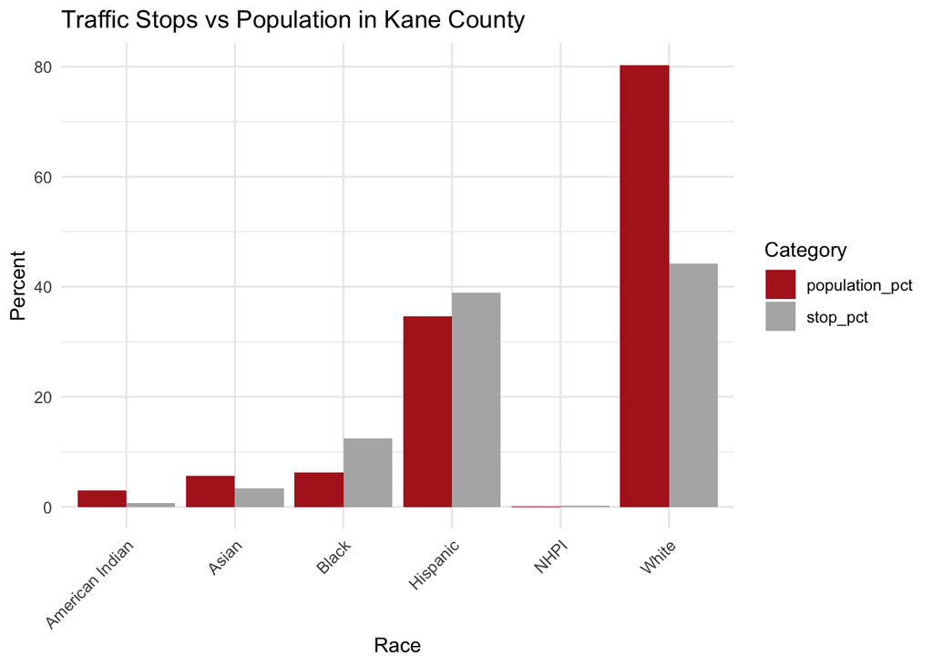

```r
## graphing it
ggplot(kane_plot, aes(x = race, y = percent, fill = type)) +
  geom_col(position = "dodge") +
  scale_fill_manual(values = c(
    "stop_pct" = "grey70",
    "population_pct" = "#B22222"
  )) +
  labs(
    title = "Traffic Stops vs Population in Kane County",
    x = "Race",
    y = "Percent",
    fill = "Category"
  ) +
  theme_minimal() +
  theme(axis.text.x = element_text(angle = 45, hjust = 1))
```

```r
### creating a new data table that has the total number of stops by race and then getting the number of searches that was conducted, creating a rate by taking searches divided by total stops and multiplying by 100 to get a percentage
kane_search_rates <- kane_law |>
  group_by(race) |>
  summarise(
    total_stops = n(),
    searches = sum(vehicle_search_conducted == "Yes", na.rm = TRUE),
    search_rate = searches/ total_stops * 100
  )


kane_search_rates
```

```
## # A tibble: 6 × 4
##   race            total_stops searches search_rate
##   <chr>                 <int>    <int>       <dbl>
## 1 American Indian         668        9       1.35
## 2 Asian                  3143       25       0.795
## 3 Black                 11671      833       7.14
## 4 Hispanic              36426     1592       4.37
## 5 NHPI                    249        4       1.61
## 6 White                 41376      617       1.49
```

- Black drivers have the highest search rates (7.1), followed by Hispanic drivers (4.4) and then NHPI drivers (1.6), and than white drivers (1.5).

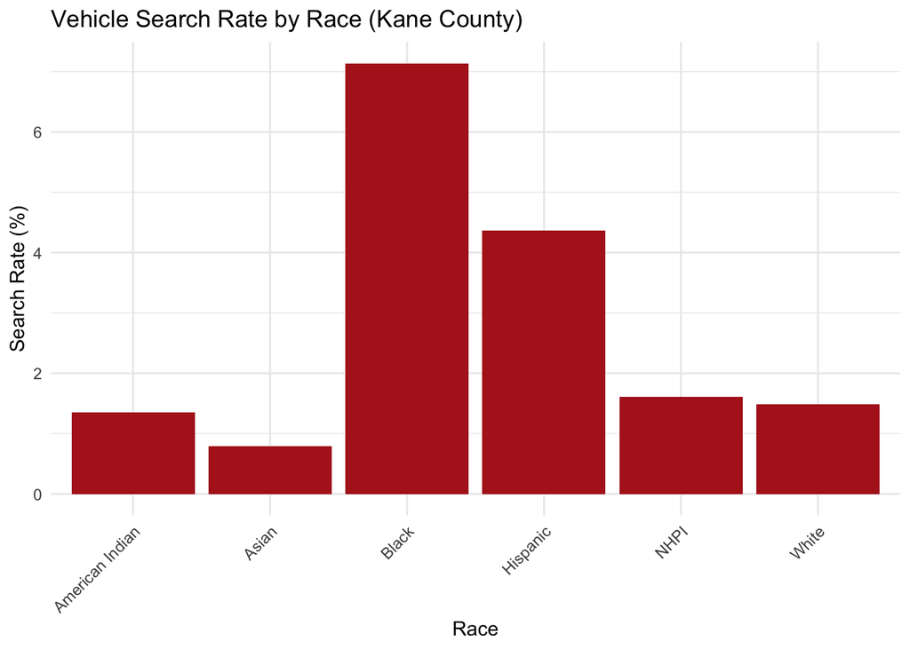

```r
ggplot(kane_search_rates, aes(x = race, y = search_rate)) +
  geom_col(fill = "#B22222") +
  labs(
    title = "Vehicle Search Rate by Race (Kane County)",
    x = "Race",
    y = "Search Rate (%)"
  ) +
  theme_minimal() +
  theme(axis.text.x = element_text(angle = 45, hjust = 1))
```

###### Top 3 Kane County Law Enforcment Agencies

- AURORA POLICE 17657
- ELGIN POLICE 10707
- GENEVA POLICE 7083

###### Aurora Police

```r
aurora_pop <- data.frame(
  race = c("White", "Black", "Hispanic", "Asian", "American Indian", "NHPI"),
  population_pct = c(36.7, 11, 41.6, 12.4, 1.5, 0.1)
)
```

```r
aurora_kane <- kane_law |>
  filter(agency_name == "AURORA POLICE") |>
  count(race) |>
  mutate(stop_pct = n/sum(n) * 100)

aurora_kane <- aurora_kane |>
  left_join(aurora_pop, by ="race")

aurora_kane
```

```
##               race     n   stop_pct population_pct
##             <char> <int>      <num>          <num>
## 1: American Indian   143  0.8098771            1.5
## 2:           Asian   622  3.5226822           12.4
## 3:           Black  3713 21.0284873           11.0
## 4:        Hispanic  8892 50.3596307           41.6
## 5:            NHPI    27  0.1529139            0.1
## 6:           White  4260 24.1264088           36.7
```

- Black, and Hispanic drivers are overrepresented in traffic stops relative to their share of the population, while White, Asian, and American Indian drivers are underrepresented.

```r
## graphing it
aurora_kane_plot <- aurora_kane %>%
  select(race, stop_pct, population_pct) %>%
  pivot_longer(
    cols = c(stop_pct, population_pct),
    names_to = "type",
    values_to = "percent"
  )
```

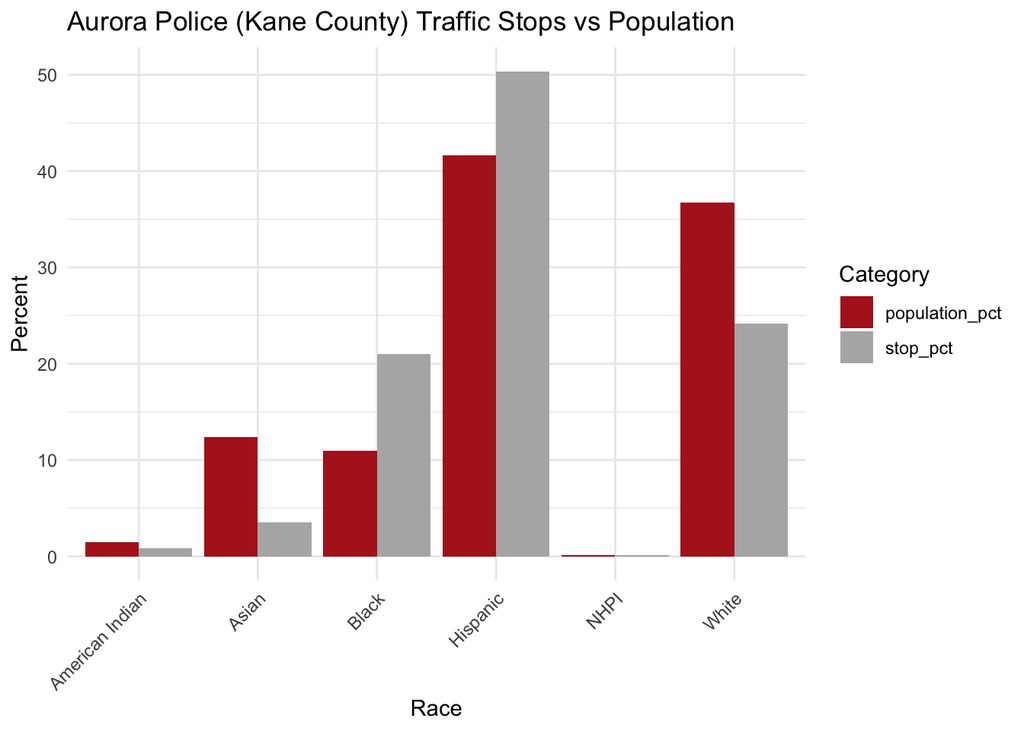

```r
## graphing it
ggplot(aurora_kane_plot, aes(x = race, y = percent, fill = type)) +
  geom_col(position = "dodge") +
  scale_fill_manual(values = c(
    "stop_pct" = "grey70",
    "population_pct" = "#B22222"
  )) +
  labs(
    title = "Aurora Police (Kane County) Traffic Stops vs Population",
    x = "Race",
    y = "Percent",
    fill = "Category"
  ) +
  theme_minimal() +
  theme(axis.text.x = element_text(angle = 45, hjust = 1))
```

```r
### creating a new data table that has the total number of stops by race and then getting the number of searches that was conducted, creating a rate by taking searches divided by total stops and multiplying by 100 to get a percentage
aurora_kane_search_rates <- kane_law |>
  filter(agency_name == "AURORA POLICE") |>
  group_by(race) |>
  summarise(
    total_stops = n(),
    searches = sum(vehicle_search_conducted == "Yes", na.rm = TRUE),
    search_rate = searches/ total_stops * 100
  )

aurora_kane_search_rates
```

```
## # A tibble: 6 × 4
##   race            total_stops searches search_rate
##   <chr>                 <int>    <int>       <dbl>
## 1 American Indian         143        1       0.699
## 2 Asian                   622        7       1.13
## 3 Black                  3713      392      10.6
## 4 Hispanic               8892      560       6.30
## 5 NHPI                     27        0       0
## 6 White                  4260      183       4.30
```

- Black drivers have the highest search rates (10.6), followed by Hispanic drivers (6.3) and then white drivers (4.3).

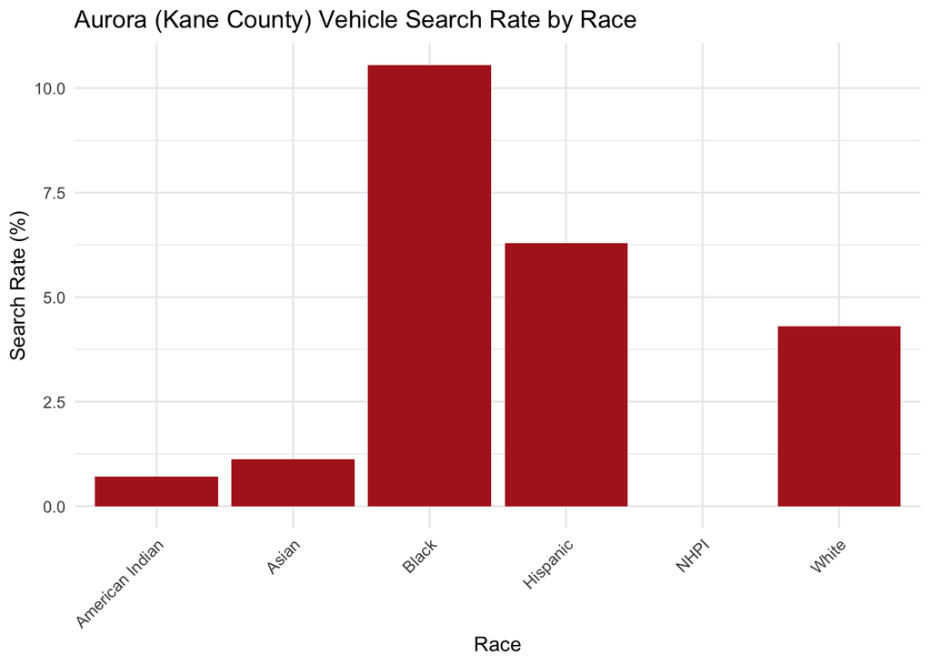

```r
ggplot(aurora_kane_search_rates, aes(x = race, y = search_rate)) +
  geom_col(fill = "#B22222") +
  labs(
    title = "Aurora (Kane County) Vehicle Search Rate by Race",
    x = "Race",
    y = "Search Rate (%)"
  ) +
  theme_minimal() +
  theme(axis.text.x = element_text(angle = 45, hjust = 1))
```

###### Elgin Police

```r
elgin_pop <- data.frame(
  race = c("White", "Black", "Hispanic", "Asian", "American Indian", "NHPI"),
  population_pct = c(40.6, 5.4, 48.7, 6.7, 2.3, 0.2)
)
```

```r
elgin_kane <- kane_law |>
  filter(agency_name == "ELGIN POLICE") |>
  count(race) |>
  mutate(stop_pct = n/sum(n) * 100)

elgin_kane <- elgin_kane |>
  left_join(elgin_pop, by ="race")
elgin_kane
```

```
##               race     n   stop_pct population_pct
##             <char> <int>      <num>          <num>
## 1: American Indian    38  0.3549080            2.3
## 2:           Asian   341  3.1848324            6.7
## 3:           Black  1396 13.0381993            5.4
## 4:        Hispanic  5717 53.3949752           48.7
## 5:            NHPI    34  0.3175493            0.2
## 6:           White  3181 29.7095358           40.6
```

- Black and Hispanic drivers are overrepresented in traffic stops relative to their share of the population, while White and Asian drivers are underrepresented.

```r
## graphing it
elgin_kane_plot <- elgin_kane %>%
  select(race, stop_pct, population_pct) %>%
  pivot_longer(
    cols = c(stop_pct, population_pct),
    names_to = "type",
    values_to = "percent"
  )
```

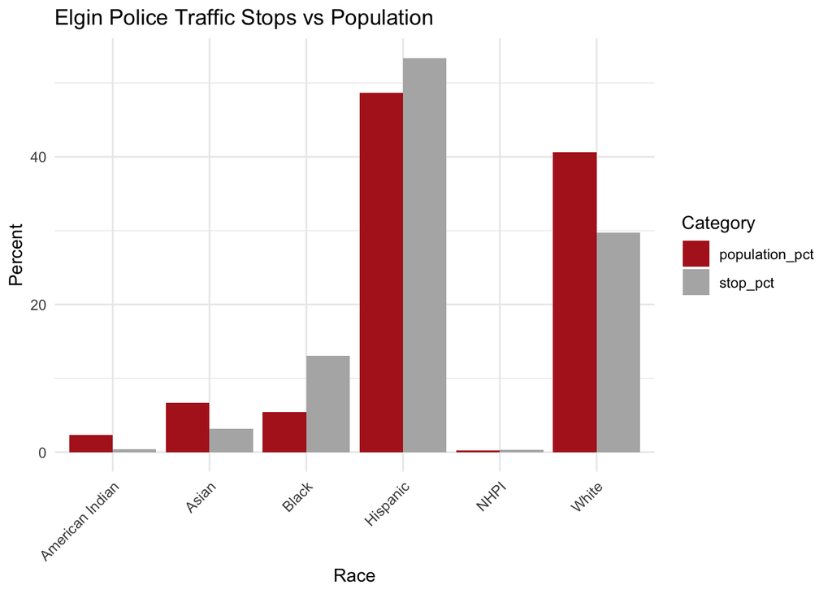

```r
## graphing it
ggplot(elgin_kane_plot, aes(x = race, y = percent, fill = type)) +
  geom_col(position = "dodge") +
  scale_fill_manual(values = c(
    "stop_pct" = "grey70",
    "population_pct" = "#B22222"
  )) +
  labs(
    title = "Elgin Police Traffic Stops vs Population",
    x = "Race",
    y = "Percent",
    fill = "Category"
  ) +
  theme_minimal() +
  theme(axis.text.x = element_text(angle = 45, hjust = 1))
```

```r
### creating a new data table that has the total number of stops by race and then getting the number of searches that was conducted, creating a rate by taking searches divided by total stops and multiplying by 100 to get a percentage
elgin_search_rates <- kane_law |>
  filter(agency_name == "ELGIN POLICE") |>
  group_by(race) |>
  summarise(
    total_stops = n(),
    searches = sum(vehicle_search_conducted == "Yes", na.rm = TRUE),
    search_rate = searches/ total_stops * 100
  )

elgin_search_rates
```

```
## # A tibble: 6 × 4
##   race            total_stops searches search_rate
##   <chr>                 <int>    <int>       <dbl>
## 1 American Indian          38        0        0
## 2 Asian                   341        6        1.76
## 3 Black                  1396      152       10.9
## 4 Hispanic               5717      409        7.15
## 5 NHPI                     34        1        2.94
## 6 White                  3181       97        3.05
```

- Black drivers have the highest search rates (10.8), followed by Hispanic drivers (7.2) and then white drivers (3).

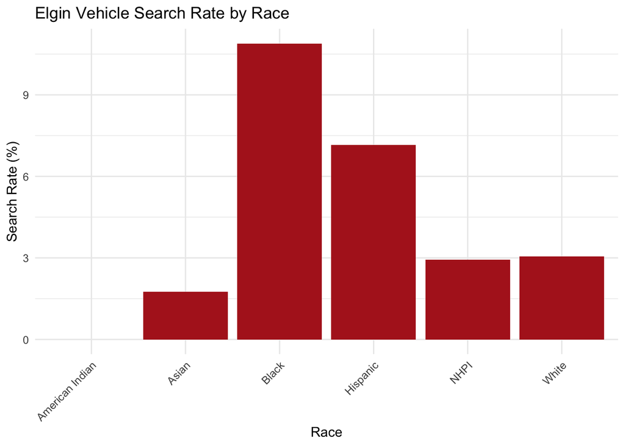

```r
ggplot(elgin_search_rates, aes(x = race, y = search_rate)) +
  geom_col(fill = "#B22222") +
  labs(
    title = "Elgin Vehicle Search Rate by Race",
    x = "Race",
    y = "Search Rate (%)"
  ) +
  theme_minimal() +
  theme(axis.text.x = element_text(angle = 45, hjust = 1))
```

###### Geneva Police

```r
geneva_pop <- data.frame(
  race = c("White", "Black", "Hispanic", "Asian", "American Indian", "NHPI"),
  population_pct = c(84.6, 1.5, 7.5, 2.5, 0.3, 0)
)
```

```r
geneva_kane <- kane_law |>
  filter(agency_name == "GENEVA POLICE") |>
  count(race) |>
  mutate(stop_pct = n/sum(n) * 100)

geneva_kane <- geneva_kane |>
  left_join(geneva_pop, by ="race")

geneva_kane
```

```
##               race     n   stop_pct population_pct
##             <char> <int>      <num>          <num>
## 1: American Indian    10  0.1411831            0.3
## 2:           Asian   198  2.7954257            2.5
## 3:           Black   467  6.5932514            1.5
## 4:        Hispanic  1486 20.9798108            7.5
## 5:            NHPI    32  0.4517860            0.0
## 6:           White  4890 69.0385430           84.6
```

- Black, Hispanic, Asian, and NHPI drivers are overrepresented in traffic stops relative to their share of the population, while White and American Indian drivers are underrepresented.

```r
## graphing it
geneva_kane_plot <- geneva_kane %>%
  select(race, stop_pct, population_pct) %>%
  pivot_longer(
    cols = c(stop_pct, population_pct),
    names_to = "type",
    values_to = "percent"
  )
```

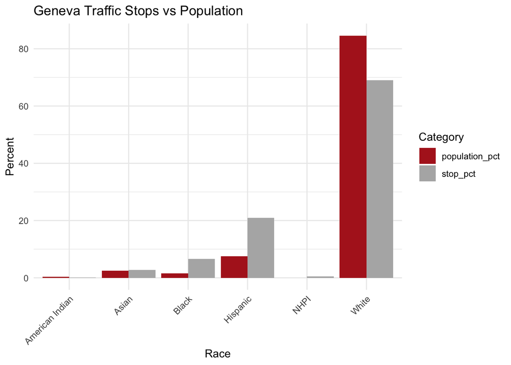

```r
## graphing it
ggplot(geneva_kane_plot, aes(x = race, y = percent, fill = type)) +
  geom_col(position = "dodge") +
  scale_fill_manual(values = c(
    "stop_pct" = "grey70",
    "population_pct" = "#B22222"
  )) +
  labs(
    title = "Geneva Traffic Stops vs Population",
    x = "Race",
    y = "Percent",
    fill = "Category"
  ) +
  theme_minimal() +
  theme(axis.text.x = element_text(angle = 45, hjust = 1))
```

```r
### creating a new data table that has the total number of stops by race and then getting the number of searches that was conducted, creating a rate by taking searches divided by total stops and multiplying by 100 to get a percentage
geneva_kane_search_rates <- kane_law |>
  filter(agency_name == "GENEVA POLICE") |>
  group_by(race) |>
  summarise(
    total_stops = n(),
    searches = sum(vehicle_search_conducted == "Yes", na.rm = TRUE),
    search_rate = searches/ total_stops * 100
  )

geneva_kane_search_rates
```

```
## # A tibble: 6 × 4
##   race            total_stops searches search_rate
##   <chr>                 <int>    <int>       <dbl>
## 1 American Indian          10        0      0
## 2 Asian                   198        0      0
## 3 Black                   467        4      0.857
## 4 Hispanic               1486        6      0.404
## 5 NHPI                     32        0      0
## 6 White                  4890        3      0.0613
```

- Black drivers have the highest search rates (0.9), followed by Hispanic drivers (0.4) and then white drivers (0.06).

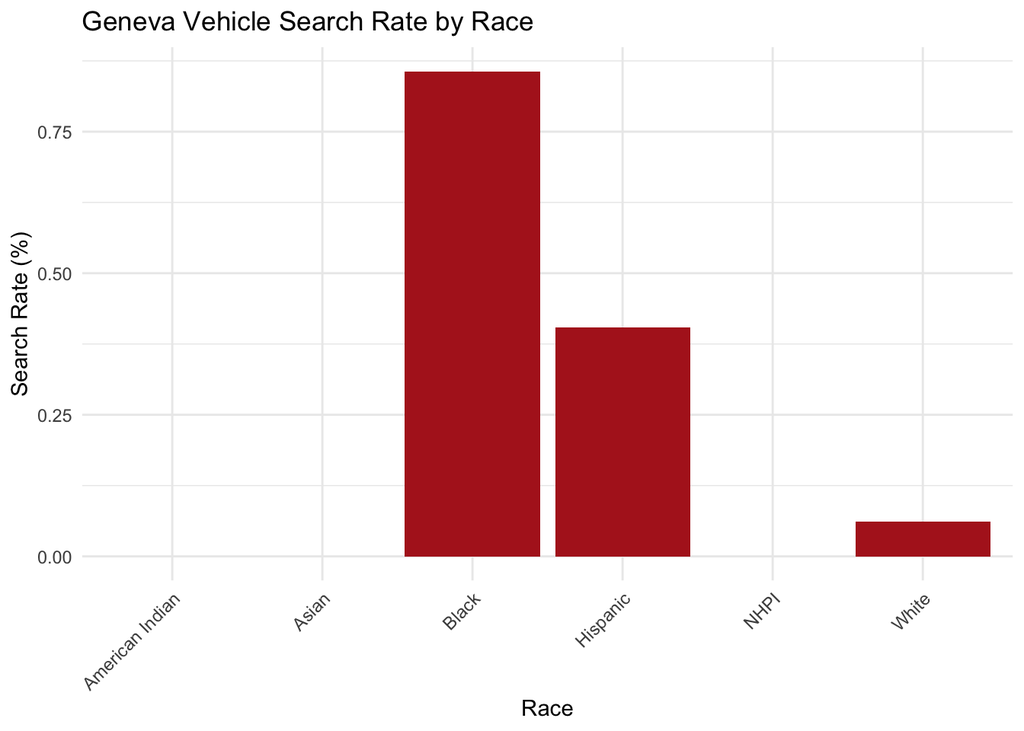

```r
ggplot(geneva_kane_search_rates, aes(x = race, y = search_rate)) +
  geom_col(fill = "#B22222") +
  labs(
    title = "Geneva Vehicle Search Rate by Race",
    x = "Race",
    y = "Search Rate (%)"
  ) +
  theme_minimal() +
  theme(axis.text.x = element_text(angle = 45, hjust = 1))
```

###### Kane County Sheriff

```r
kane_pop <- data.frame(
  race = c("White", "Black", "Hispanic", "Asian", "American Indian", "NHPI"),
  population_pct = c(52.6, 6.3, 34.6, 5.6, 3.8, 0.1)
)
```

```r
kanecounty_kane <- kane_law |>
  filter(agency_name == "KANE COUNTY SHERIFF") |>
  count(race) |>
  mutate(stop_pct = n/sum(n) * 100)

kanecounty_kane <- kanecounty_kane |>
  left_join(kane_pop, by ="race")

kanecounty_kane
```

```
##               race     n   stop_pct population_pct
##             <char> <int>      <num>          <num>
## 1: American Indian    87  1.2942577            3.8
## 2:           Asian   159  2.3653675            5.6
## 3:           Black   890 13.2401071            6.3
## 4:        Hispanic  2513 37.3847069           34.6
## 5:            NHPI    23  0.3421601            0.1
## 6:           White  3050 45.3734008           52.6
```

```r
kanecounty_kane_search_rates <- kane_law |>
  filter(agency_name == "KANE COUNTY SHERIFF") |>
  group_by(race) |>
  summarise(
    total_stops = n(),
    searches = sum(vehicle_search_conducted == "Yes", na.rm = TRUE),
    search_rate = searches/ total_stops * 100
  )

kanecounty_kane_search_rates
```

```
## # A tibble: 6 × 4
##   race            total_stops searches search_rate
##   <chr>                 <int>    <int>       <dbl>
## 1 American Indian          87        2        2.30
## 2 Asian                   159        0        0
## 3 Black                   890       77        8.65
## 4 Hispanic               2513      107        4.26
## 5 NHPI                     23        0        0
## 6 White                  3050       58        1.90
```

###### South Elgin Police

```r
southelgin_pop <- data.frame(
  race = c("White", "Black", "Hispanic", "Asian", "American Indian", "NHPI"),
  population_pct = c(57.4, 4.7, 20.3, 10.9, 0.6, 0.6)
)
```

```r
southelgin_kane <- kane_law |>
  filter(agency_name == "SOUTH ELGIN POLICE") |>
  count(race) |>
  mutate(stop_pct = n/sum(n) * 100)

southelgin_kane <- southelgin_kane |>
  left_join(southelgin_pop, by ="race")

southelgin_kane
```

```
##               race     n   stop_pct population_pct
##             <char> <int>      <num>          <num>
## 1: American Indian    39  0.6484869            0.6
## 2:           Asian   408  6.7841703           10.9
## 3:           Black   564  9.3781177            4.7
## 4:        Hispanic  2094 34.8187562           20.3
## 5:            NHPI    15  0.2494180            0.6
## 6:           White  2894 48.1210509           57.4
```

```r
southelgin_kane_search_rates <- kane_law |>
  filter(agency_name == "SOUTH ELGIN POLICE") |>
  group_by(race) |>
  summarise(
    total_stops = n(),
    searches = sum(vehicle_search_conducted == "Yes", na.rm = TRUE),
    search_rate = searches/ total_stops * 100
  )

southelgin_kane_search_rates
```

```
## # A tibble: 6 × 4
##   race            total_stops searches search_rate
##   <chr>                 <int>    <int>       <dbl>
## 1 American Indian          39        0       0
## 2 Asian                   408        1       0.245
## 3 Black                   564        1       0.177
## 4 Hispanic               2094        4       0.191
## 5 NHPI                     15        0       0
## 6 White                  2894        3       0.104
```

###### Carpentersville Police

```r
carpentersville_pop <- data.frame(
  race = c("White", "Black", "Hispanic", "Asian", "American Indian", "NHPI"),
  population_pct = c(30, 5.1, 57.4, 4.1, 1.4, 0.1)
)
```

```r
carpentersville_kane <- kane_law |>
  filter(agency_name == "CARPENTERSVILLE POLICE") |>
  count(race) |>
  mutate(stop_pct = n/sum(n) * 100)

carpentersville_kane <- carpentersville_kane |>
  left_join(carpentersville_pop, by ="race")

carpentersville_kane
```

```
##               race     n   stop_pct population_pct
##             <char> <int>      <num>          <num>
## 1: American Indian    53  0.9762387            1.4
## 2:           Asian    74  1.3630503            4.1
## 3:           Black   445  8.1967213            5.1
## 4:        Hispanic  3199 58.9242955           57.4
## 5:            NHPI     8  0.1473568            0.1
## 6:           White  1650 30.3923374           30.0
```

```r
carpentersville_kane_search_rates <- kane_law |>
  filter(agency_name == "CARPENTERSVILLE POLICE") |>
  group_by(race) |>
  summarise(
    total_stops = n(),
    searches = sum(vehicle_search_conducted == "Yes", na.rm = TRUE),
    search_rate = searches/ total_stops * 100
  )

carpentersville_kane_search_rates
```

```
## # A tibble: 6 × 4
##   race            total_stops searches search_rate
##   <chr>                 <int>    <int>       <dbl>
## 1 American Indian          53        3        5.66
## 2 Asian                    74        1        1.35
## 3 Black                   445       39        8.76
## 4 Hispanic               3199      196        6.13
## 5 NHPI                      8        0        0
## 6 White                  1650       35        2.12
```

###### Algonquin Police

```r
algonquin_pop <- data.frame(
  race = c("White", "Black", "Hispanic", "Asian", "American Indian", "NHPI"),
  population_pct = c(72.7, 2.8, 15.6, 5.3, 0.8, 0)
)
```

```r
algonquin_kane <- kane_law |>
  filter(agency_name == "ALGONQUIN POLICE") |>
  count(race) |>
  mutate(stop_pct = n/sum(n) * 100)

algonquin_kane <- algonquin_kane |>
  left_join(algonquin_pop, by ="race")

algonquin_kane
```

```
##               race     n    stop_pct population_pct
##             <char> <int>       <num>          <num>
## 1: American Indian   151  2.84798189            0.8
## 2:           Asian    88  1.65975104            5.3
## 3:           Black   297  5.60165975            2.8
## 4:        Hispanic  1140 21.50132026           15.6
## 5:            NHPI     3  0.05658242            0.0
## 6:           White  3623 68.33270464           72.7
```

```r
algonquin_kane_search_rates <- kane_law |>
  filter(agency_name == "ALGONQUIN POLICE") |>
  group_by(race) |>
  summarise(
    total_stops = n(),
    searches = sum(vehicle_search_conducted == "Yes", na.rm = TRUE),
    search_rate = searches/ total_stops * 100
  )

algonquin_kane_search_rates
```

```
## # A tibble: 6 × 4
##   race            total_stops searches search_rate
##   <chr>                 <int>    <int>       <dbl>
## 1 American Indian         151        0       0
## 2 Asian                    88        0       0
## 3 Black                   297        3       1.01
## 4 Hispanic               1140        7       0.614
## 5 NHPI                      3        0       0
## 6 White                  3623       18       0.497
```

###### St.Charles Police

```r
stcharles_pop <- data.frame(
  race = c("White", "Black", "Hispanic", "Asian", "American Indian", "NHPI"),
  population_pct = c(74.7, 2.9, 12.3, 5, 1.1, 0)
)
```

```r
stcharles_kane <- kane_law |>
  filter(agency_name == "ST. CHARLES POLICE") |>
  count(race) |>
  mutate(stop_pct = n/sum(n) * 100)

stcharles_kane <- stcharles_kane |>
  left_join(stcharles_pop, by ="race")

stcharles_kane
```

```
##               race     n   stop_pct population_pct
##             <char> <int>      <num>          <num>
## 1: American Indian    11  0.2295492            1.1
## 2:           Asian   241  5.0292154            5.0
## 3:           Black   371  7.7420701            2.9
## 4:        Hispanic  1246 26.0016694           12.3
## 5:            NHPI     6  0.1252087            0.0
## 6:           White  2917 60.8722871           74.7
```

```r
stcharles_kane_search_rates <- kane_law |>
  filter(agency_name == "ST. CHARLES POLICE") |>
  group_by(race) |>
  summarise(
    total_stops = n(),
    searches = sum(vehicle_search_conducted == "Yes", na.rm = TRUE),
    search_rate = searches/ total_stops * 100
  )

stcharles_kane_search_rates
```

```
## # A tibble: 6 × 4
##   race            total_stops searches search_rate
##   <chr>                 <int>    <int>       <dbl>
## 1 American Indian          11        0       0
## 2 Asian                   241        1       0.415
## 3 Black                   371       23       6.20
## 4 Hispanic               1246       42       3.37
## 5 NHPI                      6        0       0
## 6 White                  2917       37       1.27
```

###### Batavia Police

```r
batavia_pop <- data.frame(
  race = c("White", "Black", "Hispanic", "Asian", "American Indian", "NHPI"),
  population_pct = c(81.8, 2.5, 8.9, 1.7, 0.2, 0)
)
```

```r
batavia_kane <- kane_law |>
  filter(agency_name == "BATAVIA POLICE") |>
  count(race) |>
  mutate(stop_pct = n/sum(n) * 100)

batavia_kane <- batavia_kane |>
  left_join(batavia_pop, by ="race")

batavia_kane
```

```
##               race     n    stop_pct population_pct
##             <char> <int>       <num>          <num>
## 1: American Indian     9  0.19292605            0.2
## 2:           Asian   205  4.39442658            1.7
## 3:           Black   519 11.12540193            2.5
## 4:        Hispanic  1474 31.59699893            8.9
## 5:            NHPI     2  0.04287245            0.0
## 6:           White  2456 52.64737406           81.8
```

```r
batavia_kane_search_rates <- kane_law |>
  filter(agency_name == "BATAVIA POLICE") |>
  group_by(race) |>
  summarise(
    total_stops = n(),
    searches = sum(vehicle_search_conducted == "Yes", na.rm = TRUE),
    search_rate = searches/ total_stops * 100
  )

batavia_kane_search_rates
```

```
## # A tibble: 6 × 4
##   race            total_stops searches search_rate
##   <chr>                 <int>    <int>       <dbl>
## 1 American Indian           9        0       0
## 2 Asian                   205        0       0
## 3 Black                   519        2       0.385
## 4 Hispanic               1474       17       1.15
## 5 NHPI                      2        0       0
## 6 White                  2456       11       0.448
```

###### Montgomery Police

```r
montgomery_pop <- data.frame(
  race = c("White", "Black", "Hispanic", "Asian", "American Indian", "NHPI"),
  population_pct = c(53.8, 8, 32.1, 2.3, 0.6, 0)
)
```

```r
montgomery_kane <- kane_law |>
  filter(agency_name == "MONTGOMERY POLICE") |>
  count(race) |>
  mutate(stop_pct = n/sum(n) * 100)

montgomery_kane <- montgomery_kane |>
  left_join(montgomery_pop, by ="race")

montgomery_kane
```

```
##               race     n   stop_pct population_pct
##             <char> <int>      <num>          <num>
## 1: American Indian    11  0.2370179            0.6
## 2:           Asian    81  1.7453135            2.3
## 3:           Black   817 17.6039647            8.0
## 4:        Hispanic  1980 42.6632191           32.1
## 5:            NHPI    11  0.2370179            0.0
## 6:           White  1741 37.5134669           53.8
```

```r
montgomery_kane_search_rates <- kane_law |>
  filter(agency_name == "MONTGOMERY POLICE") |>
  group_by(race) |>
  summarise(
    total_stops = n(),
    searches = sum(vehicle_search_conducted == "Yes", na.rm = TRUE),
    search_rate = searches/ total_stops * 100
  )

montgomery_kane_search_rates
```

```
## # A tibble: 6 × 4
##   race            total_stops searches search_rate
##   <chr>                 <int>    <int>       <dbl>
## 1 American Indian          11        1        9.09
## 2 Asian                    81        1        1.23
## 3 Black                   817       28        3.43
## 4 Hispanic               1980       62        3.13
## 5 NHPI                     11        0        0
## 6 White                  1741       35        2.01
```

###### North Aurora Police

```r
northaurora_pop <- data.frame(
  race = c("White", "Black", "Hispanic", "Asian", "American Indian", "NHPI"),
  population_pct = c(66.8, 8.7, 20.5, 1.9, 0.2, 0)
)
```

```r
northaurora_kane <- kane_law |>
  filter(agency_name == "NORTH AURORA POLICE") |>
  count(race) |>
  mutate(stop_pct = n/sum(n) * 100)

northaurora_kane <- northaurora_kane |>
  left_join(northaurora_pop, by ="race")

northaurora_kane
```

```
##               race     n   stop_pct population_pct
##             <char> <int>      <num>          <num>
## 1: American Indian    24  0.5284016            0.2
## 2:           Asian   139  3.0603258            1.9
## 3:           Black   710 15.6318802            8.7
## 4:        Hispanic  2091 46.0369881           20.5
## 5:            NHPI    39  0.8586526            0.0
## 6:           White  1539 33.8837517           66.8
```

```r
northaurora_kane_search_rates <- kane_law |>
  filter(agency_name == "NORTH AURORA POLICE") |>
  group_by(race) |>
  summarise(
    total_stops = n(),
    searches = sum(vehicle_search_conducted == "Yes", na.rm = TRUE),
    search_rate = searches/ total_stops * 100
  )

northaurora_kane_search_rates
```

```
## # A tibble: 6 × 4
##   race            total_stops searches search_rate
##   <chr>                 <int>    <int>       <dbl>
## 1 American Indian          24        0        0
## 2 Asian                   139        2        1.44
## 3 Black                   710       31        4.37
## 4 Hispanic               2091       49        2.34
## 5 NHPI                     39        1        2.56
## 6 White                  1539       23        1.49
```

###### Huntley Police

```r
huntley_pop <- data.frame(
  race = c("White", "Black", "Hispanic", "Asian", "American Indian", "NHPI"),
  population_pct = c(77.8, 4.2, 11.1, 5.1, 0.2, 0)
)
```

```r
huntley_kane <- kane_law |>
  filter(agency_name == "HUNTLEY POLICE") |>
  count(race) |>
  mutate(stop_pct = n/sum(n) * 100)

huntley_kane <- huntley_kane |>
  left_join(huntley_pop, by ="race")

huntley_kane
```

```
##               race     n   stop_pct population_pct
##             <char> <int>      <num>          <num>
## 1: American Indian     5  0.1163603            0.2
## 2:           Asian   198  4.6078660            5.1
## 3:           Black   344  8.0055853            4.2
## 4:        Hispanic   735 17.1049569           11.1
## 5:            NHPI     7  0.1629044            0.0
## 6:           White  3008 70.0023272           77.8
```

```r
huntley_kane_search_rates <- kane_law |>
  filter(agency_name == "HUNTLEY POLICE") |>
  group_by(race) |>
  summarise(
    total_stops = n(),
    searches = sum(vehicle_search_conducted == "Yes", na.rm = TRUE),
    search_rate = searches/ total_stops * 100
  )

huntley_kane_search_rates
```

```
## # A tibble: 6 × 4
##   race            total_stops searches search_rate
##   <chr>                 <int>    <int>       <dbl>
## 1 American Indian           5        0       0
## 2 Asian                   198        1       0.505
## 3 Black                   344       16       4.65
## 4 Hispanic                735       20       2.72
## 5 NHPI                      7        0       0
## 6 White                  3008       25       0.831
```

###### Elburn Police

```r
elburn_pop <- data.frame(
  race = c("White", "Black", "Hispanic", "Asian", "American Indian", "NHPI"),
  population_pct = c(86.2, 0, 10.9, 2.6, 0, 0)
)
```

```r
elburn_kane <- kane_law |>
  filter(agency_name == "ELBURN POLICE") |>
  count(race) |>
  mutate(stop_pct = n/sum(n) * 100)

elburn_kane <- elburn_kane |>
  left_join(elburn_pop, by ="race")

elburn_kane
```

```
##               race     n    stop_pct population_pct
##             <char> <int>       <num>          <num>
## 1: American Indian     1  0.03843198            0.0
## 2:           Asian   106  4.07378939            2.6
## 3:           Black   217  8.33973866            0.0
## 4:        Hispanic   537 20.63797079           10.9
## 5:            NHPI     6  0.23059185            0.0
## 6:           White  1735 66.67947733           86.2
```

```r
elburn_kane_search_rates <- kane_law |>
  filter(agency_name == "ELBURN POLICE") |>
  group_by(race) |>
  summarise(
    total_stops = n(),
    searches = sum(vehicle_search_conducted == "Yes", na.rm = TRUE),
    search_rate = searches/ total_stops * 100
  )

elburn_kane_search_rates
```

```
## # A tibble: 6 × 4
##   race            total_stops searches search_rate
##   <chr>                 <int>    <int>       <dbl>
## 1 American Indian           1        0        0
## 2 Asian                   106        3        2.83
## 3 Black                   217       23       10.6
## 4 Hispanic                537       33        6.15
## 5 NHPI                      6        0        0
## 6 White                  1735       35        2.02
```

###### East Dundee Police

```r
eastdundee_pop <- data.frame(
  race = c("White", "Black", "Hispanic", "Asian", "American Indian", "NHPI"),
  population_pct = c(68.6, 7.12, 6.2, 2.13, 0, 0)
)
```

```r
eastdundee_kane <- kane_law |>
  filter(agency_name == "EAST DUNDEE POLICE") |>
  count(race) |>
  mutate(stop_pct = n/sum(n) * 100)

eastdundee_kane <- eastdundee_kane |>
  left_join(eastdundee_pop, by ="race")

eastdundee_kane
```

```
##               race     n   stop_pct population_pct
##             <char> <int>      <num>          <num>
## 1: American Indian    39  1.7972350           0.00
## 2:           Asian    32  1.4746544           2.13
## 3:           Black   211  9.7235023           7.12
## 4:        Hispanic  1151 53.0414747           6.20
## 5:            NHPI     7  0.3225806           0.00
## 6:           White   730 33.6405530          68.60
```

```r
eastdundee_kane_search_rates <- kane_law |>
  filter(agency_name == "EAST DUNDEE POLICE") |>
  group_by(race) |>
  summarise(
    total_stops = n(),
    searches = sum(vehicle_search_conducted == "Yes", na.rm = TRUE),
    search_rate = searches/ total_stops * 100
  )

eastdundee_kane_search_rates
```

```
## # A tibble: 6 × 4
##   race            total_stops searches search_rate
##   <chr>                 <int>    <int>       <dbl>
## 1 American Indian          39        1        2.56
## 2 Asian                    32        0        0
## 3 Black                   211        5        2.37
## 4 Hispanic               1151       27        2.35
## 5 NHPI                      7        0        0
## 6 White                   730       15        2.05
```

###### Sugar Grove Police

```r
sugargrove_pop <- data.frame(
  race = c("White", "Black", "Hispanic", "Asian", "American Indian", "NHPI"),
  population_pct = c(87.7, 0.5, 6.4, 2.7, 0.1, 0)
)
```

```r
sugargrove_kane <- kane_law |>
  filter(agency_name == "SUGAR GROVE POLICE") |>
  count(race) |>
  mutate(stop_pct = n/sum(n) * 100)

sugargrove_kane <- sugargrove_kane |>
  left_join(sugargrove_pop, by ="race")

sugargrove_kane
```

```
##               race     n   stop_pct population_pct
##             <char> <int>      <num>          <num>
## 1: American Indian     5  0.2497502            0.1
## 2:           Asian    66  3.2967033            2.7
## 3:           Black   268 13.3866134            0.5
## 4:        Hispanic   564 28.1718282            6.4
## 5:            NHPI    11  0.5494505            0.0
## 6:           White  1088 54.3456543           87.7
```

```r
sugargrove_kane_search_rates <- kane_law |>
  filter(agency_name == "SUGAR GROVE POLICE") |>
  group_by(race) |>
  summarise(
    total_stops = n(),
    searches = sum(vehicle_search_conducted == "Yes", na.rm = TRUE),
    search_rate = searches/ total_stops * 100
  )

sugargrove_kane_search_rates
```

```
## # A tibble: 6 × 4
##   race            total_stops searches search_rate
##   <chr>                 <int>    <int>       <dbl>
## 1 American Indian           5        0        0
## 2 Asian                    66        2        3.03
## 3 Black                   268       30       11.2
## 4 Hispanic                564       44        7.80
## 5 NHPI                     11        1        9.09
## 6 White                  1088       35        3.22
```

###### Hampshire Police

```r
hampshire_pop <- data.frame(
  race = c("White", "Black", "Hispanic", "Asian", "American Indian", "NHPI"),
  population_pct = c(74.6, 0.1, 14.6, 7.1, 0, 0)
)
```

```r
hampshire_kane <- kane_law |>
  filter(agency_name == "HAMPSHIRE POLICE") |>
  count(race) |>
  mutate(stop_pct = n/sum(n) * 100)

hampshire_kane <- hampshire_kane |>
  left_join(hampshire_pop, by ="race")

hampshire_kane
```

```
##        race     n   stop_pct population_pct
##      <char> <int>      <num>          <num>
## 1:    Asian    40  3.3030553            7.1
## 2:    Black    89  7.3492981            0.1
## 3: Hispanic   307 25.3509496           14.6
## 4:     NHPI     5  0.4128819            0.0
## 5:    White   770 63.5838150           74.6
```

```r
hampshire_kane_search_rates <- kane_law |>
  filter(agency_name == "HAMPSHIRE POLICE") |>
  group_by(race) |>
  summarise(
    total_stops = n(),
    searches = sum(vehicle_search_conducted == "Yes", na.rm = TRUE),
    search_rate = searches/ total_stops * 100
  )

hampshire_kane_search_rates
```

```
## # A tibble: 5 × 4
##   race     total_stops searches search_rate
##   <chr>          <int>    <int>       <dbl>
## 1 Asian             40        0           0
## 2 Black             89        0           0
## 3 Hispanic         307        0           0
## 4 NHPI               5        0           0
## 5 White            770        0           0
```

###### West Dundee Police

```r
westdundee_pop <- data.frame(
  race = c("White", "Black", "Hispanic", "Asian", "American Indian", "NHPI"),
  population_pct = c(77.8, 3, 11.3, 5.8, 0.5, 0)
)
```

```r
westdundee_kane <- kane_law |>
  filter(agency_name == "WEST DUNDEE POLICE") |>
  count(race) |>
  mutate(stop_pct = n/sum(n) * 100)

westdundee_kane <- westdundee_kane |>
  left_join(westdundee_pop, by ="race")

westdundee_kane
```

```
##               race     n   stop_pct population_pct
##             <char> <int>      <num>          <num>
## 1: American Indian    34  2.8887001            0.5
## 2:           Asian    34  2.8887001            5.8
## 3:           Black   151 12.8292268            3.0
## 4:        Hispanic   501 42.5658454           11.3
## 5:            NHPI     2  0.1699235            0.0
## 6:           White   455 38.6576041           77.8
```

```r
westdundee_kane_search_rates <- kane_law |>
  filter(agency_name == "WEST DUNDEE POLICE") |>
  group_by(race) |>
  summarise(
    total_stops = n(),
    searches = sum(vehicle_search_conducted == "Yes", na.rm = TRUE),
    search_rate = searches/ total_stops * 100
  )

westdundee_kane_search_rates
```

```
## # A tibble: 6 × 4
##   race            total_stops searches search_rate
##   <chr>                 <int>    <int>       <dbl>
## 1 American Indian          34        0       0
## 2 Asian                    34        0       0
## 3 Black                   151        6       3.97
## 4 Hispanic                501        5       0.998
## 5 NHPI                      2        0       0
## 6 White                   455        1       0.220
```

##### McHenry County

```r
mchenry_agencies <- toupper(c(
  "Algonquin Police",
  "Barrington Hills Police",
  "Bull Valle Policey",
  "Cary Police",
  "Crystal Lake Police",
  "Fox Lake Police",
  "Fox River Grove Police",
  "Harvard Police",
  "Hebron Police",
  "Holiday Hills Police",
  "Huntley Police",
  "Island Lake Police",
  "Johnsburg Police",
  "Lake in the Hills Police",
  "Lakemoor Police",
  "Marengo Police",
  "McHenry Police",
  "McHenry County Sheriff",
  "McHenry County Conservation District Police",
  "McHenry County College Police",
  "Oakwood Hills Police",
  "Prairie Grove Police",
  "Richmond Police",
  "Ringwood Police",
  "Spring Grove Police",
  "Wonder Lake Police",
  "Woodstock Police"
))
```

```r
mchenry_law <- traffic_24 %>%
  mutate(agency_name = str_squish(agency_name)) %>%
  filter(agency_name %in% mchenry_agencies)
```

```r
mchenry_law %>%
  count(agency_name, sort = TRUE)
```

```
##                                     agency_name     n
##                                          <char> <int>
##  1:                         CRYSTAL LAKE POLICE  8676
##  2:                      MCHENRY COUNTY SHERIFF  8232
##  3:                              MCHENRY POLICE  6666
##  4:                    LAKE IN THE HILLS POLICE  5409
##  5:                            ALGONQUIN POLICE  5302
##  6:                            WOODSTOCK POLICE  5112
##  7:                              HUNTLEY POLICE  4297
##  8:                          ISLAND LAKE POLICE  3865
##  9:                             FOX LAKE POLICE  3224
## 10:                                 CARY POLICE  3123
## 11:                     BARRINGTON HILLS POLICE  2538
## 12:                             LAKEMOOR POLICE  1659
## 13:                              MARENGO POLICE  1586
## 14:                              HARVARD POLICE  1379
## 15:                         SPRING GROVE POLICE  1376
## 16:                            JOHNSBURG POLICE   756
## 17:                             RICHMOND POLICE   648
## 18:                      FOX RIVER GROVE POLICE   558
## 19:                        PRAIRIE GROVE POLICE   206
## 20: MCHENRY COUNTY CONSERVATION DISTRICT POLICE   112
## 21:                        OAKWOOD HILLS POLICE    61
## 22:               MCHENRY COUNTY COLLEGE POLICE    39
##                                     agency_name     n
##                                          <char> <int>
```

```r
mchenry_pop <- data.frame(
  race = c("White", "Black", "Hispanic", "Asian", "American Indian", "NHPI"),
  population_pct = c(89.2, 2.2, 17.4, 3.6, 1.4, 0.1)
)
```

```r
## getting the traffic stop percentage by each race, bringing in lake county population percentage
mchenry_stops <- mchenry_law %>%
  count(race, sort = TRUE) |>
  mutate(stop_pct = n / sum(n) * 100)

mchenry_stops <- mchenry_stops |>
  left_join(mchenry_pop, by ="race")

mchenry_stops
```

```
##               race     n   stop_pct population_pct
##             <char> <int>      <num>          <num>
## 1:           White 45435 70.0897816           89.2
## 2:        Hispanic 13835 21.3424040           17.4
## 3:           Black  3468  5.3498704            2.2
## 4:           Asian  1707  2.6332840            3.6
## 5: American Indian   253  0.3902875            1.4
## 6:            NHPI   126  0.1943725            0.1
```

```r
## reformatting it
mchenry_plot <- mchenry_stops %>%
  select(race, stop_pct, population_pct) %>%
  pivot_longer(
    cols = c(stop_pct, population_pct),
    names_to = "type",
    values_to = "percent"
  )
```

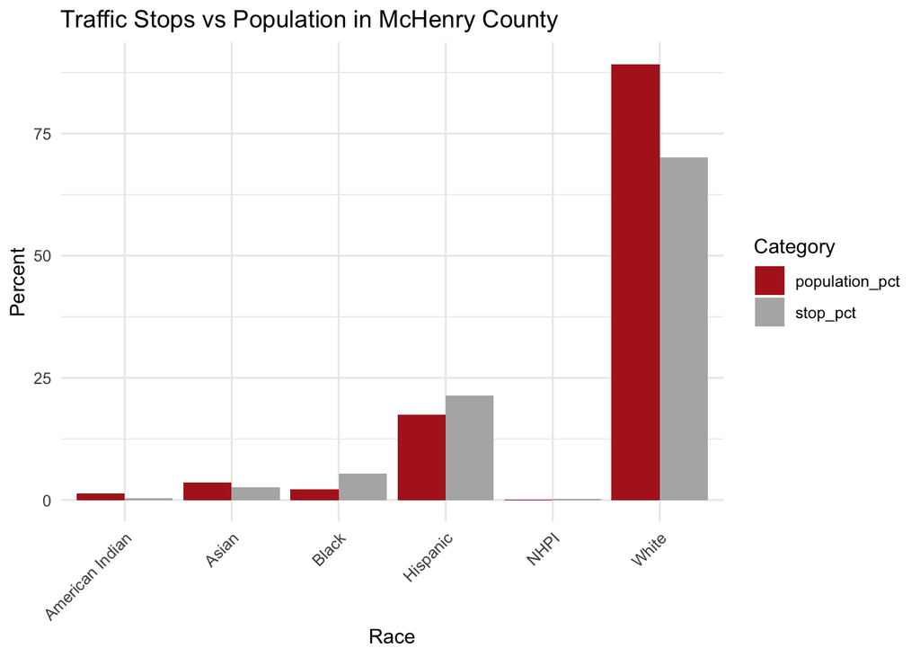

```r
## graphing it
ggplot(mchenry_plot, aes(x = race, y = percent, fill = type)) +
  geom_col(position = "dodge") +
  scale_fill_manual(values = c(
    "stop_pct" = "grey70",
    "population_pct" = "#B22222"
  )) +
  labs(
    title = "Traffic Stops vs Population in McHenry County",
    x = "Race",
    y = "Percent",
    fill = "Category"
  ) +
  theme_minimal() +
  theme(axis.text.x = element_text(angle = 45, hjust = 1))
```

```r
### creating a new data table that has the total number of stops by race and then getting the number of searches that was conducted, creating a rate by taking searches divided by total stops and multiplying by 100 to get a percentage
mchenry_search_rates <- mchenry_law |>
  group_by(race) |>
  summarise(
    total_stops = n(),
    searches = sum(vehicle_search_conducted == "Yes", na.rm = TRUE),
    search_rate = searches/ total_stops * 100
  )


mchenry_search_rates
```

```
## # A tibble: 6 × 4
##   race            total_stops searches search_rate
##   <chr>                 <int>    <int>       <dbl>
## 1 American Indian         253        0       0
## 2 Asian                  1707        9       0.527
## 3 Black                  3468      167       4.82
## 4 Hispanic              13835      372       2.69
## 5 NHPI                    126        4       3.17
## 6 White                 45435      793       1.75
```

- Black drivers have the highest search rates (4.8), followed by NHPI drivers (small numbers, but 3.2) and then Hispanic drivers (2.7) and , and than white drivers (1.7).

[figure not shown]

```r
ggplot(mchenry_search_rates, aes(x = race, y = search_rate)) +
  geom_col(fill = "#B22222") +
  labs(
    title = "Vehicle Search Rate by Race (Kane County)",
    x = "Race",
    y = "Search Rate (%)"
  ) +
  theme_minimal() +
  theme(axis.text.x = element_text(angle = 45, hjust = 1))
```

###### Top 3 McHenry County Law Enforcment Agencies

- CRYSTAL LAKE POLICE 8676
- MCHENRY COUNTY SHERIFF 8232
- MCHENRY POLICE 6666

###### Crystal Lake Police

```r
crystal_lake_pop <- data.frame(
  race = c("White", "Black", "Hispanic", "Asian", "American Indian", "NHPI"),
  population_pct = c(81, 0.6, 13.8, 3.9, 0.3, 0)
)
```

```r
crystal_lake_mchenry <- mchenry_law |>
  filter(agency_name == "CRYSTAL LAKE POLICE") |>
  count(race) |>
  mutate(stop_pct = n/sum(n) * 100)

crystal_lake_mchenry <- crystal_lake_mchenry |>
  left_join(crystal_lake_pop, by ="race")

crystal_lake_mchenry
```

```
##               race     n    stop_pct population_pct
##             <char> <int>       <num>          <num>
## 1: American Indian     7  0.08068234            0.3
## 2:           Asian   217  2.50115260            3.9
## 3:           Black   420  4.84094053            0.6
## 4:        Hispanic  1385 15.96357769           13.8
## 5:            NHPI     4  0.04610420            0.0
## 6:           White  6643 76.56754265           81.0
```

- Black and Hispanic drivers are overrepresented in traffic stops relative to their share of the population, while White and Asian drivers are underrepresented.

```r
## graphing it
crystal_lake_mchenry_plot <- crystal_lake_mchenry %>%
  select(race, stop_pct, population_pct) %>%
  pivot_longer(
    cols = c(stop_pct, population_pct),
    names_to = "type",
    values_to = "percent"
  )
```

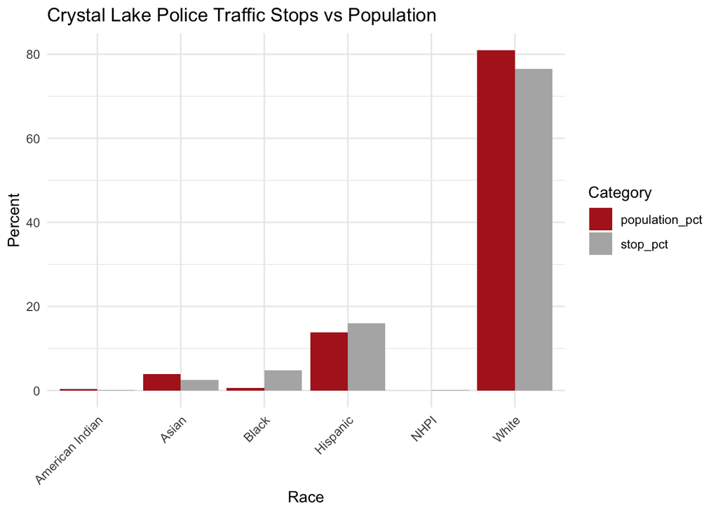

```r
## graphing it
ggplot(crystal_lake_mchenry_plot, aes(x = race, y = percent, fill = type)) +
  geom_col(position = "dodge") +
  scale_fill_manual(values = c(
    "stop_pct" = "grey70",
    "population_pct" = "#B22222"
  )) +
  labs(
    title = "Crystal Lake Police Traffic Stops vs Population",
    x = "Race",
    y = "Percent",
    fill = "Category"
  ) +
  theme_minimal() +
  theme(axis.text.x = element_text(angle = 45, hjust = 1))
```

```r
### creating a new data table that has the total number of stops by race and then getting the number of searches that was conducted, creating a rate by taking searches divided by total stops and multiplying by 100 to get a percentage
crystal_lake_search_rates <- mchenry_law |>
  filter(agency_name == "CRYSTAL LAKE POLICE") |>
  group_by(race) |>
  summarise(
    total_stops = n(),
    searches = sum(vehicle_search_conducted == "Yes", na.rm = TRUE),
    search_rate = searches/ total_stops * 100
  )

crystal_lake_search_rates
```

```
## # A tibble: 6 × 4
##   race            total_stops searches search_rate
##   <chr>                 <int>    <int>       <dbl>
## 1 American Indian           7        0       0
## 2 Asian                   217        1       0.461
## 3 Black                   420       24       5.71
## 4 Hispanic               1385       37       2.67
## 5 NHPI                      4        0       0
## 6 White                  6643       88       1.32
```

- Black drivers have the highest search rates (5.7), followed by Hispanic drivers (2.7) and then white drivers (1.3).

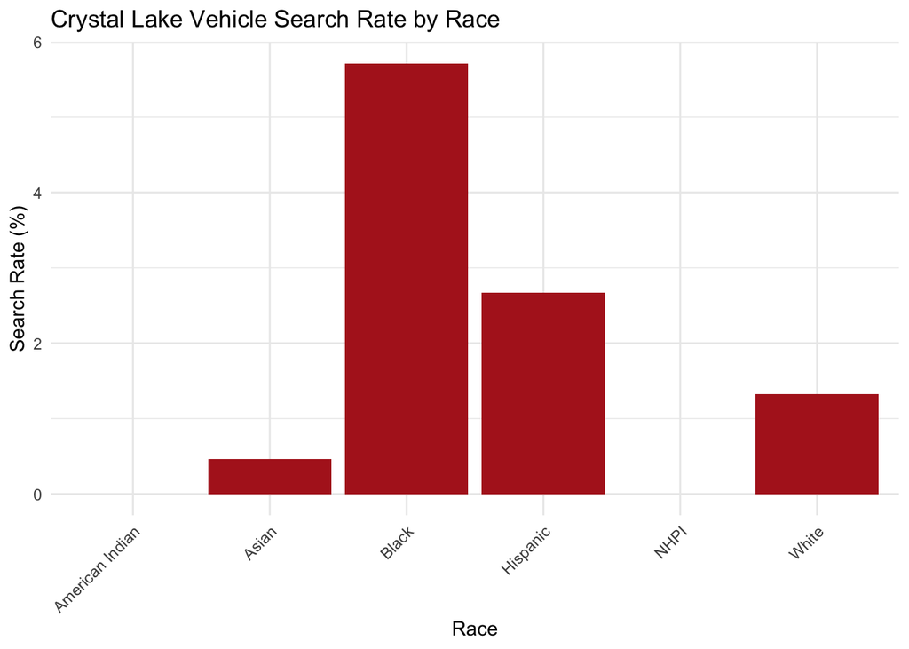

```r
ggplot(crystal_lake_search_rates, aes(x = race, y = search_rate)) +
  geom_col(fill = "#B22222") +
  labs(
    title = "Crystal Lake Vehicle Search Rate by Race",
    x = "Race",
    y = "Search Rate (%)"
  ) +
  theme_minimal() +
  theme(axis.text.x = element_text(angle = 45, hjust = 1))
```

###### McHenry County Sheriff

```r
mchenry_pop <- data.frame(
  race = c("White", "Black", "Hispanic", "Asian", "American Indian", "NHPI"),
  population_pct = c(89.2, 2.2, 17.4, 3.6, 1.4, 0.1)
)
```

```r
mchenry_county <- mchenry_law |>
  filter(agency_name == "MCHENRY COUNTY SHERIFF") |>
  count(race) |>
  mutate(stop_pct = n/sum(n) * 100)

mchenry_county <- mchenry_county |>
  left_join(mchenry_pop, by ="race")

mchenry_county
```

```
##               race     n   stop_pct population_pct
##             <char> <int>      <num>          <num>
## 1: American Indian    24  0.2915452            1.4
## 2:           Asian   174  2.1137026            3.6
## 3:           Black   459  5.5758017            2.2
## 4:        Hispanic  2058 25.0000000           17.4
## 5:            NHPI    15  0.1822157            0.1
## 6:           White  5502 66.8367347           89.2
```

- Black and Hispanic drivers are overrepresented in traffic stops relative to their share of the population, while White and Asian drivers are underrepresented.

```r
## graphing it
mchenry_county_plot <- mchenry_county %>%
  select(race, stop_pct, population_pct) %>%
  pivot_longer(
    cols = c(stop_pct, population_pct),
    names_to = "type",
    values_to = "percent"
  )
```

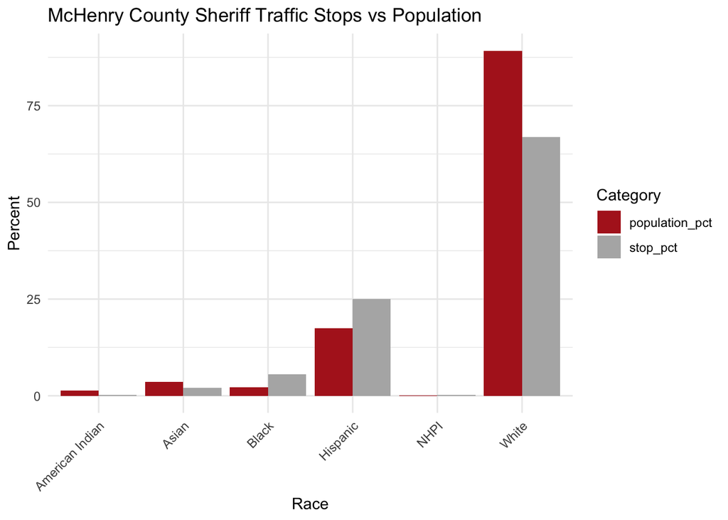

```r
## graphing it
ggplot(mchenry_county_plot, aes(x = race, y = percent, fill = type)) +
  geom_col(position = "dodge") +
  scale_fill_manual(values = c(
    "stop_pct" = "grey70",
    "population_pct" = "#B22222"
  )) +
  labs(
    title = "McHenry County Sheriff Traffic Stops vs Population",
    x = "Race",
    y = "Percent",
    fill = "Category"
  ) +
  theme_minimal() +
  theme(axis.text.x = element_text(angle = 45, hjust = 1))
```

```r
### creating a new data table that has the total number of stops by race and then getting the number of searches that was conducted, creating a rate by taking searches divided by total stops and multiplying by 100 to get a percentage
mchenry_county_search_rates <- mchenry_law |>
  filter(agency_name == "MCHENRY COUNTY SHERIFF") |>
  group_by(race) |>
  summarise(
    total_stops = n(),
    searches = sum(vehicle_search_conducted == "Yes", na.rm = TRUE),
    search_rate = searches/ total_stops * 100
  )

mchenry_county_search_rates
```

```
## # A tibble: 6 × 4
##   race            total_stops searches search_rate
##   <chr>                 <int>    <int>       <dbl>
## 1 American Indian          24        0        0
## 2 Asian                   174        2        1.15
## 3 Black                   459       38        8.28
## 4 Hispanic               2058      100        4.86
## 5 NHPI                     15        1        6.67
## 6 White                  5502      275        5.00
```

- Black drivers have the highest search rates (8.3), followed by NHPI (small numbers (6.7), then white drivers (5) and then Hispanic drivers (4.9).

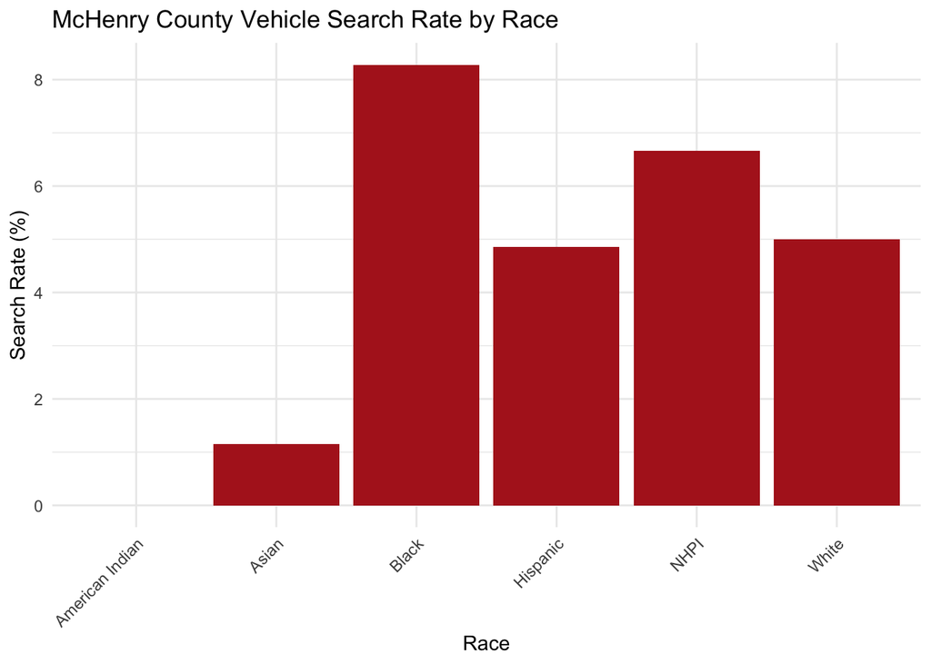

```r
ggplot(mchenry_county_search_rates, aes(x = race, y = search_rate)) +
  geom_col(fill = "#B22222") +
  labs(
    title = "McHenry County Vehicle Search Rate by Race",
    x = "Race",
    y = "Search Rate (%)"
  ) +
  theme_minimal() +
  theme(axis.text.x = element_text(angle = 45, hjust = 1))
```

###### McHenry Police

```r
## bringing in McHenry City data
mchenry_city_pop <- data.frame(
  race = c("White", "Black", "Hispanic", "Asian", "American Indian", "NHPI"),
  population_pct = c(83.7, 0.6, 15.8, 1.7, 0.3, 0.1)
)
```

```r
mchenry_city <- mchenry_law |>
  filter(agency_name == "MCHENRY POLICE") |>
  count(race) |>
  mutate(stop_pct = n/sum(n) * 100)

mchenry_city <- mchenry_city |>
  left_join(mchenry_city_pop, by ="race")

mchenry_city
```

```
##               race     n   stop_pct population_pct
##             <char> <int>      <num>          <num>
## 1: American Indian    11  0.1650165            0.3
## 2:           Asian   130  1.9501950            1.7
## 3:           Black   273  4.0954095            0.6
## 4:        Hispanic  1379 20.6870687           15.8
## 5:            NHPI     5  0.0750075            0.1
## 6:           White  4868 73.0273027           83.7
```

```r
## graphing it
mchenry_city_plot <- mchenry_city %>%
  select(race, stop_pct, population_pct) %>%
  pivot_longer(
    cols = c(stop_pct, population_pct),
    names_to = "type",
    values_to = "percent"
  )
```

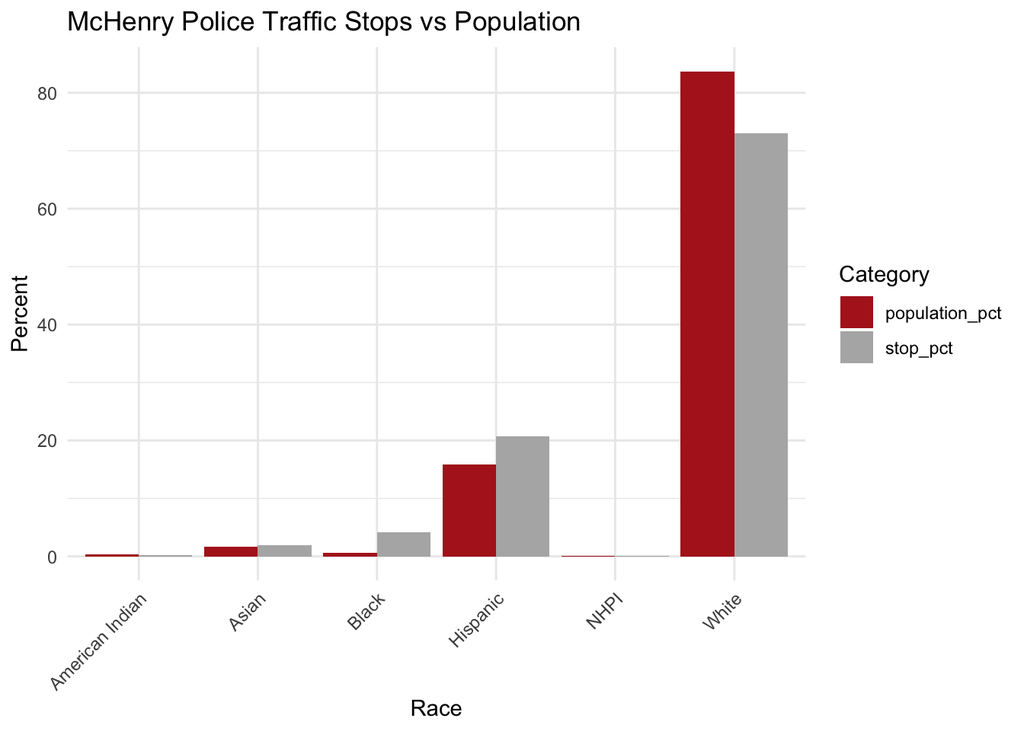

```r
## graphing it
ggplot(mchenry_city_plot, aes(x = race, y = percent, fill = type)) +
  geom_col(position = "dodge") +
  scale_fill_manual(values = c(
    "stop_pct" = "grey70",
    "population_pct" = "#B22222"
  )) +
  labs(
    title = "McHenry Police Traffic Stops vs Population",
    x = "Race",
    y = "Percent",
    fill = "Category"
  ) +
  theme_minimal() +
  theme(axis.text.x = element_text(angle = 45, hjust = 1))
```

```r
### creating a new data table that has the total number of stops by race and then getting the number of searches that was conducted, creating a rate by taking searches divided by total stops and multiplying by 100 to get a percentage
mchenry_city_search_rates <- mchenry_law |>
  filter(agency_name == "MCHENRY POLICE") |>
  group_by(race) |>
  summarise(
    total_stops = n(),
    searches = sum(vehicle_search_conducted == "Yes", na.rm = TRUE),
    search_rate = searches/ total_stops * 100
  )

mchenry_city_search_rates
```

```
## # A tibble: 6 × 4
##   race            total_stops searches search_rate
##   <chr>                 <int>    <int>       <dbl>
## 1 American Indian          11        0       0
## 2 Asian                   130        0       0
## 3 Black                   273        5       1.83
## 4 Hispanic               1379       10       0.725
## 5 NHPI                      5        1      20
## 6 White                  4868       39       0.801
```

- NHPI has the highest search rate (small numbers (20), followed by Black drivers have the highest search rates (1.8), then white drivers (0.8) and then Hispanic drivers (0.7).

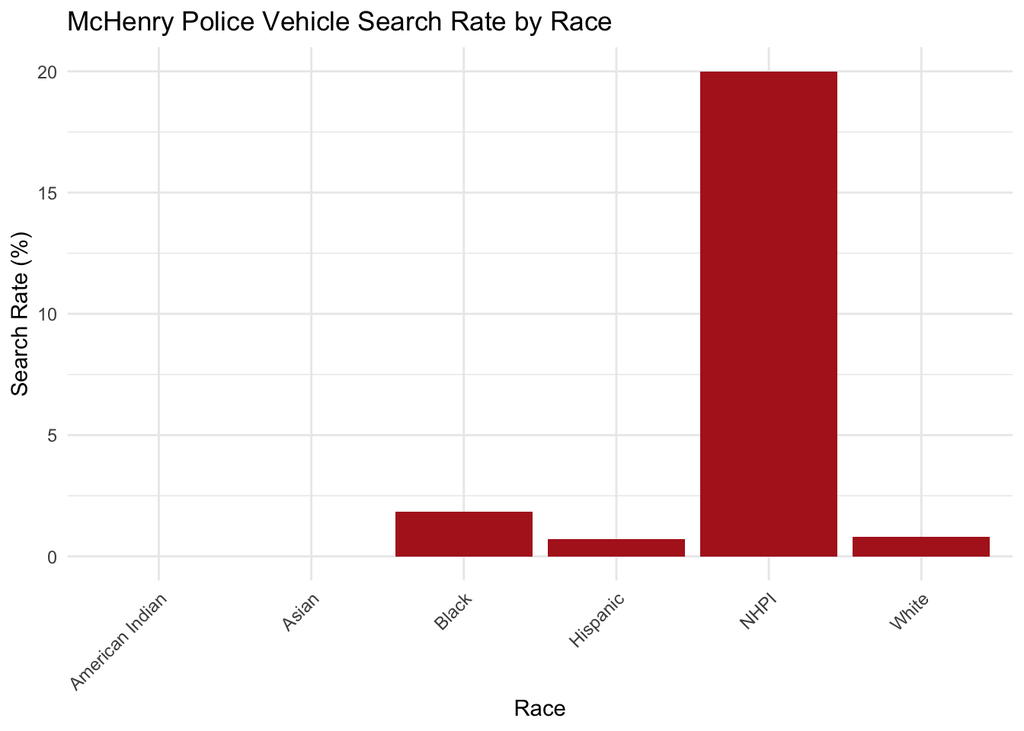

```r
ggplot(mchenry_city_search_rates, aes(x = race, y = search_rate)) +
  geom_col(fill = "#B22222") +
  labs(
    title = "McHenry Police Vehicle Search Rate by Race",
    x = "Race",
    y = "Search Rate (%)"
  ) +
  theme_minimal() +
  theme(axis.text.x = element_text(angle = 45, hjust = 1))
```